# Panek / TGF

## 4.15 rs2798631

```
Number of samples typed: 652 (100%)

Allele Frequency: (2 alleles)
  Count Proportion
A   729       0.56
G   575       0.44


Genotype Frequency:
    Count Proportion
A/A   203       0.31
A/G   323       0.50
G/G   126       0.19

Heterozygosity (Hu)  = 0.4934048
Poly. Inf. Content   = 0.3714889



Call:
diseq.genotype(x = g)

Disequlibrium for each allele pair (D)


             A          G
  A            0.00118618
  G 0.00118618

Disequlibrium for each allele pair (D')


              A           G
  A             0.004811833
  G 0.004811833

Correlation coefficient for each allele pair (r)


               A            G
```

[output cut: 17 more lines]

```

Overall Values

  D  :  0.00118618
  D' :  0.004811833
  r  :  -0.004811833
  R^2:  2.315373e-05



    Pearson's Chi-squared test with simulated p-value (based on 10000
    replicates)

data:  tab
X-squared = 0.015096, df = NA, p-value = 0.8689
```

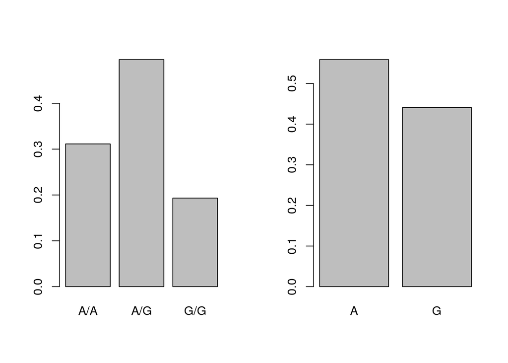

## 4.16 rs10863399

```
Number of samples typed: 652 (100%)

Allele Frequency: (2 alleles)
  Count Proportion
A  1089       0.84
C   215       0.16


Genotype Frequency:
    Count Proportion
A/A   452       0.69
A/C   185       0.28
C/C    15       0.02

Heterozygosity (Hu)  = 0.2755969
Poly. Inf. Content   = 0.237467



Call:
diseq.genotype(x = g)

Disequlibrium for each allele pair (D)


              A           C
  A             0.004178389
  C 0.004178389

Disequlibrium for each allele pair (D')


             A          C
  A            0.03034574
  C 0.03034574

Correlation coefficient for each allele pair (r)


              A           C
```

[output cut: 17 more lines]

```

Overall Values

  D  :  0.004178389
  D' :  0.03034574
  r  :  -0.03034574
  R^2:  0.000920864



    Pearson's Chi-squared test with simulated p-value (based on 10000
    replicates)

data:  tab
X-squared = 0.6004, df = NA, p-value = 0.3906
```

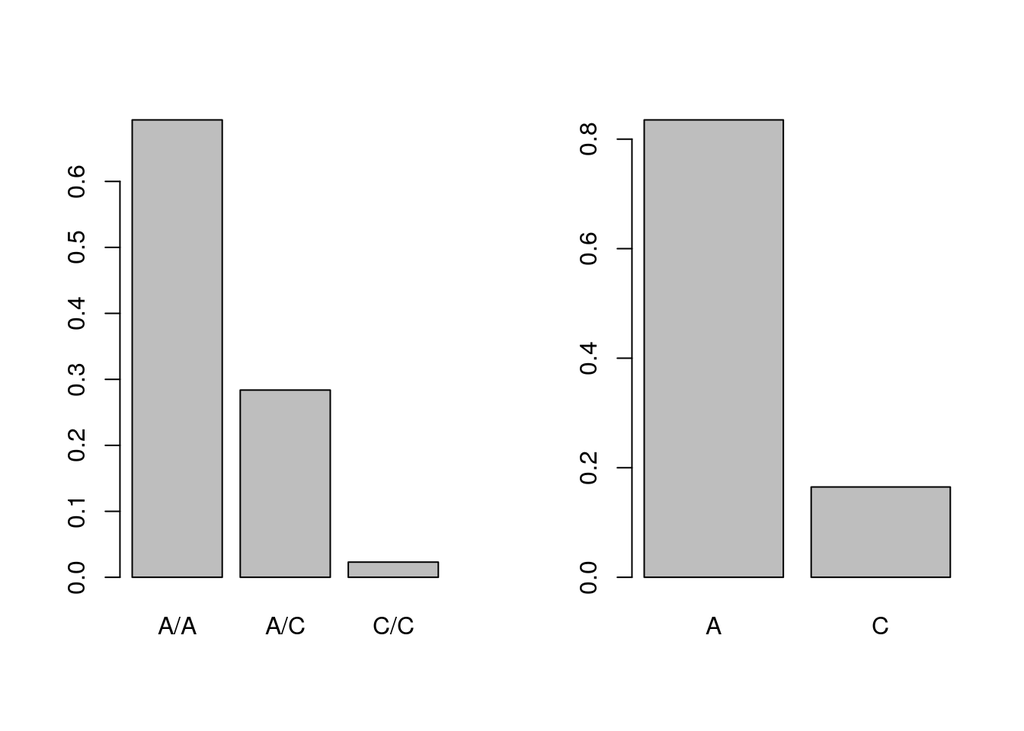

## 4.17 rs4903359

```
Number of samples typed: 652 (100%)

Allele Frequency: (2 alleles)
  Count Proportion
A   935       0.72
G   369       0.28


Genotype Frequency:
    Count Proportion
A/A   310       0.48
A/G   315       0.48
G/G    27       0.04

Heterozygosity (Hu)  = 0.4061121
Poly. Inf. Content   = 0.3234636



Call:
diseq.genotype(x = g)

Disequlibrium for each allele pair (D)


             A          G
  A            0.03866407
  G 0.03866407

Disequlibrium for each allele pair (D')


            A         G
  A           0.1905569
  G 0.1905569

Correlation coefficient for each allele pair (r)


             A          G
```

[output cut: 17 more lines]

```

Overall Values

  D  :  0.03866407
  D' :  0.1905569
  r  :  -0.1905569
  R^2:  0.03631194



    Pearson's Chi-squared test with simulated p-value (based on 10000
    replicates)

data:  tab
X-squared = 23.675, df = NA, p-value = 9.999e-05
```

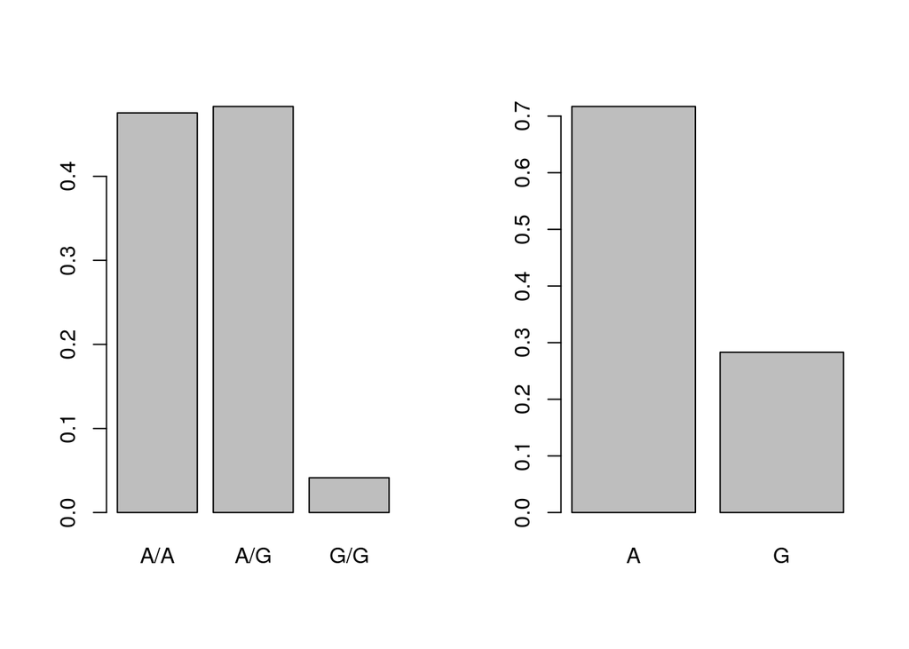

## 4.18 rs3917187

```
Number of samples typed: 652 (100%)

Allele Frequency: (2 alleles)
  Count Proportion
C  1005       0.77
T   299       0.23


Genotype Frequency:
    Count Proportion
C/C   390       0.60
C/T   225       0.35
T/T    37       0.06

Heterozygosity (Hu)  = 0.3537083
Poly. Inf. Content   = 0.2909782



Call:
diseq.genotype(x = g)

Disequlibrium for each allele pair (D)


               C            T
  C              -0.004172508
  T -0.004172508

Disequlibrium for each allele pair (D')


              C           T
  C             -0.07936153
  T -0.07936153

Correlation coefficient for each allele pair (r)


             C          T
```

[output cut: 17 more lines]

```

Overall Values

  D  :  -0.004172508
  D' :  -0.07936153
  r  :  0.02361104
  R^2:  0.0005574813



    Pearson's Chi-squared test with simulated p-value (based on 10000
    replicates)

data:  tab
X-squared = 0.36348, df = NA, p-value = 0.5842
```

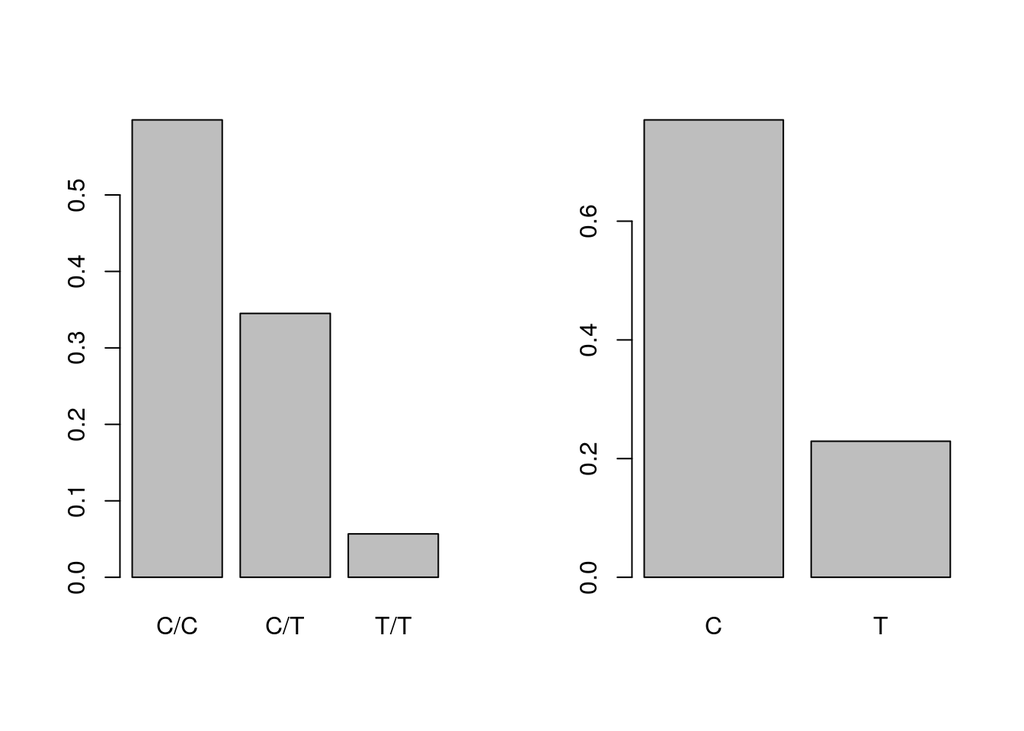

## 4.19 rs2284792

```
Number of samples typed: 652 (100%)

Allele Frequency: (2 alleles)
  Count Proportion
A   993       0.76
G   311       0.24


Genotype Frequency:
    Count Proportion
A/A   378       0.58
A/G   237       0.36
G/G    37       0.06

Heterozygosity (Hu)  = 0.3635111
Poly. Inf. Content   = 0.2972634



Call:
diseq.genotype(x = g)

Disequlibrium for each allele pair (D)


               A            G
  A              0.0001323206
  G 0.0001323206

Disequlibrium for each allele pair (D')


               A            G
  A              0.0007285727
  G 0.0007285727

Correlation coefficient for each allele pair (r)


                A             G
```

[output cut: 17 more lines]

```

Overall Values

  D  :  0.0001323206
  D' :  0.0007285727
  r  :  -0.0007285727
  R^2:  5.308181e-07



    Pearson's Chi-squared test with simulated p-value (based on 10000
    replicates)

data:  tab
X-squared = 0.00034609, df = NA, p-value = 1
```

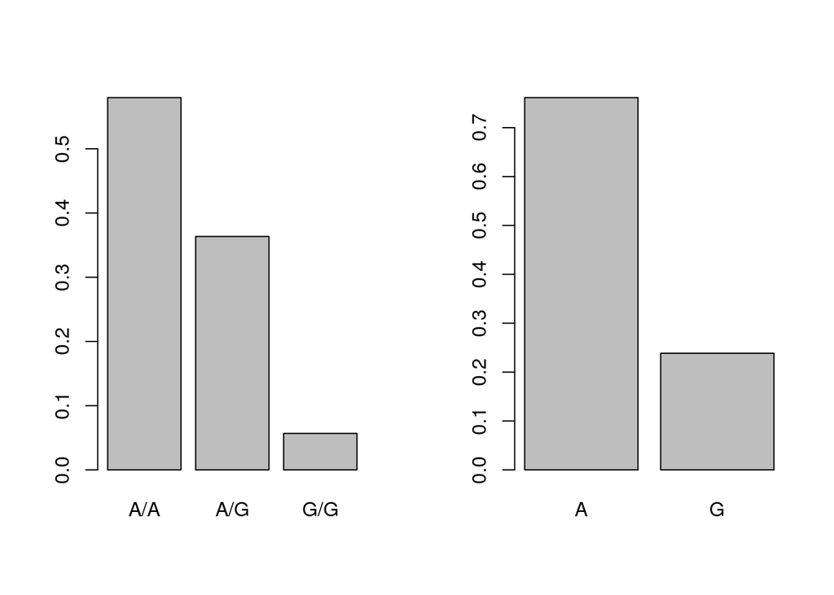

## 4.20 rs2268626

```
Number of samples typed: 652 (100%)

Allele Frequency: (2 alleles)
  Count Proportion
T  1062       0.81
C   242       0.19


Genotype Frequency:
    Count Proportion
T/T   434       0.67
T/C   194       0.30
C/C    24       0.04

Heterozygosity (Hu)  = 0.3025157
Poly. Inf. Content   = 0.256596



Call:
diseq.genotype(x = g)

Disequlibrium for each allele pair (D)


               T            C
  T              -0.002368832
  C -0.002368832

Disequlibrium for each allele pair (D')


              T           C
  T             -0.06877945
  C -0.06877945

Correlation coefficient for each allele pair (r)


             T          C
```

[output cut: 17 more lines]

```

Overall Values

  D  :  -0.002368832
  D' :  -0.06877945
  r  :  0.01567291
  R^2:  0.00024564



    Pearson's Chi-squared test with simulated p-value (based on 10000
    replicates)

data:  tab
X-squared = 0.16016, df = NA, p-value = 0.6967
```

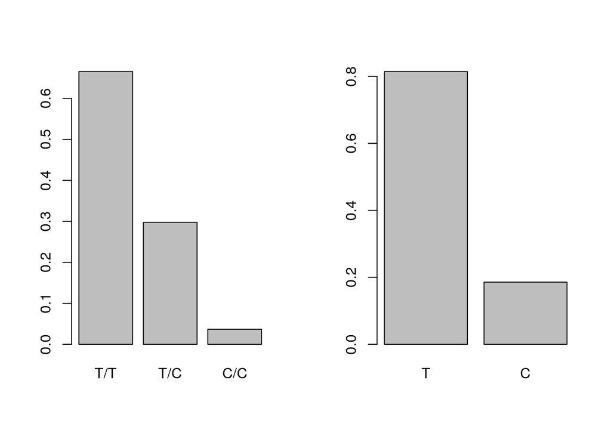

```r
dane_complete_genetics = makeGenotypes(dane_complete)
```

# 5 Linkage disequilibrium

Linkage disequilibrium (LD) is the non-random association of marker alleles and can arise from marker proximity or from selection bias. LD is a concept of statistical correlation between alleles segregating at two or more loci.2 Conversely, linkage equilibrium refers to the state where the alleles at a particular locus are independently distributed with respect to the alleles at an alternative locus.

```r
temp = LD(dane_complete_genetics)
saveRDS(temp,"Wyniki/LD.RDS")
```

P-values:

```r
kable(temp$`P-value`, "html") %>%
    kable_styling() %>%
    scroll_box(width = "100%", height = "400px")
```

|  | rs8109627 | rs8179181 | rs4803455 | rs1800469 | rs10495098 | rs17047703 | rs17558745 | rs2799085 | rs2009112 | rs10482751 | rs2027567 | rs10779329 | rs2796821 | rs2796822 | rs2798631 | rs10863399 | rs4903359 | rs3917187 | rs2284792 | rs2268626 |
| --- | --- | --- | --- | --- | --- | --- | --- | --- | --- | --- | --- | --- | --- | --- | --- | --- | --- | --- | --- | --- |
| rs8109627 | NA | 0 | 3.5e-06 | 0.5438126 | 0.9824129 | 0.0228949 | 0.2918791 | 0.1745399 | 0.0251629 | 0.0444362 | 0.1152914 | 0.0072354 | 0.7785322 | 0.8505765 | 0.4787261 | 0.0034317 | 0.3465291 | 0.2684952 | 0.7627255 | 0.4082493 |
| rs8179181 | NA | NA | 0.0e+00 | 0.0000006 | 0.5113259 | 0.9377644 | 0.7580184 | 0.0372252 | 0.4144264 | 0.0868893 | 0.0052338 | 0.0008221 | 0.2630502 | 0.0262169 | 0.0042633 | 0.9099962 | 0.0376310 | 0.0162584 | 0.0915376 | 0.0416813 |
| rs4803455 | NA | NA | NA | 0.0000000 | 0.9590290 | 0.8730487 | 0.5178372 | 0.9480036 | 0.6745485 | 0.2783669 | 0.9434203 | 0.9059792 | 0.7265205 | 0.4109703 | 0.0318262 | 0.2820070 | 0.0588444 | 0.4022675 | 0.4716287 | 0.0634198 |
| rs1800469 | NA | NA | NA | NA | 0.5834973 | 0.8434820 | 0.7891695 | 0.1029112 | 0.6982087 | 0.0509726 | 0.0142035 | 0.0424575 | 0.1258623 | 0.3743172 | 0.0340489 | 0.0015945 | 0.0017498 | 0.5157509 | 0.3881720 | 0.0665781 |
| rs10495098 | NA | NA | NA | NA | NA | 0.0000000 | 0.0000000 | 0.0000076 | 0.0000000 | 0.0000000 | 0.0000000 | 0.0000007 | 0.2611442 | 0.0000676 | 0.0000139 | 0.7764197 | 0.5243175 | 0.0315585 | 0.0248166 | 0.1793980 |
| rs17047703 | NA | NA | NA | NA | NA | NA | 0.0000000 | 0.0000000 | 0.3398540 | 0.1339944 | 0.7270606 | 0.5282015 | 0.0007793 | 0.3040674 | 0.0177641 | 0.1447386 | 0.0069650 | 0.0040472 | 0.0120056 | 0.0899450 |
| rs17558745 | NA | NA | NA | NA | NA | NA | NA | 0.0000000 | 0.0016404 | 0.0346846 | 0.5895761 | 0.5788012 | 0.0000000 | 0.0024208 | 0.0000071 | 0.0003339 | 0.0030974 | 0.0050535 | 0.0295661 | 0.1754613 |
| rs2799085 | NA | NA | NA | NA | NA | NA | NA | NA | 0.0000000 | 0.0000000 | 0.0000000 | 0.0000003 | 0.0000000 | 0.0000000 | 0.0000000 | 0.0000010 | 0.0235247 | 0.0411581 | 0.1451022 | 0.8238617 |
| rs2009112 | NA | NA | NA | NA | NA | NA | NA | NA | NA | 0.0000000 | 0.0000000 | 0.0000000 | 0.0000000 | 0.0000000 | 0.0000000 | 0.1076499 | 0.1682681 | 0.0257022 | 0.2108531 | 0.5438604 |
| rs10482751 | NA | NA | NA | NA | NA | NA | NA | NA | NA | NA | 0.0000000 | 0.0000000 | 0.0000914 | 0.0000000 | 0.0000000 | 0.0159977 | 0.0157715 | 0.1060442 | 0.5795538 | 0.7457161 |
| rs2027567 | NA | NA | NA | NA | NA | NA | NA | NA | NA | NA | NA | 0.0000000 | 0.0219515 | 0.0000000 | 0.0000003 | 0.1138678 | 0.0624619 | 0.1886844 | 0.6770829 | 0.5702300 |
| rs10779329 | NA | NA | NA | NA | NA | NA | NA | NA | NA | NA | NA | NA | 0.0206991 | 0.0000000 | 0.0000000 | 0.0000000 | 0.1268756 | 0.4363839 | 0.1426596 | 0.6866258 |
| rs2796821 | NA | NA | NA | NA | NA | NA | NA | NA | NA | NA | NA | NA | NA | 0.0000000 | 0.0000000 | 0.0000000 | 0.0438794 | 0.7758619 | 0.9411671 | 0.3758212 |
| rs2796822 | NA | NA | NA | NA | NA | NA | NA | NA | NA | NA | NA | NA | NA | NA | 0.0000000 | 0.0000000 | 0.0386784 | 0.2817209 | 0.5957664 | 0.8829379 |
| rs2798631 | NA | NA | NA | NA | NA | NA | NA | NA | NA | NA | NA | NA | NA | NA | NA | 0.0000000 | 0.0174192 | 0.1803341 | 0.2549766 | 0.5257443 |
| rs10863399 | NA | NA | NA | NA | NA | NA | NA | NA | NA | NA | NA | NA | NA | NA | NA | NA | 0.0000730 | 0.0728053 | 0.3192482 | 0.8228365 |
| rs4903359 | NA | NA | NA | NA | NA | NA | NA | NA | NA | NA | NA | NA | NA | NA | NA | NA | NA | 0.0000000 | 0.0000000 | 0.0000000 |
| rs3917187 | NA | NA | NA | NA | NA | NA | NA | NA | NA | NA | NA | NA | NA | NA | NA | NA | NA | NA | 0.0000000 | 0.0000000 |
| rs2284792 | NA | NA | NA | NA | NA | NA | NA | NA | NA | NA | NA | NA | NA | NA | NA | NA | NA | NA | NA | 0.0000000 |
| rs2268626 | NA | NA | NA | NA | NA | NA | NA | NA | NA | NA | NA | NA | NA | NA | NA | NA | NA | NA | NA | NA |

R-squared:

```r
kable(temp$`R^2`, "html") %>%
    kable_styling() %>%
    scroll_box(width = "100%", height = "400px")
```

|  | rs8109627 | rs8179181 | rs4803455 | rs1800469 | rs10495098 | rs17047703 | rs17558745 | rs2799085 | rs2009112 | rs10482751 | rs2027567 | rs10779329 | rs2796821 | rs2796822 | rs2798631 | rs10863399 | rs4903359 | rs3917187 | rs2284792 | rs2268626 |
| --- | --- | --- | --- | --- | --- | --- | --- | --- | --- | --- | --- | --- | --- | --- | --- | --- | --- | --- | --- | --- |
| rs8109627 | NA | 0.1111115 | 0.0164888 | 0.0002826 | 0.0000004 | 0.0039697 | 0.0008519 | 0.0014137 | 0.0038441 | 0.0030981 | 0.0019020 | 0.0055319 | 0.0000607 | 0.0000272 | 0.0003848 | 0.0065663 | 0.0006795 | 0.0009390 | 0.0000699 | 0.0005245 |
| rs8179181 | NA | NA | 0.0763975 | 0.0191699 | 0.0003308 | 0.0000047 | 0.0000728 | 0.0033283 | 0.0005108 | 0.0022478 | 0.0059792 | 0.0085818 | 0.0009606 | 0.0037896 | 0.0062639 | 0.0000098 | 0.0033141 | 0.0044285 | 0.0021834 | 0.0031811 |
| rs4803455 | NA | NA | NA | 0.3707324 | 0.0000020 | 0.0000196 | 0.0003207 | 0.0000033 | 0.0001352 | 0.0009011 | 0.0000039 | 0.0000107 | 0.0000938 | 0.0005184 | 0.0035336 | 0.0008876 | 0.0027375 | 0.0005380 | 0.0003974 | 0.0026423 |
| rs1800469 | NA | NA | NA | NA | 0.0002305 | 0.0000299 | 0.0000548 | 0.0020398 | 0.0001153 | 0.0029211 | 0.0046109 | 0.0031571 | 0.0017966 | 0.0006053 | 0.0034450 | 0.0076427 | 0.0075116 | 0.0003239 | 0.0005711 | 0.0025809 |
| rs10495098 | NA | NA | NA | NA | NA | 0.3251470 | 0.1619651 | 0.0153734 | 0.0658194 | 0.0648896 | 0.0334981 | 0.0188486 | 0.0009683 | 0.0121755 | 0.0144833 | 0.0000618 | 0.0003109 | 0.0035447 | 0.0038625 | 0.0013824 |
| rs17047703 | NA | NA | NA | NA | NA | NA | 0.6793282 | 0.0389096 | 0.0006986 | 0.0017221 | 0.0000934 | 0.0003051 | 0.0086579 | 0.0008100 | 0.0043092 | 0.0016310 | 0.0055843 | 0.0063363 | 0.0048390 | 0.0022050 |
| rs17558745 | NA | NA | NA | NA | NA | NA | NA | 0.0377211 | 0.0076026 | 0.0034207 | 0.0002232 | 0.0002363 | 0.0276238 | 0.0070548 | 0.0154575 | 0.0098697 | 0.0067095 | 0.0060278 | 0.0036306 | 0.0014077 |
| rs2799085 | NA | NA | NA | NA | NA | NA | NA | NA | 0.3848356 | 0.4640473 | 0.4035437 | 0.0199871 | 0.0458594 | 0.0545796 | 0.0453320 | 0.0183513 | 0.0039335 | 0.0031975 | 0.0016281 | 0.0000380 |
| rs2009112 | NA | NA | NA | NA | NA | NA | NA | NA | NA | 0.4084427 | 0.2713089 | 0.0812756 | 0.0271939 | 0.0528080 | 0.0364766 | 0.0019850 | 0.0014558 | 0.0038159 | 0.0012006 | 0.0002825 |
| rs10482751 | NA | NA | NA | NA | NA | NA | NA | NA | NA | NA | 0.6907180 | 0.0997255 | 0.0117382 | 0.0560467 | 0.0280962 | 0.0044502 | 0.0044695 | 0.0020032 | 0.0002354 | 0.0000806 |
| rs2027567 | NA | NA | NA | NA | NA | NA | NA | NA | NA | NA | NA | 0.0485099 | 0.0040258 | 0.0356252 | 0.0201414 | 0.0019169 | 0.0026616 | 0.0013250 | 0.0001330 | 0.0002472 |
| rs10779329 | NA | NA | NA | NA | NA | NA | NA | NA | NA | NA | NA | NA | 0.0041043 | 0.3435156 | 0.2173620 | 0.0370621 | 0.0017871 | 0.0004645 | 0.0016480 | 0.0001248 |
| rs2796821 | NA | NA | NA | NA | NA | NA | NA | NA | NA | NA | NA | NA | NA | 0.4378890 | 0.2902367 | 0.6596450 | 0.0031144 | 0.0000622 | 0.0000042 | 0.0006015 |
| rs2796822 | NA | NA | NA | NA | NA | NA | NA | NA | NA | NA | NA | NA | NA | NA | 0.6912019 | 0.2804380 | 0.0032783 | 0.0008886 | 0.0002158 | 0.0000166 |
| rs2798631 | NA | NA | NA | NA | NA | NA | NA | NA | NA | NA | NA | NA | NA | NA | NA | 0.2498998 | 0.0043356 | 0.0013764 | 0.0009937 | 0.0003088 |
| rs10863399 | NA | NA | NA | NA | NA | NA | NA | NA | NA | NA | NA | NA | NA | NA | NA | NA | 0.0120635 | 0.0024683 | 0.0007608 | 0.0000384 |
| rs4903359 | NA | NA | NA | NA | NA | NA | NA | NA | NA | NA | NA | NA | NA | NA | NA | NA | NA | 0.5881245 | 0.5187892 | 0.3629364 |
| rs3917187 | NA | NA | NA | NA | NA | NA | NA | NA | NA | NA | NA | NA | NA | NA | NA | NA | NA | NA | 0.8426062 | 0.5935426 |
| rs2284792 | NA | NA | NA | NA | NA | NA | NA | NA | NA | NA | NA | NA | NA | NA | NA | NA | NA | NA | NA | 0.7109996 |
| rs2268626 | NA | NA | NA | NA | NA | NA | NA | NA | NA | NA | NA | NA | NA | NA | NA | NA | NA | NA | NA | NA |

# 6 Ill vs. healthy

## 6.1 Univariate analysis

We perform logistic regression including a particular SNP (G) and a set of covariates (X) that could include environmental covariates or/and other genetic variables. Included are three analysis options: (i) Unconstrained maximum-likelihood: (UML) This method is equivalent to prospective logistic regression analysis and corresponds to maximum-likelihood analysis of case-control data allowing the joint distribution of all the factors (the SNP of interest and all other covariates) of the model to be completely unrestricted (non-parametric) (ii) Constrained maximum-likelihood: This method performs maximum-likelihood analysis of case-control data under the assumption of HWE and indepenence between the SNP and other factors of the model.The analysis allows the assumptions of HWE and independence to be valid only conditional on certain stratification variables (S), such as self reported ethnicity or principal compoenets of population stratification. (iii) Empirical-Bayes: This method uses an empirical-Bayes type “shrinkage estimation” technique to trade-off bias and variance between the constrained and unconstrained maximum-likelihood estimators.

````r
library(CGEN)
clinical_ill = as.numeric(ifelse(clinical$Zdrowi...0...Chorzy...1. == 1, 1, 0)) # Astma - 1, Healthy - 0
temp_gen = dane_complete_genetics
for(i in 1:length(colnames(temp_gen))) {
  temp_gen[,i] = as.numeric(temp_gen[,i]) - 1 # bo wymaga 0-1-2
}
temp = cbind(clinical_ill, temp_gen)
temp = temp[complete.cases(temp),]

wyniki = data.frame(SNP = vector(), OR = vector(), Lower = vector(), Upper = vector(), P = vector())

for (i in 1:length(colnames(temp_gen))) {
  temp2 = CGEN::snp.logistic(temp, "clinical_ill",colnames(temp_gen)[i])
  cat("\n\n```")
  print(CGEN::getSummary(temp2))
  cat("```\n\n")
  #OR:
  OR = exp(summary(temp2)$UML[2,1])
  Lower = exp(summary(temp2)$UML[2,1] - 1.96*summary(temp2)$UML[2,2])
  Upper = exp(summary(temp2)$UML[2,1] + 1.96*summary(temp2)$UML[2,2])
  P = summary(temp2)$UML[2,4]

  cat(paste0("\n\nFor ",colnames(temp_gen)[i], ": OR=", OR, ", 95%CI: ",Lower, "-", Upper, " (p=", P, ")\n\n" ))
  wyniki[i,] = c(colnames(temp_gen)[i], OR, Lower, Upper, P)
}
````

```
              Estimate Std.Error     Z.value    Pvalue
Intercept  0.288357802 0.2260553  1.27560724 0.2020944
rs8109627 -0.003582208 0.1372884 -0.02609257 0.9791835

$CML
              Estimate Std.Error     Z.value    Pvalue
Intercept  0.288365136 0.2261811  1.27493006 0.2023340
rs8109627 -0.003586953 0.1373764 -0.02611039 0.9791693

$EB
              Estimate Std.Error     Z.value    Pvalue
Intercept  0.288365136 0.2261811  1.27493006 0.2023340
rs8109627 -0.003586953 0.1373764 -0.02611039 0.9791693
```

For rs8109627: OR=0.996424200709197, 95%CI: 0.761345905652597-1.30408685511734 (p=0.979183501007199)

```
            Estimate Std.Error   Z.value    Pvalue
Intercept 0.25695438 0.2072683 1.2397184 0.2150796
rs8179181 0.01763761 0.1295952 0.1360977 0.8917440

$CML
            Estimate Std.Error   Z.value    Pvalue
Intercept 0.25620271 0.2097864 1.2212552 0.2219894
rs8179181 0.01814933 0.1314608 0.1380589 0.8901939

$EB
            Estimate Std.Error   Z.value    Pvalue
Intercept 0.25620272 0.2097863 1.2212555 0.2219893
rs8179181 0.01814932 0.1314608 0.1380588 0.8901939
```

For rs8179181: OR=1.01779407223813, 95%CI: 0.789489300243871-1.31212009227115 (p=0.891744038241207)

```
            Estimate Std.Error   Z.value     Pvalue
Intercept 0.24600316 0.1434248 1.7152069 0.08630731
rs4803455 0.03583972 0.1144696 0.3130936 0.75420953

$CML
            Estimate Std.Error   Z.value     Pvalue
Intercept 0.24488006 0.1448785 1.6902448 0.09098112
rs4803455 0.03693173 0.1161917 0.3178519 0.75059730

$EB
            Estimate Std.Error   Z.value     Pvalue
Intercept 0.24488013 0.1448784 1.6902457 0.09098096
rs4803455 0.03693164 0.1161916 0.3178512 0.75059783
```

For rs4803455: OR=1.03648969956933, 95%CI: 0.828183294520511-1.29718976997153 (p=0.754209527949284)

```
            Estimate Std.Error    Z.value     Pvalue
Intercept  0.4652960 0.2510926  1.8530849 0.06387019
rs1800469 -0.1265265 0.1643116 -0.7700404 0.44127593

$CML
             Estimate Std.Error    Z.value     Pvalue
Intercept  0.39615262 0.2045144  1.9370401 0.05274044
rs1800469 -0.07856533 0.1296679 -0.6058966 0.54458341

$EB
             Estimate Std.Error    Z.value     Pvalue
Intercept  0.40102612 0.2064918  1.9420919 0.05212597
rs1800469 -0.08233084 0.1315224 -0.6259832 0.53132593
```

For rs1800469: OR=0.881150768444866, 95%CI: 0.638536027846405-1.21594811078967 (p=0.441275928360062)

```
            Estimate Std.Error   Z.value    Pvalue
Intercept  0.1909341 0.1322306 1.4439474 0.1487538
rs10495098 0.1045778 0.1183373 0.8837263 0.3768440

$CML
            Estimate Std.Error   Z.value    Pvalue
Intercept  0.1927386 0.1313778 1.4670563 0.1423607
rs10495098 0.1025251 0.1170933 0.8755847 0.3812558

$EB
            Estimate Std.Error  Z.value    Pvalue
Intercept  0.1927383 0.1313772 1.467060 0.1423597
rs10495098 0.1025257 0.1170914 0.875604 0.3812453
```

For rs10495098: OR=1.11024179474478, 95%CI: 0.880413693731521-1.40006550508515 (p=0.376843984635475)

```
             Estimate Std.Error   Z.value    Pvalue
Intercept  0.13088353 0.2400245 0.5452923 0.5855525
rs17047703 0.09610487 0.1427877 0.6730610 0.5009085

$CML
             Estimate Std.Error   Z.value    Pvalue
Intercept  0.13130960 0.2396468 0.5479298 0.5837401
rs17047703 0.09583503 0.1425332 0.6723699 0.5013482

$EB
             Estimate Std.Error   Z.value    Pvalue
Intercept  0.13130960 0.2396468 0.5479298 0.5837401
rs17047703 0.09583503 0.1425332 0.6723700 0.5013482
```

For rs17047703: OR=1.10087450173052, 95%CI: 0.832136226820554-1.45640176391667 (p=0.500908474446554)

```
             Estimate Std.Error   Z.value    Pvalue
Intercept  0.26213711 0.1061721 2.4689822 0.0135498
rs17558745 0.03989468 0.1298032 0.3073474 0.7585790

$CML
             Estimate Std.Error   Z.value     Pvalue
Intercept  0.26125073 0.1070758 2.4398670 0.01469267
rs17558745 0.04160076 0.1325360 0.3138828 0.75361007

$EB
             Estimate Std.Error   Z.value     Pvalue
Intercept  0.26125080 0.1070759 2.4398657 0.01469272
rs17558745 0.04160047 0.1325367 0.3138789 0.75361301
```

For rs17558745: OR=1.04070116574778, 95%CI: 0.806928969866414-1.34219857860363 (p=0.758578955165181)

```
            Estimate Std.Error   Z.value    Pvalue
Intercept 0.05340463 0.1632105 0.3272132 0.7435066
rs2799085 0.18984938 0.1171823 1.6201203 0.1052064

$CML
            Estimate Std.Error   Z.value     Pvalue
Intercept 0.04629928 0.1648276 0.2808952 0.77879077
rs2799085 0.19572957 0.1187390 1.6484024 0.09927012

$EB
            Estimate Std.Error   Z.value     Pvalue
Intercept 0.04631272 0.1648312 0.2809706 0.77873292
rs2799085 0.19571480 0.1187495 1.6481318 0.09932563
```

For rs2799085: OR=1.2090674714812, 95%CI: 0.960954823667129-1.52124128480395 (p=0.105206445641997)

```
           Estimate Std.Error  Z.value    Pvalue
Intercept 0.1660554 0.1339666 1.239529 0.2151498
rs2009112 0.1252547 0.1139978 1.098747 0.2718786

$CML
           Estimate Std.Error  Z.value    Pvalue
Intercept 0.1606252 0.1358153 1.182674 0.2369384
rs2009112 0.1310774 0.1165081 1.125050 0.2605679

$EB
           Estimate Std.Error  Z.value    Pvalue
Intercept 0.1606341 0.1358135 1.182755 0.2369062
rs2009112 0.1310623 0.1165023 1.124976 0.2605992
```

For rs2009112: OR=1.13343710153391, 95%CI: 0.906484804473152-1.41721036777914 (p=0.271878644506493)

```
              Estimate Std.Error    Z.value      Pvalue
Intercept   0.33858771 0.1149361  2.9458776 0.003220398
rs10482751 -0.08522824 0.1224620 -0.6959567 0.486455926

$CML
              Estimate Std.Error    Z.value      Pvalue
Intercept   0.33976539 0.1155079  2.9414910 0.003266364
rs10482751 -0.08702799 0.1237020 -0.7035292 0.481726005

$EB
             Estimate Std.Error    Z.value      Pvalue
Intercept   0.3397653 0.1155082  2.9414808 0.003266471
rs10482751 -0.0870276 0.1237032 -0.7035195 0.481732043
```

For rs10482751: OR=0.918302669918459, 95%CI: 0.722344064223597-1.16742122673322 (p=0.486455926268086)

```
              Estimate Std.Error     Z.value      Pvalue
Intercept  0.287196801 0.1073869  2.67441216 0.007486038
rs2027567 -0.008190497 0.1307001 -0.06266636 0.950032184

$CML
              Estimate Std.Error     Z.value      Pvalue
Intercept  0.287259133 0.1077057  2.66707477 0.007651465
rs2027567 -0.008308402 0.1316328 -0.06311804 0.949672513

$EB
              Estimate Std.Error     Z.value      Pvalue
Intercept  0.287259133 0.1077057  2.66707476 0.007651465
rs2027567 -0.008308402 0.1316328 -0.06311803 0.949672515
```

For rs2027567: OR=0.99184295389216, 95%CI: 0.767695123649579-1.28143636045104 (p=0.950032183613006)

```
             Estimate Std.Error    Z.value     Pvalue
Intercept  -0.1167390 0.1974310 -0.5912902 0.55432598
rs10779329  0.2786123 0.1255725  2.2187360 0.02650469

$CML
             Estimate Std.Error    Z.value     Pvalue
Intercept  -0.1407793 0.2016243 -0.6982257 0.48503603
rs10779329  0.2953867 0.1288105  2.2931886 0.02183715

$EB
             Estimate Std.Error    Z.value     Pvalue
Intercept  -0.1404281 0.2015801 -0.6966364 0.48603036
rs10779329  0.2950926 0.1288168  2.2907938 0.02197534
```

For rs10779329: OR=1.32129493484979, 95%CI: 1.03302369698391-1.69000992906257 (p=0.0265046911085966)

```
           Estimate Std.Error   Z.value     Pvalue
Intercept 0.2326236 0.1028835 2.2610375 0.02375693
rs2796821 0.1167766 0.1449240 0.8057786 0.42037053

$CML
           Estimate Std.Error   Z.value     Pvalue
Intercept 0.2347763 0.1020645 2.3002744 0.02143268
rs2796821 0.1117776 0.1417318 0.7886561 0.43031301

$EB
           Estimate Std.Error   Z.value     Pvalue
Intercept 0.2347754 0.1020650 2.3002543 0.02143382
rs2796821 0.1117836 0.1417393 0.7886558 0.43031318
```

For rs2796821: OR=1.12386836552842, 95%CI: 0.845967484349193-1.49305987097981 (p=0.42037053470389)

```
            Estimate Std.Error   Z.value      Pvalue
Intercept  0.3987324 0.1231570  3.237594 0.001205424
rs2796822 -0.1488388 0.1170538 -1.271542 0.203536034

$CML
            Estimate Std.Error   Z.value      Pvalue
Intercept  0.4030272 0.1243338  3.241492 0.001189056
rs2796822 -0.1543539 0.1190552 -1.296491 0.194806449

$EB
            Estimate Std.Error   Z.value      Pvalue
Intercept  0.4030220 0.1243392  3.241310 0.001189818
rs2796822 -0.1543417 0.1190653 -1.296278 0.194879895
```

For rs2796822: OR=0.861708042233786, 95%CI: 0.685049492900458-1.08392277893165 (p=0.203536034173253)

```
            Estimate Std.Error   Z.value      Pvalue
Intercept  0.4390389 0.1337185  3.283307 0.001025968
rs2798631 -0.1744622 0.1169946 -1.491199 0.135909259

$CML
           Estimate Std.Error   Z.value      Pvalue
Intercept  0.439164 0.1336004  3.287146 0.001012082
rs2798631 -0.174602 0.1168254 -1.494555 0.135030516

$EB
           Estimate Std.Error   Z.value      Pvalue
Intercept  0.439164 0.1336004  3.287146 0.001012082
rs2798631 -0.174602 0.1168254 -1.494555 0.135030526
```

For rs2798631: OR=0.839908630589009, 95%CI: 0.667796695939722-1.0563791525581 (p=0.135909258857243)

```
            Estimate  Std.Error   Z.value     Pvalue
Intercept  0.2421561 0.09708055 2.4943836 0.01261761
rs10863399 0.1241019 0.15896732 0.7806758 0.43499320

$CML
            Estimate  Std.Error  Z.value     Pvalue
Intercept  0.2429160 0.09680992 2.509205 0.01210031
rs10863399 0.1217861 0.15741124 0.773681 0.43911946

$EB
            Estimate  Std.Error   Z.value     Pvalue
Intercept  0.2429159 0.09680989 2.5092055 0.01210031
rs10863399 0.1217866 0.15741046 0.7736879 0.43911535
```

For rs10863399: OR=1.13213127301677, 95%CI: 0.829050669563793-1.54601071610852 (p=0.434993195246562)

```
             Estimate Std.Error     Z.value    Pvalue
Intercept  0.28971573 0.1133434  2.55608903 0.0105856
rs4903359 -0.01259523 0.1434938 -0.08777542 0.9300552

$CML
             Estimate Std.Error     Z.value      Pvalue
Intercept  0.28852918 0.1085799  2.65729845 0.007876967
rs4903359 -0.01041441 0.1304738 -0.07981992 0.936380484

$EB
             Estimate Std.Error     Z.value      Pvalue
Intercept  0.28852931 0.1085796  2.65730707 0.007876766
rs4903359 -0.01041491 0.1304721 -0.07982482 0.936376580
```

For rs4903359: OR=0.987483759831879, 95%CI: 0.745393462438702-1.30820060152043 (p=0.930055173638754)

```
            Estimate Std.Error   Z.value     Pvalue
Intercept 0.24997224 0.1037992 2.4082289 0.01603013
rs3917187 0.07109934 0.1377484 0.5161535 0.60574717

$CML
            Estimate Std.Error  Z.value     Pvalue
Intercept 0.24986669 0.1038529 2.405968 0.01612966
rs3917187 0.07132994 0.1379388 0.517113 0.60507730

$EB
            Estimate Std.Error  Z.value     Pvalue
Intercept 0.24986669 0.1038529 2.405968 0.01612966
rs3917187 0.07132994 0.1379388 0.517113 0.60507730
```

For rs3917187: OR=1.07368788165508, 95%CI: 0.819642030893476-1.40647456299469 (p=0.605747170609855)

```
            Estimate Std.Error   Z.value     Pvalue
Intercept 0.24620377 0.1051342 2.3418042 0.01919078
rs2284792 0.07653533 0.1375847 0.5562781 0.57802077

$CML
            Estimate Std.Error  Z.value     Pvalue
Intercept 0.24687242 0.1047505 2.356767 0.01843483
rs2284792 0.07514515 0.1362945 0.551344 0.58139786

$EB
            Estimate Std.Error   Z.value     Pvalue
Intercept 0.24687240 0.1047505 2.3567659 0.01843486
rs2284792 0.07514529 0.1362947 0.5513442 0.58139774
```

For rs2284792: OR=1.07954032973443, 95%CI: 0.824374299491312-1.41368711305318 (p=0.578020774737571)

```
             Estimate Std.Error     Z.value    Pvalue
Intercept  0.30284773 0.2558299  1.18378550 0.2364980
rs2268626 -0.01229799 0.1490714 -0.08249734 0.9342512

$CML
             Estimate Std.Error     Z.value    Pvalue
Intercept  0.30278357 0.2554637  1.18523118 0.2359261
rs2268626 -0.01225854 0.1488334 -0.08236414 0.9343571

$EB
             Estimate Std.Error     Z.value    Pvalue
Intercept  0.30278357 0.2554637  1.18523118 0.2359261
rs2268626 -0.01225854 0.1488334 -0.08236414 0.9343571
```

For rs2268626: OR=0.987777321416812, 95%CI: 0.737508363954254-1.32297352056321 (p=0.93425123679911)

Univariate analysis with prospective univariate logistic regression analysis:

```r
kable(wyniki, "html") %>%
    kable_styling() %>%
    scroll_box(width = "100%", height = "400px")
```

| SNP | OR | Lower | Upper | P |
| --- | --- | --- | --- | --- |
| rs8109627 | 0.996424200709197 | 0.761345905652597 | 1.30408685511734 | 0.979183501007199 |
| rs8179181 | 1.01779407223813 | 0.789489300243871 | 1.31212009227115 | 0.891744038241207 |
| rs4803455 | 1.03648969956933 | 0.828183294520511 | 1.29718976997153 | 0.754209527949284 |
| rs1800469 | 0.881150768444866 | 0.638536027846405 | 1.21594811078967 | 0.441275928360062 |
| rs10495098 | 1.11024179474478 | 0.880413693731521 | 1.40006550508515 | 0.376843984635475 |
| rs17047703 | 1.10087450173052 | 0.832136226820554 | 1.45640176391667 | 0.500908474446554 |
| rs17558745 | 1.04070116574778 | 0.806928969866414 | 1.34219857860363 | 0.758578955165181 |
| rs2799085 | 1.2090674714812 | 0.960954823667129 | 1.52124128480395 | 0.105206445641997 |
| rs2009112 | 1.13343710153391 | 0.906484804473152 | 1.41721036777914 | 0.271878644506493 |
| rs10482751 | 0.918302669918459 | 0.722344064223597 | 1.16742122673322 | 0.486455926268086 |
| rs2027567 | 0.99184295389216 | 0.767695123649579 | 1.28143636045104 | 0.950032183613006 |
| rs10779329 | 1.32129493484979 | 1.03302369698391 | 1.69000992906257 | 0.0265046911085966 |
| rs2796821 | 1.12386836552842 | 0.845967484349193 | 1.49305987097981 | 0.42037053470389 |
| rs2796822 | 0.861708042233786 | 0.685049492900458 | 1.08392277893165 | 0.203536034173253 |
| rs2798631 | 0.839908630589009 | 0.667796695939722 | 1.0563791525581 | 0.135909258857243 |
| rs10863399 | 1.13213127301677 | 0.829050669563793 | 1.54601071610852 | 0.434993195246562 |
| rs4903359 | 0.987483759831879 | 0.745393462438702 | 1.30820060152043 | 0.930055173638754 |
| rs3917187 | 1.07368788165508 | 0.819642030893476 | 1.40647456299469 | 0.605747170609855 |
| rs2284792 | 1.07954032973443 | 0.824374299491312 | 1.41368711305318 | 0.578020774737571 |
| rs2268626 | 0.987777321416812 | 0.737508363954254 | 1.32297352056321 | 0.93425123679911 |

## 6.2 Importance

The importance of features can be estimated from data by building a model. Some methods like decision trees have a built in mechanism to report on variable importance. For other algorithms, the importance can be estimated using a ROC curve analysis conducted for each attribute. Here we use Learning Vector Quantization (LVQ) model in leave-one-out cross-validation to estimate the importance of SNPs.

```r
#clinical_ill = as.factor(ifelse(clinical$Zdrowi...0...Chorzy...1. == 1, "1Asthma", "0Healthy")) # Astma - 1, Healthy - 0
#temp_gen = dane_complete_genetics
#temp = cbind(clinical_ill,temp_gen)
#temp = temp[complete.cases(temp),]
clinical_ill = as.factor(ifelse(clinical$Zdrowi...0...Chorzy...1. == 1, 1, 0)) # Astma - 1, Healthy - 0
temp_gen = dane_complete_genetics
for(i in 1:length(colnames(temp_gen))) {
  temp_gen[,i] = as.numeric(temp_gen[,i]) - 1 # bo wymaga 0-1-2
}
temp = cbind(clinical_ill, temp_gen)
temp = temp[complete.cases(temp),]


library(caret)
control <- trainControl(method="loocv")
# train the model
model <- train(clinical_ill~., data=temp, method="lvq", trControl=control)
# estimate variable importance
importance <- varImp(model, scale=FALSE)
# summarize importance
print(importance)
```

```
## ROC curve variable importance
##
##            Importance
## rs10779329     0.5405
## rs2799085      0.5320
## rs2798631      0.5318
## rs2796822      0.5242
## rs2009112      0.5238
## rs2796821      0.5194
## rs10495098     0.5175
## rs1800469      0.5151
## rs17047703     0.5136
## rs10863399     0.5130
## rs2284792      0.5126
## rs3917187      0.5099
## rs10482751     0.5097
## rs17558745     0.5094
## rs4903359      0.5071
## rs4803455      0.5069
## rs8179181      0.5045
## rs2268626      0.5025
## rs8109627      0.5021
## rs2027567      0.5018
```

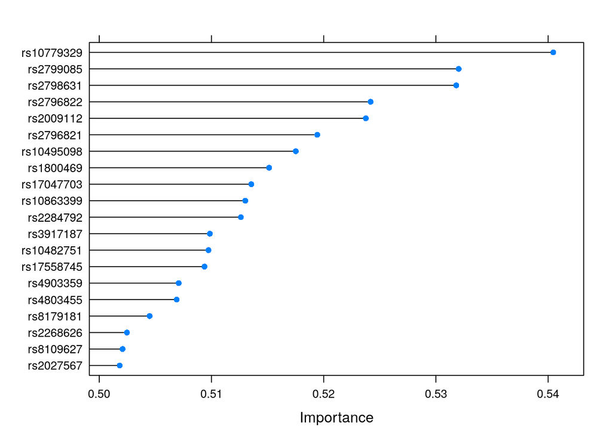

```r
# plot importance
plot(importance)
```

## 6.3 Multivariate analysis

Logistic regression, most frequent genotype used as reference:

```r
dane_complete_genetics_factors <- dane_complete_genetics
dane_complete_genetics_numbers <- dane_complete_genetics
for (i in 1:ncol(dane_complete_genetics)) {
  dane_complete_genetics_factors[,i] = as.factor(dane_complete_genetics[,i])
  temp2 = summary(dane_complete_genetics[,i])
  najcz = rownames(temp2$genotype.freq)[1]
  sr = rownames(temp2$genotype.freq)[2]
  najrz = rownames(temp2$genotype.freq)[3]
  dane_complete_genetics_factors[,i] = as.character(dane_complete_genetics_factors[,i])
  dane_complete_genetics_factors[,i] = factor(dane_complete_genetics_factors[,i], c(najcz,sr,najrz))

  dane_complete_genetics_numbers[,i] = as.numeric(dane_complete_genetics_factors[,i])-1
}


library(epiDisplay)
temp = cbind(clin$clinical_ill, dane_complete_genetics_factors)
temp2 = cbind(clin$clinical_ill, dane_complete_genetics_numbers)
colnames(temp)[1] = "status"
colnames(temp2)[1] = "status"
glm1 <- glm(status~.,
            family=binomial, data=temp)
print(logistic.display(glm1))
```

```
##
## Logistic regression predicting status : Ill vs Healthy
##
##                      crude OR(95%CI)    adj. OR(95%CI)     P(Wald's test)
## rs8109627: ref.=T/T
##    T/C               1.05 (0.74,1.47)   1.04 (0.7,1.53)    0.849
##    C/C               0.91 (0.45,1.87)   0.96 (0.43,2.15)   0.926
##
## rs8179181: ref.=G/G
##    G/A               0.93 (0.66,1.31)   0.91 (0.61,1.34)   0.622
##    A/A               1.05 (0.56,1.96)   1.05 (0.5,2.2)     0.896
##
## rs4803455: ref.=C/C
##    C/A               0.94 (0.64,1.38)   1.07 (0.69,1.66)   0.766
##    A/A               0.93 (0.59,1.46)   1.03 (0.53,2.03)   0.921
##
## rs1800469: ref.=G/G
##    G/A               1.12 (0.81,1.55)   1.09 (0.69,1.74)   0.709
##    A/A               626546.15 (0,Inf)  343665.63 (0,Inf)  0.981
##
## rs10495098: ref.=G/G
##    G/T               0.91 (0.63,1.31)   0.93 (0.58,1.49)   0.772
##    T/T               1.31 (0.81,2.12)   1.42 (0.75,2.69)   0.285
##
## rs17047703: ref.=C/C
##    C/A               0.9 (0.64,1.27)    0.59 (0.29,1.2)    0.143
##    A/A               0.84 (0.38,1.87)   0.48 (0.11,2.01)   0.313
##
## rs17558745: ref.=C/C
##    C/T               1.14 (0.81,1.61)   1.7 (0.9,3.23)     0.104
##    T/T               0.94 (0.5,1.74)    1.69 (0.57,5)      0.345
##
## rs2799085: ref.=C/C
##    C/A               1.02 (0.71,1.45)   0.78 (0.45,1.33)   0.353
##    A/A               0.62 (0.39,1)      0.38 (0.17,0.87)   0.022
##
## rs2009112: ref.=C/C
##    C/T               1.04 (0.72,1.52)   0.74 (0.43,1.28)   0.279
##    T/T               1.3 (0.83,2.04)    1.08 (0.52,2.28)   0.832
##
```

[output cut: 113 more lines]

```
## rs3917187: ref.=C/C  0.574
##    C/T
##    T/T
##
## rs2284792: ref.=A/A  0.024
##    A/G
##    G/G
##
## rs2268626: ref.=T/T  0.058
##    T/C
##    C/C
##
## Log-likelihood = -389.3114
## No. of observations = 605
## AIC value = 860.6228
```

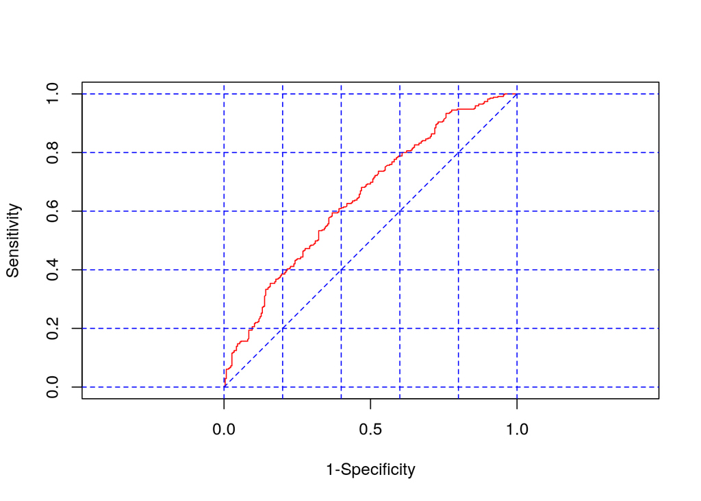

```
## $model.description
## [1] "status ~ ."
##
## $auc
## [1] 0.6496823
##
## $predicted.table
##  predicted.prob Non-diseased Diseased
##          0.1194            1        0
##          0.1286            1        0
##          0.1743            1        0
##          0.1757            1        0
##          0.1810            1        0
##          0.1965            1        0
##          0.1970            1        0
##          0.2043            1        0
##          0.2052            1        0
##          0.2121            1        0
##          0.2276            1        0
##          0.2294            0        1
##          0.2322            1        0
##          0.2351            0        1
##          0.2388            0        1
##          0.2447            1        0
##          0.2497            1        0
##          0.2556            1        0
##          0.2646            1        0
##          0.2729            1        0
##          0.2738            0        1
##          0.2752            1        0
##          0.2783            1        0
##          0.2895            1        0
##          0.2922            1        0
##          0.2948            0        1
##          0.2984            1        0
##          0.2996            1        0
##          0.3050            1        0
##          0.3086            0        1
##          0.3211            1        0
##          0.3254            1        0
```

[output cut: 1111 more lines]

```
## >    0.007692308 0.034782609
## >    0.007692308 0.031884058
## >    0.007692308 0.028985507
## >    0.003846154 0.028985507
## >    0.003846154 0.026086957
## >    0.003846154 0.023188406
## >    0.003846154 0.020289855
## >    0.003846154 0.017391304
## >    0.003846154 0.014492754
## >    0.003846154 0.011594203
## >    0.003846154 0.008695652
## >    0.003846154 0.005797101
## >    0.003846154 0.002898551
## >    0.000000000 0.002898551
## >    0.000000000 0.000000000
```

```r
lroc(glm1)
```

### 6.3.1 Backward stepwise selection

```r
glm2 = step(glm1)
```

```
## Start:  AIC=860.62
## status ~ rs8109627 + rs8179181 + rs4803455 + rs1800469 + rs10495098 +
##     rs17047703 + rs17558745 + rs2799085 + rs2009112 + rs10482751 +
##     rs2027567 + rs10779329 + rs2796821 + rs2796822 + rs2798631 +
##     rs10863399 + rs4903359 + rs3917187 + rs2284792 + rs2268626
##
##              Df Deviance    AIC
## - rs8109627   2   778.68 856.68
## - rs4803455   2   778.72 856.72
## - rs8179181   2   778.96 856.96
## - rs2796822   2   779.15 857.15
## - rs1800469   2   779.39 857.39
## - rs2798631   2   779.44 857.44
## - rs2027567   2   779.49 857.49
## - rs3917187   2   779.73 857.73
## - rs10482751  2   780.07 858.07
## - rs17047703  2   780.93 858.93
## - rs10863399  2   780.93 858.93
## - rs10495098  2   781.10 859.10
## - rs17558745  2   781.33 859.33
## - rs10779329  2   781.57 859.57
## - rs2009112   2   781.75 859.75
## - rs2796821   2   782.60 860.60
## <none>            778.62 860.62
## - rs2268626   2   784.32 862.32
## - rs2799085   2   784.48 862.48
## - rs2284792   2   786.07 864.07
## - rs4903359   2   786.84 864.84
##
## Step:  AIC=856.68
## status ~ rs8179181 + rs4803455 + rs1800469 + rs10495098 + rs17047703 +
##     rs17558745 + rs2799085 + rs2009112 + rs10482751 + rs2027567 +
##     rs10779329 + rs2796821 + rs2796822 + rs2798631 + rs10863399 +
##     rs4903359 + rs3917187 + rs2284792 + rs2268626
##
##              Df Deviance    AIC
## - rs4803455   2   778.79 852.79
## - rs8179181   2   779.00 853.00
## - rs2796822   2   779.20 853.20
## - rs1800469   2   779.48 853.48
```

[output cut: 270 more lines]

```
## - rs2799085   2   805.14 827.14
## - rs10779329  2   805.49 827.49
## - rs4903359   2   808.77 830.77
## - rs2284792   2   809.75 831.75
##
## Step:  AIC=824.73
## status ~ rs2799085 + rs10779329 + rs4903359 + rs2284792 + rs2268626
##
##              Df Deviance    AIC
## <none>            802.73 824.73
## - rs2799085   2   807.33 825.33
## - rs2268626   2   808.19 826.19
## - rs10779329  2   808.40 826.40
## - rs4903359   2   811.01 829.01
## - rs2284792   2   812.44 830.44
```

```r
print(logistic.display(glm2))
```

```
##
## Logistic regression predicting status : Ill vs Healthy
##
##                      crude OR(95%CI)        adj. OR(95%CI)
## rs2799085: ref.=C/C
##    C/A               1.0153 (0.7114,1.449)  1.0034 (0.6977,1.4431)
##    A/A               0.62 (0.39,1)          0.61 (0.37,1.01)
##
## rs10779329: ref.=T/T
##    T/C               0.91 (0.65,1.29)       0.96 (0.67,1.36)
##    C/C               0.45 (0.25,0.81)       0.49 (0.27,0.89)
##
## rs4903359: ref.=A/A
##    A/G               0.85 (0.61,1.19)       0.74 (0.47,1.16)
##    G/G               1.73 (0.7,4.31)        4.72 (0.99,22.62)
##
## rs2284792: ref.=A/A
##    A/G               1.12 (0.8,1.57)        2.05 (1.03,4.07)
##    G/G               1.07 (0.52,2.2)        0.29 (0.05,1.67)
##
## rs2268626: ref.=T/T
##    T/C               0.91 (0.64,1.3)        0.57 (0.3,1.09)
##    C/C               1.48 (0.59,3.76)       2.21 (0.41,11.81)
##
##                      P(Wald's test) P(LR-test)
## rs2799085: ref.=C/C                 0.1
##    C/A               0.985
##    A/A               0.053
##
## rs10779329: ref.=T/T                0.059
##    T/C               0.804
##    C/C               0.02
##
## rs4903359: ref.=A/A                 0.016
##    A/G               0.182
##    G/G               0.052
##
## rs2284792: ref.=A/A                 0.008
##    A/G               0.04
##    G/G               0.164
##
## rs2268626: ref.=T/T                 0.065
##    T/C               0.088
##    C/C               0.354
##
## Log-likelihood = -401.3648
## No. of observations = 605
## AIC value = 824.7296
```

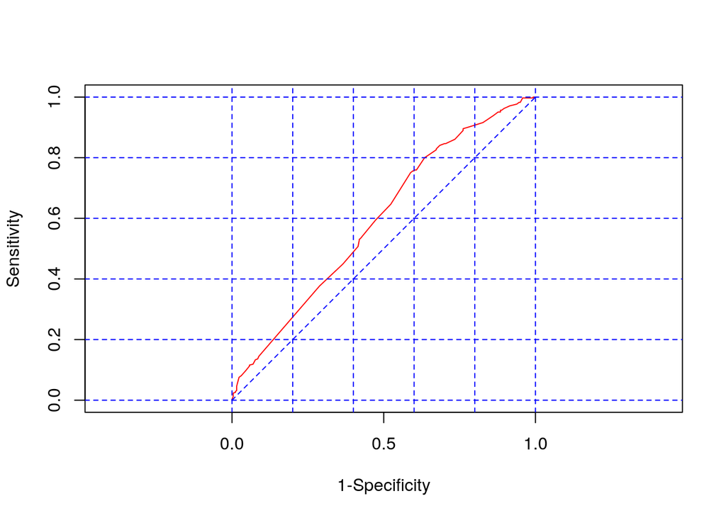

```
## $model.description
## [1] "status ~ rs2799085 + rs10779329 + rs4903359 + rs2284792 + rs2268626"
##
## $auc
## [1] 0.5936232
##
## $predicted.table
##  predicted.prob Non-diseased Diseased
##          0.1627            2        0
##          0.2443            0        1
##          0.2527            1        0
##          0.2620            5        0
##          0.2950            2        0
##          0.3134            1        0
##          0.3254            2        5
##          0.3675            1        0
##          0.3683            2        2
##          0.4065            3        1
##          0.4073            3        1
##          0.4088            5        3
##          0.4175            2        2
##          0.4197            1        0
##          0.4215            0        1
##          0.4276            0        1
##          0.4284            1        0
##          0.4325            1        0
##          0.4412            4        4
##          0.4420            9        8
##          0.4491           12        5
##          0.4602            5        2
##          0.4803            0        1
##          0.4812            0        1
##          0.4844            7       10
##          0.4957            8        5
##          0.5255            1        0
##          0.5309            4        2
##          0.5317            3        4
##          0.5367            0        1
##          0.5420           10        9
##          0.5429            7       14
```

[output cut: 89 more lines]

```
## >    0.057692308 0.113043478
## >    0.046153846 0.098550725
## >    0.030769231 0.081159420
## >    0.023076923 0.075362319
## >    0.015384615 0.046376812
## >    0.015384615 0.040579710
## >    0.015384615 0.034782609
## >    0.015384615 0.031884058
## >    0.011538462 0.028985507
## >    0.011538462 0.026086957
## >    0.003846154 0.023188406
## >    0.003846154 0.020289855
## >    0.003846154 0.011594203
## >    0.000000000 0.002898551
## >    0.000000000 0.000000000
```

```r
lroc(glm2)
```

### 6.3.2 As numbers

```r
glm3 <- glm(status~.,
            family=binomial, data=temp2)
print(logistic.display(glm3))
```

```
##
## Logistic regression predicting status : Ill vs Healthy
##
##                         crude OR(95%CI)   adj. OR(95%CI)    P(Wald's test)
## rs8109627 (cont. var.)  1 (0.77,1.31)     1.02 (0.75,1.38)  0.894
##
## rs8179181 (cont. var.)  0.98 (0.76,1.27)  0.98 (0.73,1.32)  0.897
##
## rs4803455 (cont. var.)  0.96 (0.77,1.21)  1.02 (0.74,1.39)  0.922
##
## rs1800469 (cont. var.)  1.13 (0.82,1.57)  1.14 (0.75,1.75)  0.536
##
## rs10495098 (cont. var.) 1.11 (0.88,1.4)   1.15 (0.85,1.56)  0.364
##
## rs17047703 (cont. var.) 0.91 (0.69,1.2)   0.61 (0.34,1.1)   0.103
##
## rs17558745 (cont. var.) 1.04 (0.81,1.34)  1.51 (0.93,2.46)  0.099
##
## rs2799085 (cont. var.)  0.83 (0.66,1.04)  0.71 (0.48,1.05)  0.086
##
## rs2009112 (cont. var.)  1.13 (0.91,1.42)  1.05 (0.73,1.5)   0.8
##
## rs10482751 (cont. var.) 0.92 (0.72,1.17)  1.14 (0.67,1.93)  0.628
##
## rs2027567 (cont. var.)  0.99 (0.77,1.28)  1.27 (0.8,2.01)   0.311
##
## rs10779329 (cont. var.) 0.76 (0.59,0.97)  0.83 (0.53,1.32)  0.433
##
## rs2796821 (cont. var.)  1.12 (0.85,1.49)  1.56 (0.85,2.87)  0.153
##
## rs2796822 (cont. var.)  0.86 (0.69,1.08)  0.87 (0.47,1.62)  0.661
##
## rs2798631 (cont. var.)  0.84 (0.67,1.06)  0.91 (0.59,1.39)  0.656
##
## rs10863399 (cont. var.) 1.13 (0.83,1.55)  0.87 (0.45,1.68)  0.681
##
## rs4903359 (cont. var.)  0.99 (0.75,1.31)  0.82 (0.51,1.31)  0.398
##
## rs3917187 (cont. var.)  1.07 (0.82,1.41)  1.3 (0.58,2.9)    0.524
##
```

[output cut: 33 more lines]

```
## rs2798631 (cont. var.)  0.656
##
## rs10863399 (cont. var.) 0.681
##
## rs4903359 (cont. var.)  0.398
##
## rs3917187 (cont. var.)  0.524
##
## rs2284792 (cont. var.)  0.738
##
## rs2268626 (cont. var.)  0.51
##
## Log-likelihood = -404.1829
## No. of observations = 605
## AIC value = 850.3658
```

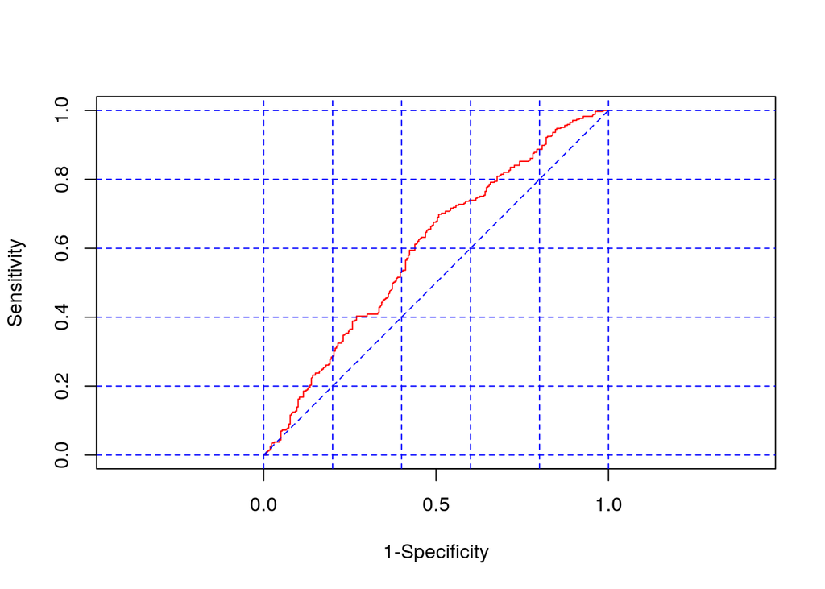

```
## $model.description
## [1] "status ~ ."
##
## $auc
## [1] 0.5979877
##
## $predicted.table
##  predicted.prob Non-diseased Diseased
##          0.2043            1        0
##          0.2990            1        0
##          0.3046            1        0
##          0.3206            1        0
##          0.3351            0        1
##          0.3423            1        0
##          0.3468            1        0
##          0.3540            1        0
##          0.3603            1        0
##          0.3616            1        0
##          0.3630            1        0
##          0.3669            0        1
##          0.3723            0        1
##          0.3741            0        1
##          0.3773            1        0
##          0.3782            1        1
##          0.3811            0        1
##          0.3813            1        0
##          0.3820            1        0
##          0.3862            1        0
##          0.3867            1        0
##          0.3903            1        0
##          0.3914            1        0
##          0.3934            1        0
##          0.3938            0        1
##          0.3942            0        1
##          0.3976            1        0
##          0.3977            1        0
##          0.4032            1        0
##          0.4042            0        1
##          0.4052            1        0
##          0.4078            1        0
```

[output cut: 1111 more lines]

```
## >    0.019230769 0.026086957
## >    0.019230769 0.023188406
## >    0.019230769 0.020289855
## >    0.019230769 0.017391304
## >    0.019230769 0.014492754
## >    0.015384615 0.014492754
## >    0.015384615 0.011594203
## >    0.011538462 0.011594203
## >    0.011538462 0.008695652
## >    0.007692308 0.008695652
## >    0.007692308 0.005797101
## >    0.007692308 0.002898551
## >    0.007692308 0.000000000
## >    0.003846154 0.000000000
## >    0.000000000 0.000000000
```

```r
lroc(glm3)
```

Backword stepwise:

```r
glm4 = step(glm3)
```

```
## Start:  AIC=850.37
## status ~ rs8109627 + rs8179181 + rs4803455 + rs1800469 + rs10495098 +
##     rs17047703 + rs17558745 + rs2799085 + rs2009112 + rs10482751 +
##     rs2027567 + rs10779329 + rs2796821 + rs2796822 + rs2798631 +
##     rs10863399 + rs4903359 + rs3917187 + rs2284792 + rs2268626
##
##              Df Deviance    AIC
## - rs4803455   1   808.38 848.38
## - rs8179181   1   808.38 848.38
## - rs8109627   1   808.38 848.38
## - rs2009112   1   808.43 848.43
## - rs2284792   1   808.48 848.48
## - rs10863399  1   808.53 848.53
## - rs2796822   1   808.56 848.56
## - rs2798631   1   808.56 848.56
## - rs10482751  1   808.60 848.60
## - rs1800469   1   808.75 848.75
## - rs3917187   1   808.77 848.77
## - rs2268626   1   808.80 848.80
## - rs10779329  1   808.98 848.98
## - rs4903359   1   809.08 849.08
## - rs10495098  1   809.19 849.19
## - rs2027567   1   809.40 849.40
## <none>            808.37 850.37
## - rs2796821   1   810.43 850.43
## - rs17047703  1   811.06 851.06
## - rs17558745  1   811.15 851.15
## - rs2799085   1   811.33 851.33
##
## Step:  AIC=848.38
## status ~ rs8109627 + rs8179181 + rs1800469 + rs10495098 + rs17047703 +
##     rs17558745 + rs2799085 + rs2009112 + rs10482751 + rs2027567 +
##     rs10779329 + rs2796821 + rs2796822 + rs2798631 + rs10863399 +
##     rs4903359 + rs3917187 + rs2284792 + rs2268626
##
##              Df Deviance    AIC
## - rs8179181   1   808.39 846.39
## - rs8109627   1   808.40 846.40
## - rs2009112   1   808.44 846.44
## - rs2284792   1   808.49 846.49
```

[output cut: 280 more lines]

```
## <none>            814.32 826.32
## - rs2027567   1   817.63 827.63
## - rs2799085   1   820.07 830.07
## - rs2796822   1   820.30 830.30
## - rs2796821   1   820.70 830.70
##
## Step:  AIC=824.73
## status ~ rs2799085 + rs2027567 + rs2796821 + rs2796822
##
##             Df Deviance    AIC
## <none>           814.73 824.73
## - rs2027567  1   817.77 825.77
## - rs2799085  1   820.08 828.08
## - rs2796822  1   820.78 828.78
## - rs2796821  1   821.54 829.54
```

```r
logistic.display(glm4)
```

```
##
## Logistic regression predicting status : Ill vs Healthy
##
##                        crude OR(95%CI)   adj. OR(95%CI)    P(Wald's test)
## rs2799085 (cont. var.) 0.83 (0.66,1.04)  0.7 (0.51,0.95)   0.021
##
## rs2027567 (cont. var.) 0.99 (0.77,1.28)  1.35 (0.96,1.91)  0.083
##
## rs2796821 (cont. var.) 1.12 (0.85,1.49)  1.68 (1.13,2.48)  0.01
##
## rs2796822 (cont. var.) 0.86 (0.69,1.08)  0.67 (0.49,0.92)  0.014
##
##                        P(LR-test)
## rs2799085 (cont. var.) 0.021
##
## rs2027567 (cont. var.) 0.082
##
## rs2796821 (cont. var.) 0.009
##
## rs2796822 (cont. var.) 0.014
##
## Log-likelihood = -407.3673
## No. of observations = 605
## AIC value = 824.7346
```

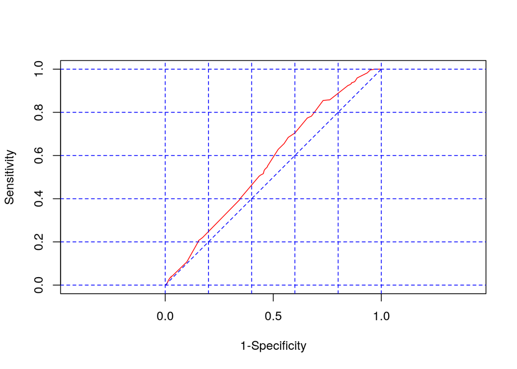

```
## $model.description
## [1] "status ~ rs2799085 + rs2027567 + rs2796821 + rs2796822"
##
## $auc
## [1] 0.5659643
##
## $predicted.table
##  predicted.prob Non-diseased Diseased
##          0.2645            1        0
##          0.3407            4        0
##          0.3480            2        0
##          0.3762            1        0
##          0.3971            4        1
##          0.4116            1        0
##          0.4195            4        5
##          0.4263            3        2
##          0.4342            6        4
##          0.4422            3        2
##          0.4494            3        6
##          0.4644            2        1
##          0.4724            2        1
##          0.4863            0        1
##          0.4944            2        2
##          0.5029            2        1
##          0.5095           22       23
##          0.5176            8        1
##          0.5245           14       25
##          0.5249            5        3
##          0.5326           15       24
##          0.5399            8        7
##          0.5479            5       10
##          0.5548            7        9
##          0.5628           13       27
##          0.5764            0        1
##          0.5779            3        4
##          0.5843            1        2
##          0.5922            1        5
##          0.5925            3        2
##          0.5989            2        2
##          0.6066           23       36
```

[output cut: 47 more lines]

```
## >    0.434615385 0.504347826
## >    0.346153846 0.400000000
## >    0.346153846 0.397101449
## >    0.173076923 0.220289855
## >    0.153846154 0.205797101
## >    0.153846154 0.202898551
## >    0.100000000 0.107246377
## >    0.030769231 0.040579710
## >    0.026923077 0.040579710
## >    0.026923077 0.034782609
## >    0.023076923 0.034782609
## >    0.015384615 0.023188406
## >    0.007692308 0.005797101
## >    0.003846154 0.000000000
## >    0.000000000 0.000000000
```

```r
lroc(glm4)
```

## 6.4 Univariate - classical approach

Just simple univariate logistic regression:

```r
#temp = cbind(chorzy.clin$astma1, dane_complete_genetics_factors[clin$clinical_ill == "Ill",])
colnames(temp)[1] = "status"
#temp$status = ifelse(temp$status=="Ciężka","Severe","Mild")
#temp$status = as.factor(temp$status)
for (i in 2:length(colnames(temp))) {
  cat(paste0("\n\n\nFor ",colnames(temp)[i], ":\n"))
  temp2 = glm(temp$status~temp[,colnames(temp)[i]], family = "binomial")
  print(logistic.display(temp2))
  cat(paste0("\nReference: ",levels(temp[,colnames(temp)[i]])[1]))
}
```

```
##
##
##
## For rs8109627:
##
##                                     OR lower95ci upper95ci  Pr(>|Z|)
## temp[, colnames(temp)[i]]T/C 1.0472201 0.7439527  1.474112 0.7914081
## temp[, colnames(temp)[i]]C/C 0.9148515 0.4468358  1.873067 0.8076838
##
## Reference: T/T
##
##
## For rs8179181:
##
##                                     OR lower95ci upper95ci  Pr(>|Z|)
## temp[, colnames(temp)[i]]G/A 0.9338197 0.6645647  1.312166 0.6931841
## temp[, colnames(temp)[i]]A/A 1.0470914 0.5598004  1.958556 0.8854770
##
## Reference: G/G
##
##
## For rs4803455:
##
##                                     OR lower95ci upper95ci  Pr(>|Z|)
## temp[, colnames(temp)[i]]C/A 0.9394685 0.6385556  1.382184 0.7512699
## temp[, colnames(temp)[i]]A/A 0.9321289 0.5946861  1.461047 0.7592208
##
## Reference: C/C
##
##
## For rs1800469:
##
##                                        OR lower95ci upper95ci  Pr(>|Z|)
## temp[, colnames(temp)[i]]G/A 1.117692e+00 0.8082406  1.545624 0.5011108
## temp[, colnames(temp)[i]]A/A 6.265461e+05 0.0000000       Inf 0.9801105
##
## Reference: G/G
##
##
## For rs10495098:
```

[output cut: 126 more lines]

```
##
##                                    OR lower95ci upper95ci  Pr(>|Z|)
## temp[, colnames(temp)[i]]A/G 1.119388 0.7970792  1.572027 0.5150840
## temp[, colnames(temp)[i]]G/G 1.070324 0.5198708  2.203612 0.8536562
##
## Reference: A/A
##
##
## For rs2268626:
##
##                                     OR lower95ci upper95ci  Pr(>|Z|)
## temp[, colnames(temp)[i]]T/C 0.9122955 0.6421362  1.296116 0.6084276
## temp[, colnames(temp)[i]]C/C 1.4847162 0.5865441  3.758254 0.4042431
##
## Reference: T/T
```

## 6.5 Diagnostic model

```r
library(caret)

# define training control
train_control <- trainControl(method="LOOCV")
# train the model
temp3 = temp[complete.cases(temp),]
a <- createDataPartition(temp3$status, p = 0.8, list=FALSE)
training <- temp3[a,]
test <- temp3[-a,]
model <- train(status~., data=training, trControl=train_control, method="svmLinearWeights2")
# summarize results
#plot(model$finalModel)
cat("TRAINING ----")
```

```
## TRAINING ----
```

```r
confusionMatrix(predict(model), training$status)
```

```
## Confusion Matrix and Statistics
##
##           Reference
## Prediction Healthy Ill
##    Healthy      62  30
##    Ill         146 246
##
##                Accuracy : 0.6364
##                  95% CI : (0.5917, 0.6793)
##     No Information Rate : 0.5702
##     P-Value [Acc > NIR] : 0.001794
##
##                   Kappa : 0.2034
##
##  Mcnemar's Test P-Value : < 2.2e-16
##
##             Sensitivity : 0.2981
##             Specificity : 0.8913
##          Pos Pred Value : 0.6739
##          Neg Pred Value : 0.6276
##              Prevalence : 0.4298
##          Detection Rate : 0.1281
##    Detection Prevalence : 0.1901
##       Balanced Accuracy : 0.5947
##
##        'Positive' Class : Healthy
##
```

```r
cat("TEST ------")
```

```
## TEST ------
```

```r
confusionMatrix(predict(model, newdata = test), test$status)
```

```
## Confusion Matrix and Statistics
##
##           Reference
## Prediction Healthy Ill
##    Healthy      12  16
##    Ill          40  53
##
##                Accuracy : 0.5372
##                  95% CI : (0.4443, 0.6283)
##     No Information Rate : 0.5702
##     P-Value [Acc > NIR] : 0.796046
##
##                   Kappa : -0.0012
##
##  Mcnemar's Test P-Value : 0.002116
##
##             Sensitivity : 0.23077
##             Specificity : 0.76812
##          Pos Pred Value : 0.42857
##          Neg Pred Value : 0.56989
##              Prevalence : 0.42975
##          Detection Rate : 0.09917
##    Detection Prevalence : 0.23140
##       Balanced Accuracy : 0.49944
##
##        'Positive' Class : Healthy
##
```

```r
saveRDS(model, "model2.RDS")
```

# 7 Severity

## 7.1 Univariate

```r
temp = cbind(chorzy.clin$astma1, dane_complete_genetics_factors[clin$clinical_ill == "Ill",])
colnames(temp)[1] = "status"
temp2 = cbind(chorzy.clin$astma1, dane_complete_genetics_numbers[clin$clinical_ill == "Ill",])
colnames(temp2)[1] = "status"
temp$status = ifelse(temp$status=="Ciężka","Severe","Mild")
temp$status = as.factor(temp$status)
for (i in 2:length(colnames(temp))) {
  cat(paste0("\n\n\nFor ",colnames(temp)[i], ":\n"))
  temp2 = glm(temp$status~temp[,colnames(temp)[i]], family = "binomial")
  print(logistic.display(temp2))
  cat(paste0("\nReference: ",levels(temp[,colnames(temp)[i]])[1]))
}
```

```
##
##
##
## For rs8109627:
##
##                                     OR lower95ci upper95ci   Pr(>|Z|)
## temp[, colnames(temp)[i]]T/C 0.6684149 0.4147702  1.077171 0.09799944
## temp[, colnames(temp)[i]]C/C 1.9871795 0.7518886  5.251951 0.16608998
##
## Reference: T/T
##
##
## For rs8179181:
##
##                                     OR lower95ci upper95ci  Pr(>|Z|)
## temp[, colnames(temp)[i]]G/A 0.8885542 0.5573347  1.416615 0.6195323
## temp[, colnames(temp)[i]]A/A 0.6900585 0.2872248  1.657868 0.4067962
##
## Reference: G/G
##
##
## For rs4803455:
##
##                                     OR lower95ci upper95ci   Pr(>|Z|)
## temp[, colnames(temp)[i]]C/A 0.7793264 0.4666121 1.3016156 0.34074332
## temp[, colnames(temp)[i]]A/A 0.5142276 0.2743783 0.9637426 0.03796845
##
## Reference: C/C
##
##
## For rs1800469:
##
##                                        OR lower95ci upper95ci  Pr(>|Z|)
## temp[, colnames(temp)[i]]G/A 1.252319e+00 0.8005927  1.958928 0.3242978
## temp[, colnames(temp)[i]]A/A 1.574370e+06 0.0000000       Inf 0.9787379
##
## Reference: G/G
##
##
## For rs10495098:
```

[output cut: 126 more lines]

```
##
##                                    OR lower95ci upper95ci  Pr(>|Z|)
## temp[, colnames(temp)[i]]A/G 1.012245 0.6390001  1.603505 0.9586452
## temp[, colnames(temp)[i]]G/G 1.033333 0.3889409  2.745347 0.9475594
##
## Reference: A/A
##
##
## For rs2268626:
##
##                                    OR lower95ci upper95ci  Pr(>|Z|)
## temp[, colnames(temp)[i]]T/C 1.248966 0.7710066  2.023220 0.3663637
## temp[, colnames(temp)[i]]C/C 1.935897 0.6556464  5.716036 0.2317756
##
## Reference: T/T
```

## 7.2 Multivariate

```r
glm1 <- glm(status~.,
            family=binomial, data=temp)
print(logistic.display(glm1))
```

```
##
## Logistic regression predicting status : Severe vs Mild
##
##                      crude OR(95%CI)     adj. OR(95%CI)
## rs8109627: ref.=T/T
##    T/C               0.67 (0.41,1.08)    0.72 (0.4,1.31)
##    C/C               1.99 (0.75,5.25)    3.22 (0.99,10.45)
##
## rs8179181: ref.=G/G
##    G/A               0.89 (0.56,1.42)    1.09 (0.59,2)
##    A/A               0.69 (0.29,1.66)    0.91 (0.3,2.79)
##
## rs4803455: ref.=C/C
##    C/A               0.78 (0.47,1.3)     0.88 (0.46,1.69)
##    A/A               0.51 (0.27,0.96)    0.49 (0.17,1.39)
##
## rs1800469: ref.=G/G
##    G/A               1.25 (0.8,1.96)     0.63 (0.31,1.26)
##    A/A               1574370.46 (0,Inf)  223591379.88 (0,Inf)
##
## rs10495098: ref.=G/G
##    G/T               1.07 (0.64,1.77)    0.84 (0.42,1.7)
##    T/T               0.93 (0.5,1.74)     1.25 (0.5,3.11)
##
## rs17047703: ref.=C/C
##    C/A               0.93 (0.58,1.49)    2.05 (0.77,5.46)
##    A/A               0.28 (0.06,1.26)    0.32 (0.02,4.76)
##
## rs17558745: ref.=C/C
##    C/T               0.71 (0.45,1.13)    0.33 (0.14,0.81)
##    T/T               0.47 (0.18,1.22)    0.28 (0.05,1.47)
##
## rs2799085: ref.=C/C
##    C/A               1.02 (0.63,1.63)    1.22 (0.54,2.74)
##    A/A               0.84 (0.41,1.71)    1.49 (0.39,5.65)
##
## rs2009112: ref.=C/C
##    C/T               1.83 (1.06,3.16)    2.64 (1.12,6.26)
##    T/T               1.9 (1.02,3.54)     3.23 (1.02,10.25)
##
```

[output cut: 113 more lines]

```
## rs3917187: ref.=C/C                 0.308
##    C/T               0.18
##    T/T               0.21
##
## rs2284792: ref.=A/A                 0.013
##    A/G               0.749
##    G/G               0.983
##
## rs2268626: ref.=T/T                 0.006
##    T/C               0.193
##    C/C               0.984
##
## Log-likelihood = -187.3775
## No. of observations = 345
## AIC value = 456.7551
```

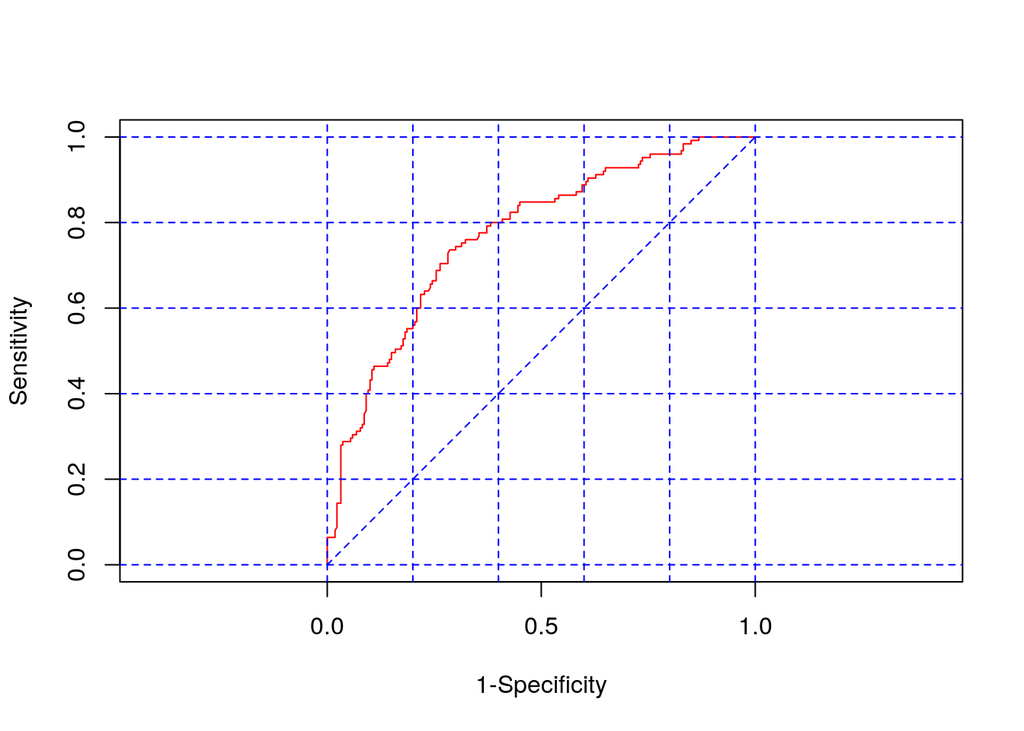

[output not shown]

[output cut: 623 more lines]

[output not shown]

```r
lroc(glm1)
```

### 7.2.1 Backward stepwise selection

```r
glm2 = step(glm1)
```

```
## Start:  AIC=456.76
## status ~ rs8109627 + rs8179181 + rs4803455 + rs1800469 + rs10495098 +
##     rs17047703 + rs17558745 + rs2799085 + rs2009112 + rs10482751 +
##     rs2027567 + rs10779329 + rs2796821 + rs2796822 + rs2798631 +
##     rs10863399 + rs4903359 + rs3917187 + rs2284792 + rs2268626
##
##              Df Deviance    AIC
## - rs8179181   2   374.90 452.90
## - rs2799085   2   375.12 453.12
## - rs10779329  2   375.90 453.90
## - rs10495098  2   375.95 453.95
## - rs4803455   2   376.79 454.79
## - rs10863399  2   376.83 454.83
## - rs3917187   2   377.11 455.11
## - rs10482751  2   377.77 455.77
## - rs2027567   2   378.21 456.21
## <none>            374.76 456.76
## - rs17047703  2   379.54 457.54
## - rs2796821   2   379.56 457.56
## - rs4903359   2   379.81 457.81
## - rs2009112   2   380.18 458.18
## - rs1800469   2   380.74 458.74
## - rs17558745  2   381.07 459.07
## - rs8109627   2   381.31 459.31
## - rs2284792   2   383.43 461.43
## - rs2798631   2   384.60 462.60
## - rs2268626   2   384.97 462.97
## - rs2796822   2   387.21 465.21
##
## Step:  AIC=452.9
## status ~ rs8109627 + rs4803455 + rs1800469 + rs10495098 + rs17047703 +
##     rs17558745 + rs2799085 + rs2009112 + rs10482751 + rs2027567 +
##     rs10779329 + rs2796821 + rs2796822 + rs2798631 + rs10863399 +
##     rs4903359 + rs3917187 + rs2284792 + rs2268626
##
##              Df Deviance    AIC
## - rs2799085   2   375.27 449.27
## - rs10779329  2   376.08 450.08
## - rs10495098  2   376.10 450.10
## - rs10863399  2   376.96 450.96
```

[output cut: 217 more lines]

```
## Step:  AIC=432.7
## status ~ rs8109627 + rs17558745 + rs2009112 + rs2796821 + rs2796822 +
##     rs2798631 + rs4903359 + rs2284792 + rs2268626
##
##              Df Deviance    AIC
## <none>            394.70 432.70
## - rs4903359   2   399.69 433.69
## - rs2009112   2   400.35 434.35
## - rs17558745  2   401.15 435.15
## - rs8109627   2   401.51 435.51
## - rs2796821   2   402.20 436.20
## - rs2268626   2   405.02 439.02
## - rs2798631   2   405.15 439.15
## - rs2284792   2   407.94 441.94
## - rs2796822   2   409.35 443.35
```

```r
print(logistic.display(glm2))
```

```
##
## Logistic regression predicting status : Severe vs Mild
##
##                      crude OR(95%CI)         adj. OR(95%CI)
## rs8109627: ref.=T/T
##    T/C               0.67 (0.41,1.08)        0.77 (0.46,1.29)
##    C/C               1.99 (0.75,5.25)        3.35 (1.11,10.14)
##
## rs17558745: ref.=C/C
##    C/T               0.71 (0.45,1.13)        0.59 (0.35,1)
##    T/T               0.47 (0.18,1.22)        0.35 (0.12,1.01)
##
## rs2009112: ref.=C/C
##    C/T               1.83 (1.06,3.16)        1.98 (1.06,3.71)
##    T/T               1.9 (1.02,3.54)         2.15 (1.04,4.44)
##
## rs2796821: ref.=C/C
##    C/T               1.93 (1.22,3.05)        2.52 (1.26,5.05)
##    T/T               0.4 (0.09,1.88)         1.28 (0.2,8.28)
##
## rs2796822: ref.=A/A
##    A/G               2.02 (1.25,3.28)        1.82 (0.72,4.59)
##    G/G               0.87 (0.41,1.85)        0.18 (0.04,0.89)
##
## rs2798631: ref.=A/A
##    A/G               1.46 (0.88,2.43)        0.65 (0.27,1.56)
##    G/G               1.49 (0.77,2.86)        3.55 (1.04,12.12)
##
## rs4903359: ref.=A/A
##    A/G               1.0789 (0.6861,1.6965)  0.9945 (0.502,1.9702)
##    G/G               1.66 (0.61,4.52)        13.52 (0.9,202.04)
##
## rs2284792: ref.=A/A
##    A/G               1.01 (0.64,1.6)         0.58 (0.22,1.52)
##    G/G               1.03 (0.39,2.75)        0 (0,Inf)
##
## rs2268626: ref.=T/T
##    T/C               1.25 (0.77,2.02)        2.02 (0.82,4.98)
##    C/C               1.94 (0.66,5.72)        61164210.48 (0,Inf)
##
```

[output cut: 25 more lines]

```
## rs4903359: ref.=A/A                 0.082
##    A/G               0.987
##    G/G               0.059
##
## rs2284792: ref.=A/A                 0.001
##    A/G               0.27
##    G/G               0.983
##
## rs2268626: ref.=T/T                 0.006
##    T/C               0.126
##    C/C               0.984
##
## Log-likelihood = -197.3476
## No. of observations = 345
## AIC value = 432.6952
```

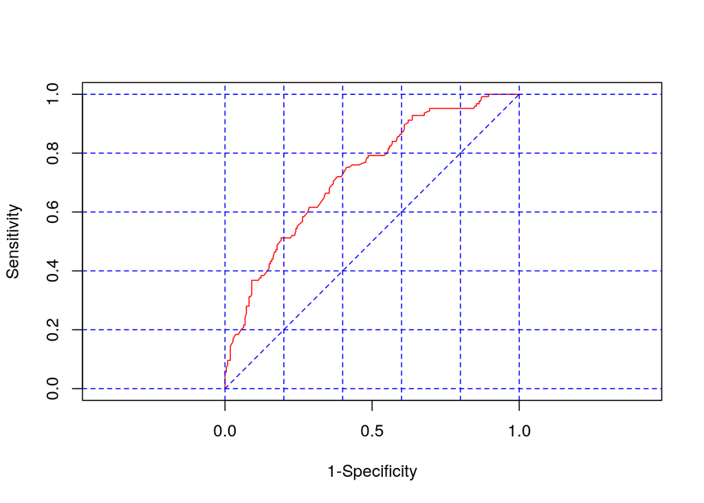

[output not shown]

[output cut: 394 more lines]

[output not shown]

```r
lroc(glm2)
```

### 7.2.2 As numbers

```r
temp2 = cbind(chorzy.clin$astma1, dane_complete_genetics_numbers[clin$clinical_ill == "Ill",])
colnames(temp2)[1] = "status"
glm3 <- glm(status~.,
            family=binomial, data=temp2)
print(logistic.display(glm3))
```

```
##
## Logistic regression predicting status : Nieciężka vs Ciężka
##
##                         crude OR(95%CI)   adj. OR(95%CI)    P(Wald's test)
## rs8109627 (cont. var.)  1.05 (0.72,1.52)  0.93 (0.6,1.45)   0.753
##
## rs8179181 (cont. var.)  1.17 (0.82,1.66)  0.98 (0.64,1.51)  0.941
##
## rs4803455 (cont. var.)  1.38 (1.02,1.89)  1.4 (0.89,2.2)    0.148
##
## rs1800469 (cont. var.)  0.77 (0.49,1.19)  1.18 (0.65,2.14)  0.59
##
## rs10495098 (cont. var.) 1.03 (0.75,1.4)   1.04 (0.69,1.58)  0.846
##
## rs17047703 (cont. var.) 1.29 (0.87,1.92)  0.86 (0.39,1.91)  0.717
##
## rs17558745 (cont. var.) 1.43 (1,2.06)     1.76 (0.89,3.5)   0.106
##
## rs2799085 (cont. var.)  1.06 (0.77,1.47)  0.81 (0.45,1.43)  0.458
##
## rs2009112 (cont. var.)  0.73 (0.54,0.99)  0.5 (0.3,0.85)    0.01
##
## rs10482751 (cont. var.) 1.01 (0.72,1.42)  0.48 (0.2,1.15)   0.099
##
## rs2027567 (cont. var.)  1.18 (0.82,1.69)  1.61 (0.78,3.3)   0.197
##
## rs10779329 (cont. var.) 1.08 (0.76,1.55)  1.16 (0.61,2.22)  0.648
##
## rs2796821 (cont. var.)  0.74 (0.5,1.09)   0.42 (0.17,1.03)  0.058
##
## rs2796822 (cont. var.)  0.87 (0.63,1.2)   1.41 (0.59,3.37)  0.439
##
## rs2798631 (cont. var.)  0.8 (0.58,1.1)    0.62 (0.35,1.09)  0.098
##
## rs10863399 (cont. var.) 0.77 (0.52,1.16)  1.72 (0.69,4.27)  0.242
##
## rs4903359 (cont. var.)  0.86 (0.59,1.24)  0.7 (0.36,1.37)   0.299
##
## rs3917187 (cont. var.)  1.05 (0.73,1.51)  1.9 (0.61,5.91)   0.269
##
```

[output cut: 33 more lines]

```
## rs2798631 (cont. var.)  0.097
##
## rs10863399 (cont. var.) 0.241
##
## rs4903359 (cont. var.)  0.298
##
## rs3917187 (cont. var.)  0.264
##
## rs2284792 (cont. var.)  0.51
##
## rs2268626 (cont. var.)  0.023
##
## Log-likelihood = -209.7156
## No. of observations = 345
## AIC value = 461.4312
```

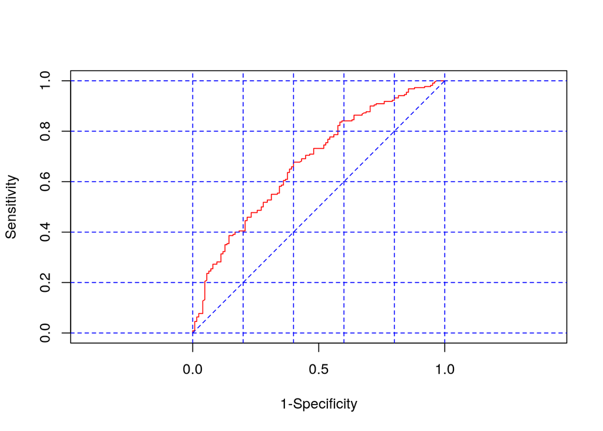

[output not shown]

[output cut: 623 more lines]

[output not shown]

```r
lroc(glm3)
```

Backword stepwise:

```r
glm4 = step(glm3)
```

```
## Start:  AIC=461.43
## status ~ rs8109627 + rs8179181 + rs4803455 + rs1800469 + rs10495098 +
##     rs17047703 + rs17558745 + rs2799085 + rs2009112 + rs10482751 +
##     rs2027567 + rs10779329 + rs2796821 + rs2796822 + rs2798631 +
##     rs10863399 + rs4903359 + rs3917187 + rs2284792 + rs2268626
##
##              Df Deviance    AIC
## - rs8179181   1   419.44 459.44
## - rs10495098  1   419.47 459.47
## - rs8109627   1   419.53 459.53
## - rs17047703  1   419.56 459.56
## - rs10779329  1   419.64 459.64
## - rs1800469   1   419.72 459.72
## - rs2284792   1   419.87 459.87
## - rs2799085   1   419.98 459.98
## - rs2796822   1   420.03 460.03
## - rs4903359   1   420.51 460.51
## - rs3917187   1   420.68 460.68
## - rs10863399  1   420.81 460.81
## - rs2027567   1   421.11 461.11
## <none>            419.43 461.43
## - rs4803455   1   421.52 461.52
## - rs17558745  1   422.14 462.14
## - rs2798631   1   422.18 462.18
## - rs10482751  1   422.19 462.19
## - rs2796821   1   423.01 463.01
## - rs2268626   1   424.62 464.62
## - rs2009112   1   426.27 466.27
##
## Step:  AIC=459.44
## status ~ rs8109627 + rs4803455 + rs1800469 + rs10495098 + rs17047703 +
##     rs17558745 + rs2799085 + rs2009112 + rs10482751 + rs2027567 +
##     rs10779329 + rs2796821 + rs2796822 + rs2798631 + rs10863399 +
##     rs4903359 + rs3917187 + rs2284792 + rs2268626
##
##              Df Deviance    AIC
## - rs10495098  1   419.47 457.47
## - rs8109627   1   419.53 457.53
## - rs17047703  1   419.57 457.57
## - rs10779329  1   419.65 457.65
```

[output cut: 246 more lines]

```
## - rs2009112   1   431.91 447.91
##
## Step:  AIC=443.52
## status ~ rs4803455 + rs17558745 + rs2009112 + rs10482751 + rs2796821 +
##     rs3917187 + rs2268626
##
##              Df Deviance    AIC
## <none>            427.52 443.52
## - rs10482751  1   429.61 443.61
## - rs4803455   1   430.89 444.89
## - rs3917187   1   431.53 445.53
## - rs17558745  1   432.03 446.03
## - rs2268626   1   432.52 446.52
## - rs2796821   1   432.75 446.75
## - rs2009112   1   433.06 447.06
```

```r
print(logistic.display(glm4))
```

```
##
## Logistic regression predicting status : Nieciężka vs Ciężka
##
##                         crude OR(95%CI)   adj. OR(95%CI)    P(Wald's test)
## rs4803455 (cont. var.)  1.38 (1.02,1.89)  1.35 (0.98,1.86)  0.068
##
## rs17558745 (cont. var.) 1.43 (1,2.06)     1.52 (1.03,2.24)  0.037
##
## rs2009112 (cont. var.)  0.73 (0.54,0.99)  0.58 (0.37,0.92)  0.02
##
## rs10482751 (cont. var.) 1.01 (0.72,1.42)  0.69 (0.41,1.14)  0.151
##
## rs2796821 (cont. var.)  0.74 (0.5,1.09)   0.62 (0.41,0.93)  0.022
##
## rs3917187 (cont. var.)  1.05 (0.73,1.51)  1.87 (0.99,3.53)  0.052
##
## rs2268626 (cont. var.)  0.76 (0.52,1.12)  0.48 (0.25,0.93)  0.029
##
##                         P(LR-test)
## rs4803455 (cont. var.)  0.066
##
## rs17558745 (cont. var.) 0.034
##
## rs2009112 (cont. var.)  0.019
##
## rs10482751 (cont. var.) 0.148
##
## rs2796821 (cont. var.)  0.022
##
## rs3917187 (cont. var.)  0.045
##
## rs2268626 (cont. var.)  0.025
##
## Log-likelihood = -213.758
## No. of observations = 345
## AIC value = 443.5161
```

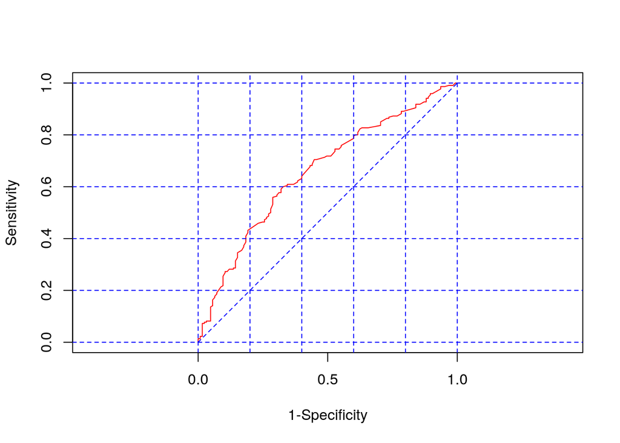

[output not shown]

[output cut: 300 more lines]

[output not shown]

```r
lroc(glm4)
```

## 7.3 Diagnostic model

```r
library(caret)

# define training control
train_control <- trainControl(method="LOOCV")
# train the model
temp3 = temp[complete.cases(temp),]
a <- createDataPartition(temp3$status, p = 0.8, list=FALSE)
training <- temp3[a,]
test <- temp3[-a,]
model <- train(status~., data=training, trControl=train_control, method="svmLinearWeights2")
# summarize results
#plot(model$finalModel)
cat("\nTRAINING ----")
```

```
##
## TRAINING ----
```

```r
confusionMatrix(predict(model), training$status)
```

```
## Confusion Matrix and Statistics
##
##           Reference
## Prediction Mild Severe
##     Mild    163     70
##     Severe   13     30
##
##                Accuracy : 0.6993
##                  95% CI : (0.6414, 0.7528)
##     No Information Rate : 0.6377
##     P-Value [Acc > NIR] : 0.0184
##
##                   Kappa : 0.2579
##
##  Mcnemar's Test P-Value : 7.906e-10
##
##             Sensitivity : 0.9261
##             Specificity : 0.3000
##          Pos Pred Value : 0.6996
##          Neg Pred Value : 0.6977
##              Prevalence : 0.6377
##          Detection Rate : 0.5906
##    Detection Prevalence : 0.8442
##       Balanced Accuracy : 0.6131
##
##        'Positive' Class : Mild
##
```

```r
cat("\nTEST ------")
```

```
##
## TEST ------
```

```r
confusionMatrix(predict(model, newdata = test), test$status)
```

```
## Confusion Matrix and Statistics
##
##           Reference
## Prediction Mild Severe
##     Mild     41     24
##     Severe    3      1
##
##                Accuracy : 0.6087
##                  95% CI : (0.4837, 0.724)
##     No Information Rate : 0.6377
##     P-Value [Acc > NIR] : 0.7365437
##
##                   Kappa : -0.0344
##
##  Mcnemar's Test P-Value : 0.0001186
##
##             Sensitivity : 0.9318
##             Specificity : 0.0400
##          Pos Pred Value : 0.6308
##          Neg Pred Value : 0.2500
##              Prevalence : 0.6377
##          Detection Rate : 0.5942
##    Detection Prevalence : 0.9420
##       Balanced Accuracy : 0.4859
##
##        'Positive' Class : Mild
##
```

```r
saveRDS(model, "model2.RDS")
```

## 7.4 GINA-based

```r
library(caret)
temp = cbind(chorzy.clin$astma2, dane_complete_genetics_factors[clin$clinical_ill == "Ill",])
colnames(temp)[1] = "status"


# define training control
train_control <- trainControl(method="cv", number=10)
# train the model
temp3 = temp[complete.cases(temp),]
a <- createDataPartition(temp3$status, p = 0.8, list=FALSE)
training <- temp3[a,]
test <- temp3[-a,]
model <- train(status~., data=training, trControl=train_control, method="polr")
```

```r
# summarize results
#plot(model$finalModel)
cat("\nTRAINING ----")
```

```
##
## TRAINING ----
```

```r
confusionMatrix(predict(model), training$status)
```

```
## Confusion Matrix and Statistics
##
##                     Reference
## Prediction           0 Zdrowi 1 Łagodna 2 Umiarkowana 3 Steroidowrazliwa
##   0 Zdrowi                  0         0             0                  0
##   1 Łagodna                 2        14            10                  0
##   2 Umiarkowana             0        47            82                 53
##   3 Steroidowrazliwa        0         3            24                 29
##   4 Steroidoporna           0         0             0                  0
##                     Reference
## Prediction           4 Steroidoporna
##   0 Zdrowi                         0
##   1 Łagodna                        0
##   2 Umiarkowana                   11
##   3 Steroidowrazliwa               3
##   4 Steroidoporna                  1
##
## Overall Statistics
##
##                Accuracy : 0.4516
##                  95% CI : (0.3922, 0.512)
##     No Information Rate : 0.4158
##     P-Value [Acc > NIR] : 0.1245
##
##                   Kappa : 0.1277
##
##  Mcnemar's Test P-Value : NA
##
## Statistics by Class:
##
##                      Class: 0 Zdrowi Class: 1 Łagodna Class: 2 Umiarkowana
## Sensitivity                 0.000000          0.21875               0.7069
## Specificity                 1.000000          0.94419               0.3190
## Pos Pred Value                   NaN          0.53846               0.4249
## Neg Pred Value              0.992832          0.80237               0.6047
## Prevalence                  0.007168          0.22939               0.4158
## Detection Rate              0.000000          0.05018               0.2939
## Detection Prevalence        0.000000          0.09319               0.6918
## Balanced Accuracy           0.500000          0.58147               0.5130
##                      Class: 3 Steroidowrazliwa Class: 4 Steroidoporna
## Sensitivity                             0.3537               0.066667
## Specificity                             0.8477               1.000000
## Pos Pred Value                          0.4915               1.000000
## Neg Pred Value                          0.7591               0.949640
## Prevalence                              0.2939               0.053763
## Detection Rate                          0.1039               0.003584
## Detection Prevalence                    0.2115               0.003584
## Balanced Accuracy                       0.6007               0.533333
```

```r
cat("\nTEST ------")
```

```
##
## TEST ------
```

```r
confusionMatrix(predict(model, newdata = test), test$status)
```

```
## Confusion Matrix and Statistics
##
##                     Reference
## Prediction           0 Zdrowi 1 Łagodna 2 Umiarkowana 3 Steroidowrazliwa
##   0 Zdrowi                  0         0             0                  0
##   1 Łagodna                 0         0             4                  0
##   2 Umiarkowana             0        12            19                 14
##   3 Steroidowrazliwa        0         3             5                  6
##   4 Steroidoporna           0         0             0                  0
##                     Reference
## Prediction           4 Steroidoporna
##   0 Zdrowi                         0
##   1 Łagodna                        0
##   2 Umiarkowana                    2
##   3 Steroidowrazliwa               1
##   4 Steroidoporna                  0
##
## Overall Statistics
##
##                Accuracy : 0.3788
##                  95% CI : (0.2622, 0.5066)
##     No Information Rate : 0.4242
##     P-Value [Acc > NIR] : 0.8078
##
##                   Kappa : -0.0097
##
##  Mcnemar's Test P-Value : NA
##
## Statistics by Class:
##
##                      Class: 0 Zdrowi Class: 1 Łagodna Class: 2 Umiarkowana
## Sensitivity                       NA          0.00000               0.6786
## Specificity                        1          0.92157               0.2632
## Pos Pred Value                    NA          0.00000               0.4043
## Neg Pred Value                    NA          0.75806               0.5263
## Prevalence                         0          0.22727               0.4242
## Detection Rate                     0          0.00000               0.2879
## Detection Prevalence               0          0.06061               0.7121
## Balanced Accuracy                 NA          0.46078               0.4709
##                      Class: 3 Steroidowrazliwa Class: 4 Steroidoporna
## Sensitivity                            0.30000                0.00000
## Specificity                            0.80435                1.00000
## Pos Pred Value                         0.40000                    NaN
## Neg Pred Value                         0.72549                0.95455
## Prevalence                             0.30303                0.04545
## Detection Rate                         0.09091                0.00000
## Detection Prevalence                   0.22727                0.00000
## Balanced Accuracy                      0.55217                0.50000
```

```r
saveRDS(model, "model3.RDS")
```

# 8 Carrier approach

```r
carriers = dane_complete_genetics

for(i in 1:ncol(dane_complete_genetics)) {
  temp = summary(dane_complete_genetics[,i])
  carriers[,i] = ifelse(dane_complete_genetics[,i] == rownames(temp$genotype.freq)[1],"0 No","1 Yes")
}
```

# 9 CFS-based model

```r
dmdane = read.csv("severity_cfs.arff.csv")
train_control <- trainControl(method="cv", number=10)
# train the model
a <- createDataPartition(dmdane$astma1, p = 0.8, list=FALSE)
training <- dmdane[a,]
test <- dmdane[-a,]

glm5 <- glm(astma1~.,
            family=binomial, data=training)
print(logistic.display(glm5))
```

```
##
## Logistic regression predicting astma1 : Severe vs Mild
##
##                                         crude OR(95%CI)
## age (cont. var.)                        1.03 (1.01,1.04)
##
## rs8109627: ref.=C/C
##    T/C                                  0.77 (0.28,2.11)
##    T/T                                  1.6 (0.6,4.28)
##
## rs2796822: ref.=A/A
##    G/A                                  1.51 (1.02,2.23)
##    G/G                                  0.4 (0.2,0.81)
##
## macarrier_rs1800469: '1 Yes' vs '0 No'  2.53 (1.69,3.79)
##
## macarrier_rs17558745: '1 Yes' vs '0 No' 0.49 (0.33,0.73)
##
## macarrier_rs2009112: '1 Yes' vs '0 No'  3.01 (1.89,4.79)
##
##                                         adj. OR(95%CI)    P(Wald's test)
## age (cont. var.)                        1.03 (1.01,1.04)  < 0.001
##
## rs8109627: ref.=C/C
##    T/C                                  0.77 (0.26,2.34)  0.649
##    T/T                                  1.41 (0.48,4.16)  0.529
##
## rs2796822: ref.=A/A
##    G/A                                  1.89 (1.22,2.92)  0.004
##    G/G                                  0.6 (0.28,1.31)   0.203
##
## macarrier_rs1800469: '1 Yes' vs '0 No'  1.93 (1.25,2.98)  0.003
##
## macarrier_rs17558745: '1 Yes' vs '0 No' 0.49 (0.32,0.76)  0.001
##
## macarrier_rs2009112: '1 Yes' vs '0 No'  2.47 (1.48,4.1)   < 0.001
##
##                                         P(LR-test)
## age (cont. var.)                        < 0.001
##
## rs8109627: ref.=C/C                     0.026
##    T/C
##    T/T
##
## rs2796822: ref.=A/A                     < 0.001
##    G/A
##    G/G
##
## macarrier_rs1800469: '1 Yes' vs '0 No'  0.003
##
## macarrier_rs17558745: '1 Yes' vs '0 No' 0.001
##
## macarrier_rs2009112: '1 Yes' vs '0 No'  < 0.001
##
## Log-likelihood = -273.335
## No. of observations = 456
## AIC value = 564.6701
```

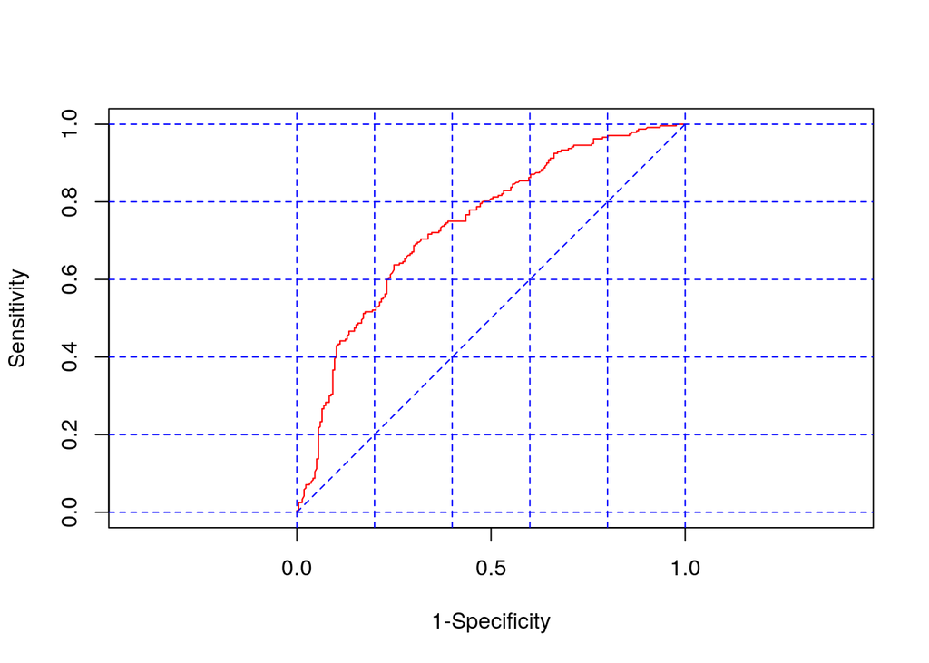

[output not shown]

[output cut: 795 more lines]

[output not shown]

```r
lroc(glm5)
```

```r
cat("\nTRAINING ----")
```

```
##
## TRAINING ----
```

```r
confusionMatrix(as.factor(ifelse(predict(glm5, type="response")>0.5,"Severe","Mild")), training$astma1)
```

```
## Confusion Matrix and Statistics
##
##           Reference
## Prediction Mild Severe
##     Mild    136     66
##     Severe   80    174
##
##                Accuracy : 0.6798
##                  95% CI : (0.6348, 0.7225)
##     No Information Rate : 0.5263
##     P-Value [Acc > NIR] : 1.975e-11
##
##                   Kappa : 0.3558
##
##  Mcnemar's Test P-Value : 0.282
##
##             Sensitivity : 0.6296
##             Specificity : 0.7250
##          Pos Pred Value : 0.6733
##          Neg Pred Value : 0.6850
##              Prevalence : 0.4737
##          Detection Rate : 0.2982
##    Detection Prevalence : 0.4430
##       Balanced Accuracy : 0.6773
##
##        'Positive' Class : Mild
##
```

```r
cat("\nTEST ------")
```

```
##
## TEST ------
```

```r
confusionMatrix(as.factor(ifelse(predict(glm5, type="response", newdata=test)>0.5,"Severe","Mild")), test$astma1)
```

```
## Confusion Matrix and Statistics
##
##           Reference
## Prediction Mild Severe
##     Mild     39     14
##     Severe   15     46
##
##                Accuracy : 0.7456
##                  95% CI : (0.6555, 0.8225)
##     No Information Rate : 0.5263
##     P-Value [Acc > NIR] : 1.264e-06
##
##                   Kappa : 0.4893
##
##  Mcnemar's Test P-Value : 1
##
##             Sensitivity : 0.7222
##             Specificity : 0.7667
##          Pos Pred Value : 0.7358
##          Neg Pred Value : 0.7541
##              Prevalence : 0.4737
##          Detection Rate : 0.3421
##    Detection Prevalence : 0.4649
##       Balanced Accuracy : 0.7444
##
##        'Positive' Class : Mild
##
```

```r
saveRDS(glm5, "glm5.RDS")


model <- train(astma1~., data=training, trControl=train_control, method="C5.0")
# summarize results
#plot(model$finalModel)
cat("\nTRAINING ----")
```

```
##
## TRAINING ----
```

```r
confusionMatrix(predict(model), training$astma1)
```

```
## Confusion Matrix and Statistics
##
##           Reference
## Prediction Mild Severe
##     Mild    132     48
##     Severe   84    192
##
##                Accuracy : 0.7105
##                  95% CI : (0.6665, 0.7518)
##     No Information Rate : 0.5263
##     P-Value [Acc > NIR] : 7.519e-16
##
##                   Kappa : 0.4146
##
##  Mcnemar's Test P-Value : 0.002316
##
##             Sensitivity : 0.6111
##             Specificity : 0.8000
##          Pos Pred Value : 0.7333
##          Neg Pred Value : 0.6957
##              Prevalence : 0.4737
##          Detection Rate : 0.2895
##    Detection Prevalence : 0.3947
##       Balanced Accuracy : 0.7056
##
##        'Positive' Class : Mild
##
```

```r
cat("\nTEST ------")
```

```
##
## TEST ------
```

```r
confusionMatrix(predict(model, newdata = test), test$astma1)
```

```
## Confusion Matrix and Statistics
##
##           Reference
## Prediction Mild Severe
##     Mild     33     11
##     Severe   21     49
##
##                Accuracy : 0.7193
##                  95% CI : (0.6274, 0.7994)
##     No Information Rate : 0.5263
##     P-Value [Acc > NIR] : 1.994e-05
##
##                   Kappa : 0.4318
##
##  Mcnemar's Test P-Value : 0.1116
##
##             Sensitivity : 0.6111
##             Specificity : 0.8167
##          Pos Pred Value : 0.7500
##          Neg Pred Value : 0.7000
##              Prevalence : 0.4737
##          Detection Rate : 0.2895
##    Detection Prevalence : 0.3860
##       Balanced Accuracy : 0.7139
##
##        'Positive' Class : Mild
##
```

```r
saveRDS(model, "model3.RDS")
```

# 10 ACT vs. SNPs

Podstawy:

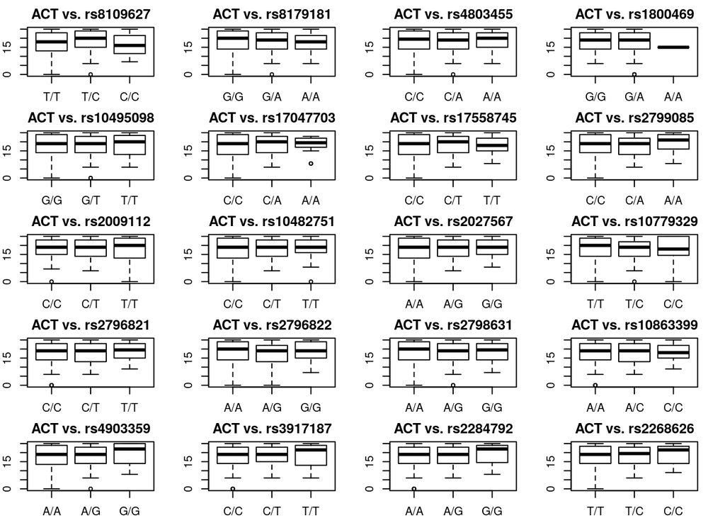

```r
colnames(carriers) = paste0(colnames(carriers),"_MAC")
ACT = as.numeric(clinical$Test.kontroli.astmy..ATC..wynik.surowy.w.pkt)

temp = cbind(ACT, dane_complete_genetics_factors)
temp = temp[complete.cases(temp),]

par(mfrow=c(5,4))
par(mar = rep(2, 4))
p = vector()
for(i in 2:length(colnames(temp))) {
  tempSNP = as.formula(paste0("ACT ~ ",colnames(temp)[i]))
  boxplot(tempSNP, data = temp, main = paste0("ACT vs. ",colnames(temp)[i]))
  tempK = kruskal.test(tempSNP, data = temp)
  p[colnames(temp)[i]] = tempK$p.value
}
```

```r
par(mfrow=c(1,1))
print(p)
```

```
##  rs8109627  rs8179181  rs4803455  rs1800469 rs10495098 rs17047703
## 0.01293616 0.52578841 0.75946725 0.77382665 0.92424765 0.67945311
## rs17558745  rs2799085  rs2009112 rs10482751  rs2027567 rs10779329
## 0.63854080 0.07194376 0.63840070 0.72607316 0.84529401 0.54625382
##  rs2796821  rs2796822  rs2798631 rs10863399  rs4903359  rs3917187
## 0.75495307 0.16434228 0.92971649 0.72234362 0.34302778 0.76985239
##  rs2284792  rs2268626
## 0.37116221 0.92701055
```

```r
print(p.adjust(p, method = "BH"))
```

```
##  rs8109627  rs8179181  rs4803455  rs1800469 rs10495098 rs17047703
##  0.2587232  0.9297165  0.9297165  0.9297165  0.9297165  0.9297165
## rs17558745  rs2799085  rs2009112 rs10482751  rs2027567 rs10779329
##  0.9297165  0.7194376  0.9297165  0.9297165  0.9297165  0.9297165
##  rs2796821  rs2796822  rs2798631 rs10863399  rs4903359  rs3917187
##  0.9297165  0.9297165  0.9297165  0.9297165  0.9297165  0.9297165
##  rs2284792  rs2268626
##  0.9297165  0.9297165
```

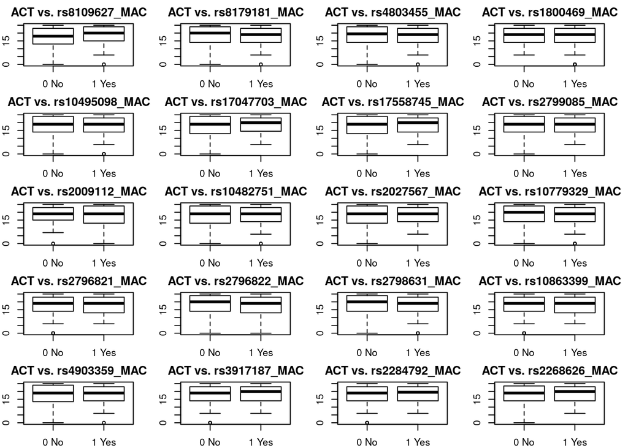

```r
temp = cbind(ACT, carriers)
temp = temp[complete.cases(temp),]

par(mfrow=c(5,4))
par(mar = rep(2, 4))
p = vector()
for(i in 2:length(colnames(temp))) {
  tempSNP = as.formula(paste0("ACT ~ ",colnames(temp)[i]))
  boxplot(tempSNP, data = temp, main = paste0("ACT vs. ",colnames(temp)[i]))
  tempK = wilcox.test(tempSNP, data = temp)
  p[colnames(temp)[i]] = tempK$p.value
}
```

```r
par(mfrow=c(1,1))
print(p)
```

```
##  rs8109627_MAC  rs8179181_MAC  rs4803455_MAC  rs1800469_MAC rs10495098_MAC
##     0.04246093     0.43329503     0.53952531     0.85186525     0.69427137
## rs17047703_MAC rs17558745_MAC  rs2799085_MAC  rs2009112_MAC rs10482751_MAC
##     0.44605793     0.67301754     0.54438829     0.67083051     0.86282693
##  rs2027567_MAC rs10779329_MAC  rs2796821_MAC  rs2796822_MAC  rs2798631_MAC
##     0.80615002     0.52297191     0.54937323     0.16275503     0.83600054
## rs10863399_MAC  rs4903359_MAC  rs3917187_MAC  rs2284792_MAC  rs2268626_MAC
##     0.43531545     0.91705126     0.48440841     0.68843363     0.89852713
```

```r
print(p.adjust(p, method = "BH"))
```

```
##  rs8109627_MAC  rs8179181_MAC  rs4803455_MAC  rs1800469_MAC rs10495098_MAC
##      0.8492186      0.9170513      0.9170513      0.9170513      0.9170513
## rs17047703_MAC rs17558745_MAC  rs2799085_MAC  rs2009112_MAC rs10482751_MAC
##      0.9170513      0.9170513      0.9170513      0.9170513      0.9170513
##  rs2027567_MAC rs10779329_MAC  rs2796821_MAC  rs2796822_MAC  rs2798631_MAC
##      0.9170513      0.9170513      0.9170513      0.9170513      0.9170513
## rs10863399_MAC  rs4903359_MAC  rs3917187_MAC  rs2284792_MAC  rs2268626_MAC
##      0.9170513      0.9170513      0.9170513      0.9170513      0.9170513
```

Regresja liniowa:

```r
library(lm.beta)
library(car)
ACT = as.numeric(clinical$Test.kontroli.astmy..ATC..wynik.surowy.w.pkt)

temp = cbind(ACT, dane_complete_genetics_factors)
temp = temp[complete.cases(temp),]
full.model <- lm(ACT ~., data = temp)
# RMSE
summary(full.model)
```

```
##
## Call:
## lm(formula = ACT ~ ., data = temp)
##
## Residuals:
##      Min       1Q   Median       3Q      Max
## -18.5395  -4.0957   0.7244   4.6026   9.1704
##
## Coefficients:
##               Estimate Std. Error t value Pr(>|t|)
## (Intercept)   17.71342    1.58102  11.204   <2e-16 ***
## rs8109627T/C   1.15524    0.66965   1.725   0.0853 .
## rs8109627C/C  -2.47053    1.47726  -1.672   0.0953 .
## rs8179181G/A  -0.26584    0.68980  -0.385   0.7002
## rs8179181A/A  -0.61208    1.21763  -0.503   0.6155
## rs4803455C/A  -0.19777    0.74284  -0.266   0.7902
## rs4803455A/A   0.05882    1.20419   0.049   0.9611
## rs1800469G/A   0.18988    0.81141   0.234   0.8151
## rs1800469A/A  -3.43646    6.53736  -0.526   0.5994
## rs10495098G/T -0.23828    0.78084  -0.305   0.7604
## rs10495098T/T -1.21570    1.05390  -1.154   0.2494
## rs17047703C/A  0.51894    1.12123   0.463   0.6437
## rs17047703A/A  1.29881    2.40218   0.541   0.5890
## rs17558745C/T  0.49774    1.01662   0.490   0.6247
## rs17558745T/T -0.11481    1.82232  -0.063   0.9498
## rs2799085C/A  -0.54686    0.91172  -0.600   0.5490
## rs2799085A/A   1.93695    1.50469   1.287   0.1988
## rs2009112C/T   0.57668    0.89749   0.643   0.5209
## rs2009112T/T   0.60058    1.19898   0.501   0.6167
## rs10482751C/T -0.29469    1.22495  -0.241   0.8100
## rs10482751T/T -1.17199    2.33780  -0.501   0.6164
## rs2027567A/G   0.52274    1.07175   0.488   0.6260
## rs2027567G/G   0.86193    2.23301   0.386   0.6997
## rs10779329T/C -0.42962    0.97370  -0.441   0.6593
## rs10779329C/C -0.20332    1.77857  -0.114   0.9090
## rs2796821C/T   0.21418    1.25711   0.170   0.8648
## rs2796821T/T   4.77578    3.80817   1.254   0.2106
## rs2796822A/G  -1.73081    1.34039  -1.291   0.1974
## rs2796822G/G  -0.57373    2.32000  -0.247   0.8048
## rs2798631A/G   1.27907    1.04354   1.226   0.2211
## rs2798631G/G   0.68609    1.50298   0.456   0.6483
## rs10863399A/C -0.78382    1.26070  -0.622   0.5345
## rs10863399C/C -6.35759    4.17865  -1.521   0.1290
## rs4903359A/G  -0.28317    0.85521  -0.331   0.7407
## rs4903359G/G   0.65435    2.83618   0.231   0.8177
## rs3917187C/T   1.95800    1.60811   1.218   0.2241
## rs3917187T/T  -4.05995    3.02558  -1.342   0.1804
## rs2284792A/G  -0.74877    1.60092  -0.468   0.6403
## rs2284792G/G   7.33446    3.95955   1.852   0.0648 .
## rs2268626T/C  -0.20679    1.02786  -0.201   0.8407
## rs2268626C/C  -3.36105    2.73649  -1.228   0.2201
## ---
## Signif. codes:  0 '***' 0.001 '**' 0.01 '*' 0.05 '.' 0.1 ' ' 1
##
## Residual standard error: 5.756 on 379 degrees of freedom
## Multiple R-squared:  0.08447,    Adjusted R-squared:  -0.01216
## F-statistic: 0.8741 on 40 and 379 DF,  p-value: 0.6904
```

```r
sqrt(mean(full.model$residuals^2))
```

```
## [1] 5.467368
```

```r
vif(full.model)
```

```
##                 GVIF Df GVIF^(1/(2*Df))
## rs8109627   1.449537  2        1.097254
## rs8179181   1.667377  2        1.136340
## rs4803455   2.748955  2        1.287632
## rs1800469   2.584801  2        1.267964
## rs10495098  2.270217  2        1.227487
## rs17047703  7.207323  2        1.638489
## rs17558745  5.716954  2        1.546291
## rs2799085   4.598896  2        1.464412
## rs2009112   3.158006  2        1.333071
## rs10482751 16.007484  2        2.000234
## rs2027567  10.230185  2        1.788426
## rs10779329  4.688512  2        1.471495
## rs2796821  24.052008  2        2.214562
## rs2796822  19.751643  2        2.108147
## rs2798631   7.722820  2        1.667032
## rs10863399 20.702965  2        2.133085
## rs4903359  10.354506  2        1.793834
## rs3917187  36.707488  2        2.461437
## rs2284792  66.987364  2        2.860871
## rs2268626   8.541940  2        1.709579
```

```r
step.model <- step(full.model, direction = "backward",
                      trace = F)
summary(lm.beta(step.model))
```

```
##
## Call:
## lm(formula = ACT ~ rs8109627 + rs2799085 + rs3917187 + rs2284792,
##     data = temp)
##
## Residuals:
##     Min      1Q  Median      3Q     Max
## -18.961  -4.135   1.000   4.865   9.933
##
## Coefficients:
##              Estimate Standardized Std. Error t value Pr(>|t|)
## (Intercept)  17.57017      0.00000    0.54900  32.004   <2e-16 ***
## rs8109627T/C  1.39051      0.11711    0.58100   2.393   0.0171 *
## rs8109627C/C -2.06833     -0.07523    1.36680  -1.513   0.1310
## rs2799085C/A -0.43472     -0.03791    0.59455  -0.731   0.4651
## rs2799085A/A  1.51001      0.08846    0.88382   1.709   0.0883 .
## rs3917187C/T  1.33525      0.11146    1.41992   0.940   0.3476
## rs3917187T/T -3.85590     -0.16262    2.71047  -1.423   0.1556
## rs2284792A/G -0.88332     -0.07489    1.40209  -0.630   0.5290
## rs2284792G/G  5.29066      0.21492    2.81947   1.876   0.0613 .
## ---
## Signif. codes:  0 '***' 0.001 '**' 0.01 '*' 0.05 '.' 0.1 ' ' 1
##
## Residual standard error: 5.628 on 411 degrees of freedom
## Multiple R-squared:  0.05058,    Adjusted R-squared:  0.0321
## F-statistic: 2.737 on 8 and 411 DF,  p-value: 0.005956
```

```r
# RMSE
sqrt(mean(step.model$residuals^2))
```

```
## [1] 5.567615
```

```r
vif(step.model)
```

```
##                GVIF Df GVIF^(1/(2*Df))
## rs8109627  1.049063  2        1.012046
## rs2799085  1.026703  2        1.006610
## rs3917187 25.195315  2        2.240423
## rs2284792 25.491117  2        2.246970
```

```r
# DLA MAC
temp = cbind(ACT, carriers)
temp = temp[complete.cases(temp),]
full.model <- lm(ACT ~., data = temp)
# RMSE
summary(full.model)
```

```
##
## Call:
## lm(formula = ACT ~ ., data = temp)
##
## Residuals:
##      Min       1Q   Median       3Q      Max
## -17.8535  -4.2527   0.8996   4.8037   9.6303
##
## Coefficients:
##                     Estimate Std. Error t value Pr(>|t|)
## (Intercept)         18.46408    1.39654  13.221   <2e-16 ***
## rs8109627_MAC1 Yes   1.03013    0.61486   1.675   0.0946 .
## rs8179181_MAC1 Yes  -0.07672    0.62328  -0.123   0.9021
## rs4803455_MAC1 Yes  -0.29483    0.72211  -0.408   0.6833
## rs1800469_MAC1 Yes   0.04992    0.62261   0.080   0.9361
## rs10495098_MAC1 Yes -0.51517    0.75065  -0.686   0.4929
## rs17047703_MAC1 Yes  0.65971    1.09017   0.605   0.5454
## rs17558745_MAC1 Yes  0.20358    0.98725   0.206   0.8367
## rs2799085_MAC1 Yes  -0.71835    0.87342  -0.822   0.4113
## rs2009112_MAC1 Yes  -0.23483    0.74681  -0.314   0.7533
## rs10482751_MAC1 Yes  0.04998    1.13050   0.044   0.9648
## rs2027567_MAC1 Yes   0.54608    1.02951   0.530   0.5961
## rs10779329_MAC1 Yes -0.13851    0.84528  -0.164   0.8699
## rs2796821_MAC1 Yes   0.76706    1.15551   0.664   0.5072
## rs2796822_MAC1 Yes  -2.14816    1.26482  -1.698   0.0902 .
## rs2798631_MAC1 Yes   1.34603    0.98025   1.373   0.1705
## rs10863399_MAC1 Yes -0.55351    1.13922  -0.486   0.6273
## rs4903359_MAC1 Yes  -0.33036    0.84293  -0.392   0.6953
## rs3917187_MAC1 Yes   1.75065    1.58158   1.107   0.2690
## rs2284792_MAC1 Yes  -0.51573    1.58814  -0.325   0.7456
## rs2268626_MAC1 Yes  -0.42647    0.98900  -0.431   0.6665
## ---
## Signif. codes:  0 '***' 0.001 '**' 0.01 '*' 0.05 '.' 0.1 ' ' 1
##
## Residual standard error: 5.769 on 399 degrees of freedom
## Multiple R-squared:  0.03163,    Adjusted R-squared:  -0.01691
## F-statistic: 0.6517 on 20 and 399 DF,  p-value: 0.8725
```

```r
sqrt(mean(full.model$residuals^2))
```

```
## [1] 5.622911
```

```r
vif(full.model)
```

```
##  rs8109627_MAC  rs8179181_MAC  rs4803455_MAC  rs1800469_MAC rs10495098_MAC
##       1.153689       1.216609       1.329379       1.187061       1.550987
## rs17047703_MAC rs17558745_MAC  rs2799085_MAC  rs2009112_MAC rs10482751_MAC
##       3.379170       2.999038       2.332046       1.407015       4.008682
##  rs2027567_MAC rs10779329_MAC  rs2796821_MAC  rs2796822_MAC  rs2798631_MAC
##       3.319345       2.222262       4.027518       4.825585       2.675194
## rs10863399_MAC  rs4903359_MAC  rs3917187_MAC  rs2284792_MAC  rs2268626_MAC
##       3.485371       2.239214       7.646789       7.815921       2.743018
```

```r
step.model <- step(full.model, direction = "backward",
                      trace = F)
summary(lm.beta(step.model))
```

```
##
## Call:
## lm(formula = ACT ~ rs8109627_MAC + rs2796822_MAC + rs2798631_MAC,
##     data = temp)
##
## Residuals:
##      Min       1Q   Median       3Q      Max
## -18.5727  -4.4612   0.9049   4.8094   8.9049
##
## Coefficients:
##                    Estimate Standardized Std. Error t value Pr(>|t|)
## (Intercept)        17.88811      0.00000    0.54480  32.834   <2e-16 ***
## rs8109627_MAC1 Yes  1.11149      0.09565    0.56465   1.968   0.0497 *
## rs2796822_MAC1 Yes -1.79302     -0.15341    0.89322  -2.007   0.0454 *
## rs2798631_MAC1 Yes  1.36612      0.11230    0.92932   1.470   0.1423
## ---
## Signif. codes:  0 '***' 0.001 '**' 0.01 '*' 0.05 '.' 0.1 ' ' 1
##
## Residual standard error: 5.686 on 416 degrees of freedom
## Multiple R-squared:  0.01931,    Adjusted R-squared:  0.01224
## F-statistic: 2.731 on 3 and 416 DF,  p-value: 0.04354
```

```r
# RMSE
sqrt(mean(step.model$residuals^2))
```

```
## [1] 5.658561
```

```r
vif(step.model)
```

```
## rs8109627_MAC rs2796822_MAC rs2798631_MAC
##      1.001651      2.477666      2.475366
```

Regresja liniowa z selekcją krokową wsteczną. Selekcja krokowa oparta o kryterium informacyjne Akaikego.

```r
step.model <- step(full.model, direction = "backward",
                      trace = F)
summary(lm.beta(step.model))
```

```
##
## Call:
## lm(formula = ACT ~ rs8109627_MAC + rs2796822_MAC + rs2798631_MAC,
##     data = temp)
##
## Residuals:
##      Min       1Q   Median       3Q      Max
## -18.5727  -4.4612   0.9049   4.8094   8.9049
##
## Coefficients:
##                    Estimate Standardized Std. Error t value Pr(>|t|)
## (Intercept)        17.88811      0.00000    0.54480  32.834   <2e-16 ***
## rs8109627_MAC1 Yes  1.11149      0.09565    0.56465   1.968   0.0497 *
## rs2796822_MAC1 Yes -1.79302     -0.15341    0.89322  -2.007   0.0454 *
## rs2798631_MAC1 Yes  1.36612      0.11230    0.92932   1.470   0.1423
## ---
## Signif. codes:  0 '***' 0.001 '**' 0.01 '*' 0.05 '.' 0.1 ' ' 1
##
## Residual standard error: 5.686 on 416 degrees of freedom
## Multiple R-squared:  0.01931,    Adjusted R-squared:  0.01224
## F-statistic: 2.731 on 3 and 416 DF,  p-value: 0.04354
```

```r
# RMSE
sqrt(mean(step.model$residuals^2))
```

```
## [1] 5.658561
```

```r
vif(step.model)
```

```
## rs8109627_MAC rs2796822_MAC rs2798631_MAC
##      1.001651      2.477666      2.475366
```

Spróbujmy zrobić drzewo:

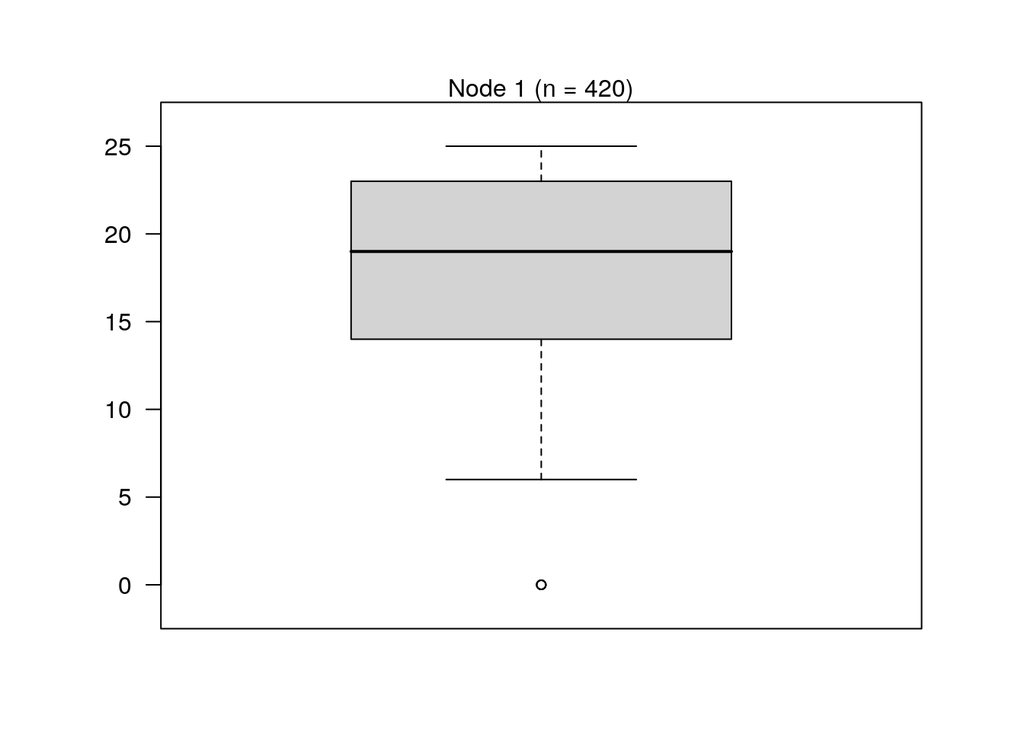

```r
library(caret)
train_control <- trainControl(method="LOOCV")
model = train(ACT ~ ., data = temp, trControl=train_control, method="ctree")
plot(model$finalModel)
```

```r
postResample(pred = predict(model, newdata = temp), obs = temp$ACT)
```

```
##     RMSE Rsquared      MAE
## 5.714010       NA 4.850726
```

Nie działa…

## 10.1 Dobrze kontrolowana

ACT >= 25 –> dobrze kontrolowana.

```r
library(DMwR)
temp = cbind(ACT, dane_complete_genetics_factors)
temp$ACT = as.factor(ifelse(temp$ACT >= 25, "1_Well", "0_Not"))
temp = temp[complete.cases(temp),]
temp = DMwR::SMOTE(ACT ~ ., temp, perc.over = 400)

glm3 <- glm(ACT~.,
            family=binomial, data=temp)
summary(glm3)
```

```
##
## Call:
## glm(formula = ACT ~ ., family = binomial, data = temp)
##
## Deviance Residuals:
##     Min       1Q   Median       3Q      Max
## -2.3179  -0.8988  -0.5885   0.9884   2.3588
##
## Coefficients:
##                 Estimate Std. Error z value Pr(>|z|)
## (Intercept)   -1.314e-01  3.673e-01  -0.358 0.720537
## rs8109627T/C   8.133e-01  1.655e-01   4.916 8.85e-07 ***
## rs8109627C/C  -2.860e-01  4.585e-01  -0.624 0.532882
## rs8179181G/A  -1.914e-01  1.729e-01  -1.107 0.268414
## rs8179181A/A  -5.393e-02  3.085e-01  -0.175 0.861206
## rs4803455C/A  -1.903e-01  1.849e-01  -1.029 0.303394
## rs4803455A/A  -4.197e-01  2.603e-01  -1.612 0.106887
## rs1800469G/A   3.293e-02  1.777e-01   0.185 0.852987
## rs1800469A/A   1.350e+00  2.444e+03   0.001 0.999559
## rs10495098G/T -5.878e-01  1.863e-01  -3.155 0.001605 **
## rs10495098T/T -6.279e-01  2.429e-01  -2.585 0.009733 **
## rs17047703C/A  4.810e-01  2.088e-01   2.304 0.021242 *
## rs17047703A/A -1.485e+01  4.615e+02  -0.032 0.974324
## rs17558745C/T -2.568e-01  1.956e-01  -1.313 0.189154
## rs17558745T/T -1.663e+00  6.177e-01  -2.693 0.007077 **
## rs2799085C/A  -1.813e-01  2.070e-01  -0.876 0.381234
## rs2799085A/A   7.536e-02  2.952e-01   0.255 0.798521
## rs2009112C/T  -3.902e-01  2.077e-01  -1.878 0.060332 .
## rs2009112T/T   2.648e-01  2.400e-01   1.103 0.269896
## rs10482751C/T  2.297e-01  2.344e-01   0.980 0.327176
## rs10482751T/T  1.120e+00  3.507e-01   3.195 0.001400 **
## rs2027567A/G  -2.987e-01  2.116e-01  -1.411 0.158138
## rs2027567G/G  -4.600e-01  3.891e-01  -1.182 0.237202
## rs10779329T/C -7.100e-01  2.015e-01  -3.524 0.000426 ***
## rs10779329C/C -1.004e-01  3.306e-01  -0.304 0.761271
## rs2796821C/T   1.729e-01  2.152e-01   0.803 0.421835
## rs2796821T/T  -2.128e-01  5.744e-01  -0.371 0.711004
## rs2796822A/G  -2.673e-01  2.345e-01  -1.140 0.254485
## rs2796822G/G   6.975e-01  3.233e-01   2.157 0.030997 *
## rs2798631A/G   4.244e-01  2.358e-01   1.800 0.071890 .
## rs2798631G/G   2.044e-01  2.779e-01   0.736 0.462019
## rs10863399A/C -2.980e-01  2.157e-01  -1.382 0.167067
## rs10863399C/C -3.688e-01  6.356e-01  -0.580 0.561784
## rs4903359A/G  -5.820e-01  2.006e-01  -2.901 0.003714 **
## rs4903359G/G   1.201e+00  4.105e-01   2.925 0.003445 **
## rs3917187C/T   2.187e-01  2.295e-01   0.953 0.340816
## rs3917187T/T   5.706e-02  4.460e-01   0.128 0.898211
## rs2284792A/G   2.131e-01  2.330e-01   0.914 0.360465
## rs2284792G/G  -1.238e+00  5.116e-01  -2.420 0.015519 *
## rs2268626T/C   3.694e-01  2.077e-01   1.779 0.075319 .
## rs2268626C/C   8.181e-03  5.235e-01   0.016 0.987531
## ---
## Signif. codes:  0 '***' 0.001 '**' 0.01 '*' 0.05 '.' 0.1 ' ' 1
##
## (Dispersion parameter for binomial family taken to be 1)
##
##     Null deviance: 1247.3  on 935  degrees of freedom
## Residual deviance: 1048.3  on 895  degrees of freedom
## AIC: 1130.3
##
## Number of Fisher Scoring iterations: 15
```

```r
#print(logistic.display(glm3))
roc = lroc(glm3)
```

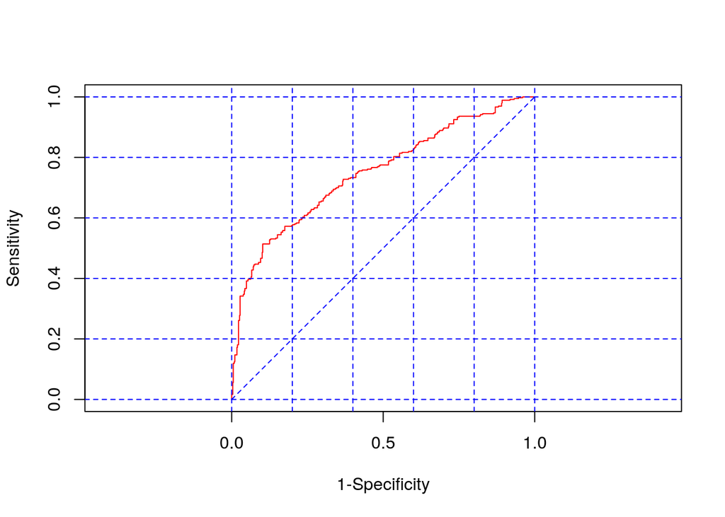

```r
roc$auc
```

```
## [1] 0.7486955
```

```r
glm4 = step(glm3)
```

```
## Start:  AIC=1130.28
## ACT ~ rs8109627 + rs8179181 + rs4803455 + rs1800469 + rs10495098 +
##     rs17047703 + rs17558745 + rs2799085 + rs2009112 + rs10482751 +
##     rs2027567 + rs10779329 + rs2796821 + rs2796822 + rs2798631 +
##     rs10863399 + rs4903359 + rs3917187 + rs2284792 + rs2268626
##
##              Df Deviance    AIC
## - rs1800469   2   1048.3 1126.3
## - rs3917187   2   1049.2 1127.2
## - rs2796821   2   1049.2 1127.2
## - rs8179181   2   1049.5 1127.5
## - rs2799085   2   1049.6 1127.6
## - rs10863399  2   1050.3 1128.3
## - rs4803455   2   1050.9 1128.9
## - rs2027567   2   1051.0 1129.0
## - rs2268626   2   1051.6 1129.6
## - rs2798631   2   1051.7 1129.7
## <none>            1048.3 1130.3
## - rs2284792   2   1057.2 1135.2
## - rs17558745  2   1057.5 1135.5
## - rs2009112   2   1059.1 1137.1
## - rs10482751  2   1059.1 1137.1
## - rs10495098  2   1059.8 1137.8
## - rs2796822   2   1061.2 1139.2
## - rs10779329  2   1062.5 1140.5
## - rs17047703  2   1062.9 1140.9
## - rs4903359   2   1074.0 1152.0
## - rs8109627   2   1075.5 1153.5
##
## Step:  AIC=1126.31
## ACT ~ rs8109627 + rs8179181 + rs4803455 + rs10495098 + rs17047703 +
##     rs17558745 + rs2799085 + rs2009112 + rs10482751 + rs2027567 +
##     rs10779329 + rs2796821 + rs2796822 + rs2798631 + rs10863399 +
##     rs4903359 + rs3917187 + rs2284792 + rs2268626
##
##              Df Deviance    AIC
## - rs3917187   2   1049.2 1123.2
## - rs2796821   2   1049.2 1123.2
## - rs8179181   2   1049.5 1123.5
## - rs2799085   2   1049.6 1123.6
```

[output cut: 165 more lines]

```
##
##              Df Deviance    AIC
## <none>            1060.5 1110.5
## - rs2027567   2   1064.9 1110.9
## - rs4803455   2   1066.3 1112.3
## - rs17558745  2   1069.7 1115.7
## - rs2009112   2   1071.2 1117.2
## - rs10779329  2   1072.2 1118.2
## - rs10495098  2   1073.1 1119.1
## - rs2796822   2   1074.6 1120.6
## - rs10482751  2   1075.0 1121.0
## - rs17047703  2   1077.1 1123.1
## - rs2284792   2   1080.9 1126.9
## - rs4903359   2   1087.4 1133.4
## - rs8109627   2   1088.7 1134.7
```

```r
summary(glm4)
```

```
##
## Call:
## glm(formula = ACT ~ rs8109627 + rs4803455 + rs10495098 + rs17047703 +
##     rs17558745 + rs2009112 + rs10482751 + rs2027567 + rs10779329 +
##     rs2796822 + rs4903359 + rs2284792, family = binomial, data = temp)
##
## Deviance Residuals:
##     Min       1Q   Median       3Q      Max
## -2.1415  -0.9072  -0.6130   0.9952   2.3135
##
## Coefficients:
##                Estimate Std. Error z value Pr(>|z|)
## (Intercept)    -0.06831    0.30434  -0.224 0.822416
## rs8109627T/C    0.80525    0.15760   5.109 3.23e-07 ***
## rs8109627C/C   -0.19619    0.44943  -0.437 0.662453
## rs4803455C/A   -0.25631    0.17707  -1.448 0.147749
## rs4803455A/A   -0.52584    0.22074  -2.382 0.017211 *
## rs10495098G/T  -0.61679    0.18210  -3.387 0.000706 ***
## rs10495098T/T  -0.59560    0.23542  -2.530 0.011409 *
## rs17047703C/A   0.52099    0.20513   2.540 0.011091 *
## rs17047703A/A -14.87866  453.52888  -0.033 0.973829
## rs17558745C/T  -0.28043    0.18911  -1.483 0.138096
## rs17558745T/T  -1.58721    0.60122  -2.640 0.008291 **
## rs2009112C/T   -0.38693    0.19934  -1.941 0.052257 .
## rs2009112T/T    0.24518    0.22978   1.067 0.285958
## rs10482751C/T   0.23068    0.21751   1.061 0.288886
## rs10482751T/T   1.20483    0.32600   3.696 0.000219 ***
## rs2027567A/G   -0.35779    0.20497  -1.746 0.080876 .
## rs2027567G/G   -0.56994    0.36874  -1.546 0.122185
## rs10779329T/C  -0.56743    0.18357  -3.091 0.001994 **
## rs10779329C/C   0.09406    0.29552   0.318 0.750269
## rs2796822A/G   -0.08162    0.18462  -0.442 0.658441
## rs2796822G/G    0.72063    0.24184   2.980 0.002884 **
## rs4903359A/G   -0.50122    0.18627  -2.691 0.007127 **
## rs4903359G/G    1.26664    0.39511   3.206 0.001347 **
## rs2284792A/G    0.48328    0.18865   2.562 0.010416 *
## rs2284792G/G   -1.08957    0.40020  -2.723 0.006478 **
## ---
## Signif. codes:  0 '***' 0.001 '**' 0.01 '*' 0.05 '.' 0.1 ' ' 1
##
## (Dispersion parameter for binomial family taken to be 1)
##
##     Null deviance: 1247.3  on 935  degrees of freedom
## Residual deviance: 1060.5  on 911  degrees of freedom
## AIC: 1110.5
##
## Number of Fisher Scoring iterations: 15
```

```r
#print(logistic.display(glm4))
roc = lroc(glm4)
```

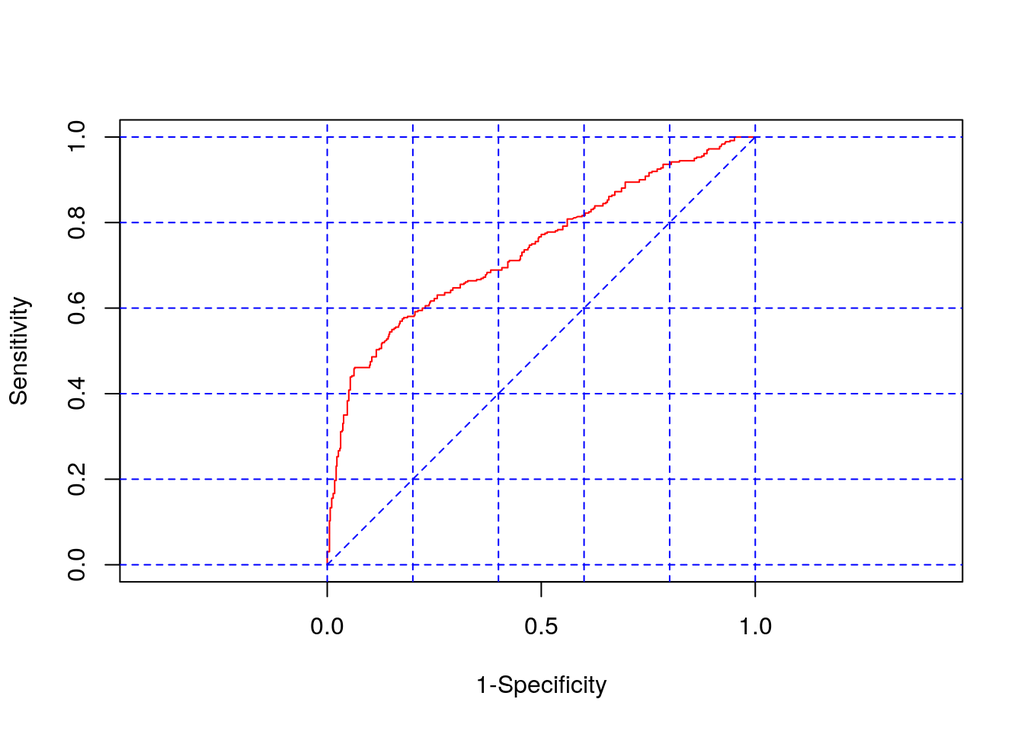

```r
roc$auc
```

```
## [1] 0.73886
```

```r
train_control <- trainControl(method="none")
model = train(ACT ~ ., data = temp, trControl=train_control, method="glmStepAIC", family = "binomial")
```

```
## Start:  AIC=1130.28
## .outcome ~ `rs8109627T/C` + `rs8109627C/C` + `rs8179181G/A` +
##     `rs8179181A/A` + `rs4803455C/A` + `rs4803455A/A` + `rs1800469G/A` +
##     `rs1800469A/A` + `rs10495098G/T` + `rs10495098T/T` + `rs17047703C/A` +
##     `rs17047703A/A` + `rs17558745C/T` + `rs17558745T/T` + `rs2799085C/A` +
##     `rs2799085A/A` + `rs2009112C/T` + `rs2009112T/T` + `rs10482751C/T` +
##     `rs10482751T/T` + `rs2027567A/G` + `rs2027567G/G` + `rs10779329T/C` +
##     `rs10779329C/C` + `rs2796821C/T` + `rs2796821T/T` + `rs2796822A/G` +
##     `rs2796822G/G` + `rs2798631A/G` + `rs2798631G/G` + `rs10863399A/C` +
##     `rs10863399C/C` + `rs4903359A/G` + `rs4903359G/G` + `rs3917187C/T` +
##     `rs3917187T/T` + `rs2284792A/G` + `rs2284792G/G` + `rs2268626T/C` +
##     `rs2268626C/C`
##
##                   Df Deviance    AIC
## - `rs1800469A/A`   1   1048.3 1128.3
## - `rs2268626C/C`   1   1048.3 1128.3
## - `rs3917187T/T`   1   1048.3 1128.3
## - `rs8179181A/A`   1   1048.3 1128.3
## - `rs1800469G/A`   1   1048.3 1128.3
## - `rs2799085A/A`   1   1048.3 1128.3
## - `rs10779329C/C`  1   1048.4 1128.4
## - `rs2796821T/T`   1   1048.4 1128.4
## - `rs10863399C/C`  1   1048.6 1128.6
## - `rs8109627C/C`   1   1048.7 1128.7
## - `rs2798631G/G`   1   1048.8 1128.8
## - `rs2796821C/T`   1   1048.9 1128.9
## - `rs2799085C/A`   1   1049.0 1129.0
## - `rs2284792A/G`   1   1049.1 1129.1
## - `rs3917187C/T`   1   1049.2 1129.2
## - `rs10482751C/T`  1   1049.2 1129.2
## - `rs4803455C/A`   1   1049.3 1129.3
## - `rs2009112T/T`   1   1049.5 1129.5
## - `rs8179181G/A`   1   1049.5 1129.5
## - `rs2796822A/G`   1   1049.6 1129.6
## - `rs2027567G/G`   1   1049.7 1129.7
## - `rs17558745C/T`  1   1050.0 1130.0
## - `rs10863399A/C`  1   1050.2 1130.2
## - `rs2027567A/G`   1   1050.3 1130.3
## <none>                 1048.3 1130.3
## - `rs4803455A/A`   1   1050.9 1130.9
```

[output cut: 879 more lines]

```
## - `rs2268626T/C`   1   1065.3 1103.3
## - `rs4803455A/A`   1   1067.2 1105.2
## - `rs10495098T/T`  1   1067.3 1105.3
## - `rs17047703C/A`  1   1067.9 1105.9
## - `rs17047703A/A`  1   1069.0 1107.0
## - `rs4903359A/G`   1   1070.5 1108.5
## - `rs2284792G/G`   1   1070.7 1108.7
## - `rs10482751T/T`  1   1071.1 1109.1
## - `rs4903359G/G`   1   1071.6 1109.6
## - `rs2009112C/T`   1   1071.7 1109.7
## - `rs17558745T/T`  1   1072.2 1110.2
## - `rs10495098G/T`  1   1072.6 1110.6
## - `rs10779329T/C`  1   1076.8 1114.8
## - `rs2796822G/G`   1   1077.1 1115.1
## - `rs8109627T/C`   1   1091.4 1129.4
```

```r
logistic.display(model$finalModel)
```

```
##
##                           OR  lower95ci upper95ci     Pr(>|Z|)
## `rs8109627T/C`  2.319171e+00 1.71127236 3.1430141 5.828667e-08
## `rs4803455C/A`  7.628586e-01 0.54015444 1.0773830 1.243439e-01
## `rs4803455A/A`  5.897361e-01 0.38325404 0.9074625 1.632525e-02
## `rs10495098G/T` 5.461033e-01 0.38260887 0.7794612 8.607962e-04
## `rs10495098T/T` 5.727335e-01 0.36477837 0.8992409 1.546191e-02
## `rs17047703C/A` 1.673850e+00 1.12579559 2.4887059 1.091283e-02
## `rs17047703A/A` 3.500510e-07 0.00000000       Inf 9.734126e-01
## `rs17558745C/T` 7.359208e-01 0.51143956 1.0589313 9.862532e-02
## `rs17558745T/T` 1.689126e-01 0.05184589 0.5503131 3.166557e-03
## `rs2009112C/T`  5.925143e-01 0.43000826 0.8164336 1.374565e-03
## `rs10482751T/T` 2.111074e+00 1.31466988 3.3899253 1.987096e-03
## `rs2027567A/G`  7.842569e-01 0.57150460 1.0762100 1.323005e-01
## `rs10779329T/C` 5.294641e-01 0.38373863 0.7305292 1.080701e-04
## `rs2796822G/G`  2.149451e+00 1.47062126 3.1416237 7.758931e-05
## `rs4903359A/G`  5.703417e-01 0.39466149 0.8242243 2.799242e-03
## `rs4903359G/G`  3.333997e+00 1.53843109 7.2252402 2.276258e-03
## `rs2284792A/G`  1.346804e+00 0.89951437 2.0165107 1.482516e-01
## `rs2284792G/G`  3.104222e-01 0.14215347 0.6778724 3.328629e-03
## `rs2268626T/C`  1.469691e+00 1.00475395 2.1497723 4.721061e-02
```

```r
confusionMatrix(predict(model, newdata = temp), reference = temp$ACT, positive = "1_Well")
```

```
## Confusion Matrix and Statistics
##
##           Reference
## Prediction 0_Not 1_Well
##     0_Not    496    183
##     1_Well    80    177
##
##                Accuracy : 0.719
##                  95% CI : (0.689, 0.7476)
##     No Information Rate : 0.6154
##     P-Value [Acc > NIR] : 1.782e-11
##
##                   Kappa : 0.3728
##
##  Mcnemar's Test P-Value : 3.183e-10
##
##             Sensitivity : 0.4917
##             Specificity : 0.8611
##          Pos Pred Value : 0.6887
##          Neg Pred Value : 0.7305
##              Prevalence : 0.3846
##          Detection Rate : 0.1891
##    Detection Prevalence : 0.2746
##       Balanced Accuracy : 0.6764
##
##        'Positive' Class : 1_Well
##
```

```r
temp = cbind(ACT, carriers)
temp$ACT = ifelse(temp$ACT >= 25, "1_Well", "0_Not")

temp = temp[complete.cases(temp),]
temp$ACT = as.factor(temp$ACT)
for(i in 1:ncol(temp)) { temp[,i] = as.factor(temp[,i])}
temp = SMOTE(ACT ~ ., temp, perc.over = 400)


glm3 <- glm(ACT~.,
            family=binomial, data=temp)
summary(glm3)
```

```
##
## Call:
## glm(formula = ACT ~ ., family = binomial, data = temp)
##
## Deviance Residuals:
##     Min       1Q   Median       3Q      Max
## -1.6173  -0.9537  -0.7549   1.1820   2.0391
##
## Coefficients:
##                     Estimate Std. Error z value Pr(>|z|)
## (Intercept)          0.33011    0.32693   1.010 0.312631
## rs8109627_MAC1 Yes   0.37774    0.14667   2.575 0.010013 *
## rs8179181_MAC1 Yes  -0.30086    0.15094  -1.993 0.046242 *
## rs4803455_MAC1 Yes  -0.25787    0.16460  -1.567 0.117186
## rs1800469_MAC1 Yes   0.11688    0.15071   0.775 0.438046
## rs10495098_MAC1 Yes -0.49540    0.16587  -2.987 0.002821 **
## rs17047703_MAC1 Yes -0.02025    0.19748  -0.103 0.918331
## rs17558745_MAC1 Yes -0.38530    0.18328  -2.102 0.035531 *
## rs2799085_MAC1 Yes  -0.11536    0.17914  -0.644 0.519590
## rs2009112_MAC1 Yes  -0.24984    0.16792  -1.488 0.136786
## rs10482751_MAC1 Yes  0.20142    0.19040   1.058 0.290103
## rs2027567_MAC1 Yes  -0.37801    0.18451  -2.049 0.040492 *
## rs10779329_MAC1 Yes -0.42300    0.17588  -2.405 0.016169 *
## rs2796821_MAC1 Yes   0.67167    0.19352   3.471 0.000519 ***
## rs2796822_MAC1 Yes   0.08201    0.21171   0.387 0.698490
## rs2798631_MAC1 Yes  -0.11381    0.19866  -0.573 0.566702
## rs10863399_MAC1 Yes -0.32747    0.20368  -1.608 0.107891
## rs4903359_MAC1 Yes  -0.31280    0.17525  -1.785 0.074283 .
## rs3917187_MAC1 Yes  -0.10967    0.20785  -0.528 0.597758
## rs2284792_MAC1 Yes   0.82773    0.20555   4.027 5.65e-05 ***
## rs2268626_MAC1 Yes  -0.31374    0.18926  -1.658 0.097369 .
## ---
## Signif. codes:  0 '***' 0.001 '**' 0.01 '*' 0.05 '.' 0.1 ' ' 1
##
## (Dispersion parameter for binomial family taken to be 1)
##
##     Null deviance: 1247.3  on 935  degrees of freedom
## Residual deviance: 1166.3  on 915  degrees of freedom
## AIC: 1208.3
##
## Number of Fisher Scoring iterations: 4
```

```r
#print(logistic.display(glm3))
roc = lroc(glm3)
```

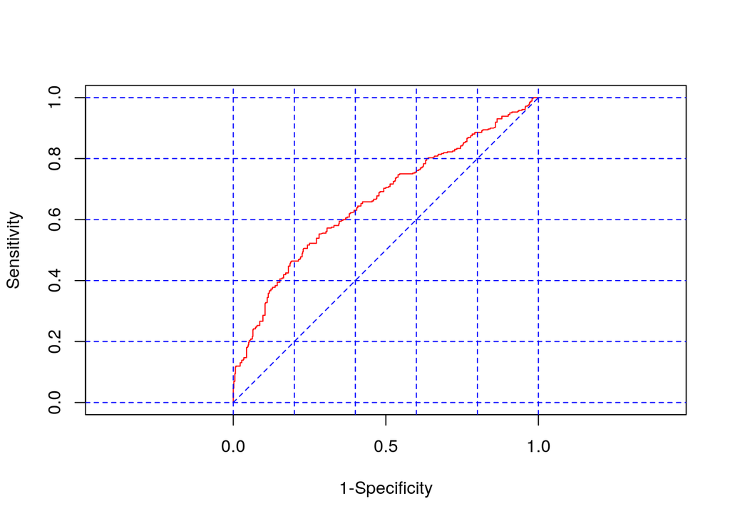

```r
roc$auc
```

```
## [1] 0.6614704
```

```r
glm4 = step(glm3)
```

```
## Start:  AIC=1208.35
## ACT ~ rs8109627_MAC + rs8179181_MAC + rs4803455_MAC + rs1800469_MAC +
##     rs10495098_MAC + rs17047703_MAC + rs17558745_MAC + rs2799085_MAC +
##     rs2009112_MAC + rs10482751_MAC + rs2027567_MAC + rs10779329_MAC +
##     rs2796821_MAC + rs2796822_MAC + rs2798631_MAC + rs10863399_MAC +
##     rs4903359_MAC + rs3917187_MAC + rs2284792_MAC + rs2268626_MAC
##
##                  Df Deviance    AIC
## - rs17047703_MAC  1   1166.4 1206.4
## - rs2796822_MAC   1   1166.5 1206.5
## - rs3917187_MAC   1   1166.6 1206.6
## - rs2798631_MAC   1   1166.7 1206.7
## - rs2799085_MAC   1   1166.8 1206.8
## - rs1800469_MAC   1   1167.0 1207.0
## - rs10482751_MAC  1   1167.5 1207.5
## <none>                1166.3 1208.3
## - rs2009112_MAC   1   1168.6 1208.6
## - rs4803455_MAC   1   1168.8 1208.8
## - rs10863399_MAC  1   1169.0 1209.0
## - rs2268626_MAC   1   1169.1 1209.1
## - rs4903359_MAC   1   1169.6 1209.6
## - rs8179181_MAC   1   1170.3 1210.3
## - rs2027567_MAC   1   1170.6 1210.6
## - rs17558745_MAC  1   1170.8 1210.8
## - rs10779329_MAC  1   1172.2 1212.2
## - rs8109627_MAC   1   1173.0 1213.0
## - rs10495098_MAC  1   1175.3 1215.3
## - rs2796821_MAC   1   1178.5 1218.5
## - rs2284792_MAC   1   1183.0 1223.0
##
## Step:  AIC=1206.36
## ACT ~ rs8109627_MAC + rs8179181_MAC + rs4803455_MAC + rs1800469_MAC +
##     rs10495098_MAC + rs17558745_MAC + rs2799085_MAC + rs2009112_MAC +
##     rs10482751_MAC + rs2027567_MAC + rs10779329_MAC + rs2796821_MAC +
##     rs2796822_MAC + rs2798631_MAC + rs10863399_MAC + rs4903359_MAC +
##     rs3917187_MAC + rs2284792_MAC + rs2268626_MAC
##
##                  Df Deviance    AIC
## - rs2796822_MAC   1   1166.5 1204.5
## - rs3917187_MAC   1   1166.6 1204.6
```

[output cut: 152 more lines]

```
##                  Df Deviance    AIC
## <none>                1168.9 1196.9
## - rs2009112_MAC   1   1171.1 1197.1
## - rs10863399_MAC  1   1171.8 1197.8
## - rs2268626_MAC   1   1172.1 1198.1
## - rs4803455_MAC   1   1172.6 1198.6
## - rs2027567_MAC   1   1173.0 1199.0
## - rs4903359_MAC   1   1173.2 1199.2
## - rs8179181_MAC   1   1173.3 1199.3
## - rs10779329_MAC  1   1175.8 1201.8
## - rs8109627_MAC   1   1176.1 1202.1
## - rs17558745_MAC  1   1177.2 1203.2
## - rs10495098_MAC  1   1178.4 1204.4
## - rs2796821_MAC   1   1182.7 1208.7
## - rs2284792_MAC   1   1187.3 1213.3
```

```r
summary(glm4)
```

```
##
## Call:
## glm(formula = ACT ~ rs8109627_MAC + rs8179181_MAC + rs4803455_MAC +
##     rs10495098_MAC + rs17558745_MAC + rs2009112_MAC + rs2027567_MAC +
##     rs10779329_MAC + rs2796821_MAC + rs10863399_MAC + rs4903359_MAC +
##     rs2284792_MAC + rs2268626_MAC, family = binomial, data = temp)
##
## Deviance Residuals:
##     Min       1Q   Median       3Q      Max
## -1.6066  -0.9539  -0.7643   1.1978   2.0669
##
## Coefficients:
##                     Estimate Std. Error z value Pr(>|z|)
## (Intercept)           0.3970     0.2702   1.469 0.141705
## rs8109627_MAC1 Yes    0.3891     0.1457   2.670 0.007574 **
## rs8179181_MAC1 Yes   -0.3141     0.1495  -2.100 0.035710 *
## rs4803455_MAC1 Yes   -0.3019     0.1574  -1.918 0.055117 .
## rs10495098_MAC1 Yes  -0.4862     0.1581  -3.076 0.002101 **
## rs17558745_MAC1 Yes  -0.4370     0.1522  -2.870 0.004099 **
## rs2009112_MAC1 Yes   -0.2356     0.1608  -1.465 0.142858
## rs2027567_MAC1 Yes   -0.3007     0.1492  -2.015 0.043928 *
## rs10779329_MAC1 Yes  -0.3981     0.1533  -2.596 0.009421 **
## rs2796821_MAC1 Yes    0.6762     0.1838   3.680 0.000234 ***
## rs10863399_MAC1 Yes  -0.3311     0.1945  -1.702 0.088694 .
## rs4903359_MAC1 Yes   -0.3404     0.1647  -2.067 0.038776 *
## rs2284792_MAC1 Yes    0.7805     0.1843   4.235 2.28e-05 ***
## rs2268626_MAC1 Yes   -0.3298     0.1849  -1.784 0.074423 .
## ---
## Signif. codes:  0 '***' 0.001 '**' 0.01 '*' 0.05 '.' 0.1 ' ' 1
##
## (Dispersion parameter for binomial family taken to be 1)
##
##     Null deviance: 1247.3  on 935  degrees of freedom
## Residual deviance: 1168.9  on 922  degrees of freedom
## AIC: 1196.9
##
## Number of Fisher Scoring iterations: 4
```

```r
#print(logistic.display(glm4))
roc = lroc(glm4)
```

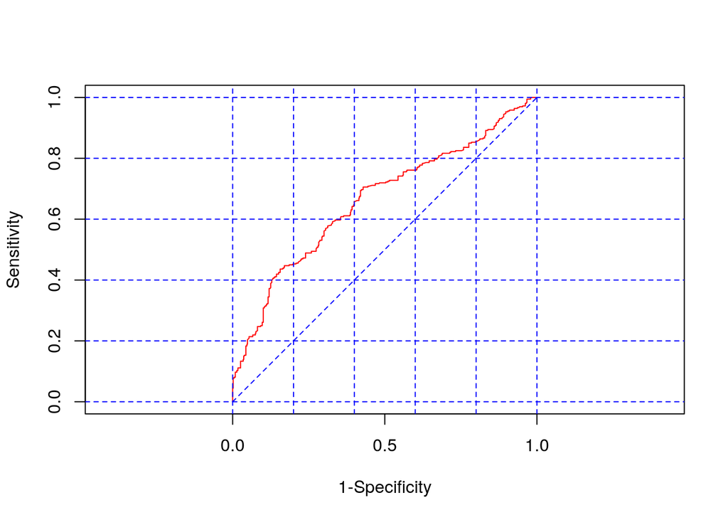

```r
roc$auc
```

```
## [1] 0.6611015
```

```r
train_control <- trainControl(method="none")
model = train(ACT ~ ., data = temp, trControl=train_control, method="glmStepAIC", family = "binomial")
```

```
## Start:  AIC=1208.35
## .outcome ~ `rs8109627_MAC1 Yes` + `rs8179181_MAC1 Yes` + `rs4803455_MAC1 Yes` +
##     `rs1800469_MAC1 Yes` + `rs10495098_MAC1 Yes` + `rs17047703_MAC1 Yes` +
##     `rs17558745_MAC1 Yes` + `rs2799085_MAC1 Yes` + `rs2009112_MAC1 Yes` +
##     `rs10482751_MAC1 Yes` + `rs2027567_MAC1 Yes` + `rs10779329_MAC1 Yes` +
##     `rs2796821_MAC1 Yes` + `rs2796822_MAC1 Yes` + `rs2798631_MAC1 Yes` +
##     `rs10863399_MAC1 Yes` + `rs4903359_MAC1 Yes` + `rs3917187_MAC1 Yes` +
##     `rs2284792_MAC1 Yes` + `rs2268626_MAC1 Yes`
##
##                         Df Deviance    AIC
## - `rs17047703_MAC1 Yes`  1   1166.4 1206.4
## - `rs2796822_MAC1 Yes`   1   1166.5 1206.5
## - `rs3917187_MAC1 Yes`   1   1166.6 1206.6
## - `rs2798631_MAC1 Yes`   1   1166.7 1206.7
## - `rs2799085_MAC1 Yes`   1   1166.8 1206.8
## - `rs1800469_MAC1 Yes`   1   1167.0 1207.0
## - `rs10482751_MAC1 Yes`  1   1167.5 1207.5
## <none>                       1166.3 1208.3
## - `rs2009112_MAC1 Yes`   1   1168.6 1208.6
## - `rs4803455_MAC1 Yes`   1   1168.8 1208.8
## - `rs10863399_MAC1 Yes`  1   1169.0 1209.0
## - `rs2268626_MAC1 Yes`   1   1169.1 1209.1
## - `rs4903359_MAC1 Yes`   1   1169.6 1209.6
## - `rs8179181_MAC1 Yes`   1   1170.3 1210.3
## - `rs2027567_MAC1 Yes`   1   1170.6 1210.6
## - `rs17558745_MAC1 Yes`  1   1170.8 1210.8
## - `rs10779329_MAC1 Yes`  1   1172.2 1212.2
## - `rs8109627_MAC1 Yes`   1   1173.0 1213.0
## - `rs10495098_MAC1 Yes`  1   1175.3 1215.3
## - `rs2796821_MAC1 Yes`   1   1178.5 1218.5
## - `rs2284792_MAC1 Yes`   1   1183.0 1223.0
##
## Step:  AIC=1206.36
## .outcome ~ `rs8109627_MAC1 Yes` + `rs8179181_MAC1 Yes` + `rs4803455_MAC1 Yes` +
##     `rs1800469_MAC1 Yes` + `rs10495098_MAC1 Yes` + `rs17558745_MAC1 Yes` +
##     `rs2799085_MAC1 Yes` + `rs2009112_MAC1 Yes` + `rs10482751_MAC1 Yes` +
##     `rs2027567_MAC1 Yes` + `rs10779329_MAC1 Yes` + `rs2796821_MAC1 Yes` +
##     `rs2796822_MAC1 Yes` + `rs2798631_MAC1 Yes` + `rs10863399_MAC1 Yes` +
##     `rs4903359_MAC1 Yes` + `rs3917187_MAC1 Yes` + `rs2284792_MAC1 Yes` +
##     `rs2268626_MAC1 Yes`
```

[output cut: 163 more lines]

```
##                         Df Deviance    AIC
## <none>                       1168.9 1196.9
## - `rs2009112_MAC1 Yes`   1   1171.1 1197.1
## - `rs10863399_MAC1 Yes`  1   1171.8 1197.8
## - `rs2268626_MAC1 Yes`   1   1172.1 1198.1
## - `rs4803455_MAC1 Yes`   1   1172.6 1198.6
## - `rs2027567_MAC1 Yes`   1   1173.0 1199.0
## - `rs4903359_MAC1 Yes`   1   1173.2 1199.2
## - `rs8179181_MAC1 Yes`   1   1173.3 1199.3
## - `rs10779329_MAC1 Yes`  1   1175.8 1201.8
## - `rs8109627_MAC1 Yes`   1   1176.1 1202.1
## - `rs17558745_MAC1 Yes`  1   1177.2 1203.2
## - `rs10495098_MAC1 Yes`  1   1178.4 1204.4
## - `rs2796821_MAC1 Yes`   1   1182.7 1208.7
## - `rs2284792_MAC1 Yes`   1   1187.3 1213.3
```

```r
logistic.display(model$finalModel)
```

```
##
##                              OR lower95ci upper95ci     Pr(>|Z|)
## `rs8109627_MAC1 Yes`  1.4757251 1.1090888 1.9635620 7.574183e-03
## `rs8179181_MAC1 Yes`  0.7304810 0.5449112 0.9792466 3.571021e-02
## `rs4803455_MAC1 Yes`  0.7394319 0.5431559 1.0066348 5.511744e-02
## `rs10495098_MAC1 Yes` 0.6149851 0.4511447 0.8383267 2.100809e-03
## `rs17558745_MAC1 Yes` 0.6460032 0.4793593 0.8705790 4.098985e-03
## `rs2009112_MAC1 Yes`  0.7900859 0.5764990 1.0828046 1.428578e-01
## `rs2027567_MAC1 Yes`  0.7403198 0.5525748 0.9918539 4.392834e-02
## `rs10779329_MAC1 Yes` 0.6715985 0.4972768 0.9070292 9.420945e-03
## `rs2796821_MAC1 Yes`  1.9664779 1.3716801 2.8191962 2.336161e-04
## `rs10863399_MAC1 Yes` 0.7181097 0.4904748 1.0513925 8.869448e-02
## `rs4903359_MAC1 Yes`  0.7114986 0.5151967 0.9825959 3.877567e-02
## `rs2284792_MAC1 Yes`  2.1825396 1.5208863 3.1320418 2.283663e-05
## `rs2268626_MAC1 Yes`  0.7190727 0.5005167 1.0330635 7.442341e-02
```

```r
confusionMatrix(predict(model, newdata = temp), reference = temp$ACT, positive = "1_Well")
```

```
## Confusion Matrix and Statistics
##
##           Reference
## Prediction 0_Not 1_Well
##     0_Not    511    244
##     1_Well    65    116
##
##                Accuracy : 0.6699
##                  95% CI : (0.6387, 0.7)
##     No Information Rate : 0.6154
##     P-Value [Acc > NIR] : 0.0003085
##
##                   Kappa : 0.2309
##
##  Mcnemar's Test P-Value : < 2.2e-16
##
##             Sensitivity : 0.3222
##             Specificity : 0.8872
##          Pos Pred Value : 0.6409
##          Neg Pred Value : 0.6768
##              Prevalence : 0.3846
##          Detection Rate : 0.1239
##    Detection Prevalence : 0.1934
##       Balanced Accuracy : 0.6047
##
##        'Positive' Class : 1_Well
##
```

## 10.2 Jakkolwiek kontrolowana

ACT >= 20 –> jakkolwiek kontrolowana.

```r
temp = cbind(ACT, dane_complete_genetics_factors)
temp$ACT = as.factor(ifelse(as.numeric(temp$ACT) >= 20, "1_OK", "0_Not"))
temp = temp[complete.cases(temp),]
temp = DMwR::SMOTE(ACT ~ ., temp, perc.over = 400)

glm3 <- glm(ACT~.,
            family=binomial, data=temp)
summary(glm3)
```

```
##
## Call:
## glm(formula = ACT ~ ., family = binomial, data = temp)
##
## Deviance Residuals:
##     Min       1Q   Median       3Q      Max
## -1.6261  -0.9375  -0.6815   1.1215   2.4044
##
## Coefficients:
##                Estimate Std. Error z value Pr(>|z|)
## (Intercept)    -0.23881    0.20663  -1.156 0.247789
## rs8109627T/C    0.39018    0.09521   4.098 4.16e-05 ***
## rs8109627C/C   -0.39056    0.21490  -1.817 0.069149 .
## rs8179181G/A   -0.34940    0.10152  -3.442 0.000578 ***
## rs8179181A/A   -0.21423    0.16331  -1.312 0.189593
## rs4803455C/A   -0.29913    0.10771  -2.777 0.005485 **
## rs4803455A/A   -0.10124    0.14492  -0.699 0.484809
## rs1800469G/A   -0.12275    0.10465  -1.173 0.240819
## rs1800469A/A  -14.67317  312.09715  -0.047 0.962501
## rs10495098G/T  -0.27280    0.10807  -2.524 0.011592 *
## rs10495098T/T   0.16997    0.13707   1.240 0.214944
## rs17047703C/A   0.67571    0.11472   5.890 3.86e-09 ***
## rs17047703A/A   1.02188    0.29393   3.477 0.000508 ***
## rs17558745C/T   0.15300    0.11091   1.380 0.167731
## rs17558745T/T  -0.65117    0.22110  -2.945 0.003228 **
## rs2799085C/A   -0.19570    0.11458  -1.708 0.087643 .
## rs2799085A/A    0.65208    0.16479   3.957 7.59e-05 ***
## rs2009112C/T   -0.16781    0.11695  -1.435 0.151330
## rs2009112T/T   -0.10389    0.14414  -0.721 0.471084
## rs10482751C/T  -0.19769    0.12495  -1.582 0.113625
## rs10482751T/T  -0.44201    0.21410  -2.065 0.038966 *
## rs2027567A/G    0.27075    0.11927   2.270 0.023206 *
## rs2027567G/G    0.28979    0.21730   1.334 0.182326
## rs10779329T/C  -0.08232    0.10743  -0.766 0.443516
## rs10779329C/C  -0.27631    0.20459  -1.351 0.176832
## rs2796821C/T   -0.22082    0.11833  -1.866 0.062028 .
## rs2796821T/T    0.77977    0.36585   2.131 0.033056 *
## rs2796822A/G   -0.33752    0.13226  -2.552 0.010715 *
## rs2796822G/G   -0.28978    0.19340  -1.498 0.134049
## rs2798631A/G   -0.21816    0.12858  -1.697 0.089747 .
## rs2798631G/G    0.16227    0.17220   0.942 0.346016
## rs10863399A/C   0.47803    0.12489   3.828 0.000129 ***
## rs10863399C/C  -1.02893    0.39316  -2.617 0.008868 **
## rs4903359A/G   -0.25532    0.10992  -2.323 0.020194 *
## rs4903359G/G    0.66460    0.24759   2.684 0.007269 **
## rs3917187C/T    0.29285    0.12918   2.267 0.023395 *
## rs3917187T/T   -0.01872    0.24962  -0.075 0.940223
## rs2284792A/G   -0.01896    0.12596  -0.151 0.880339
## rs2284792G/G    0.81288    0.25710   3.162 0.001568 **
## rs2268626T/C    0.39809    0.11300   3.523 0.000427 ***
## rs2268626C/C    0.04344    0.26892   0.162 0.871668
## ---
## Signif. codes:  0 '***' 0.001 '**' 0.01 '*' 0.05 '.' 0.1 ' ' 1
##
## (Dispersion parameter for binomial family taken to be 1)
##
##     Null deviance: 3551.3  on 2664  degrees of freedom
## Residual deviance: 3188.5  on 2624  degrees of freedom
## AIC: 3270.5
##
## Number of Fisher Scoring iterations: 13
```

```r
print(logistic.display(glm3))
```

```
##
## Logistic regression predicting ACT : 1_OK vs 0_Not
##
##                      crude OR(95%CI)
## rs8109627: ref.=T/T
##    T/C               1.51 (1.28,1.78)
##    C/C               0.9 (0.62,1.29)
##
## rs8179181: ref.=G/G
##    G/A               0.8 (0.68,0.95)
##    A/A               0.91 (0.69,1.21)
##
## rs4803455: ref.=C/C
##    C/A               0.73 (0.6,0.88)
##    A/A               1.03 (0.83,1.27)
##
## rs1800469: ref.=G/G
##    G/A               0.82 (0.7,0.95)
##    A/A               0 (0,2.45467334473763e+155)
##
## rs10495098: ref.=G/G
##    G/T               0.92 (0.76,1.1)
##    T/T               1.6 (1.29,1.98)
##
## rs17047703: ref.=C/C
##    C/A               1.83 (1.54,2.16)
##    A/A               1.62 (1.1,2.4)
##
## rs17558745: ref.=C/C
##    C/T               1.51 (1.28,1.79)
##    T/T               0.91 (0.66,1.25)
##
## rs2799085: ref.=C/C
##    C/A               0.82 (0.69,0.98)
##    A/A               2.12 (1.67,2.68)
##
## rs2009112: ref.=C/C
##    C/T               0.7 (0.58,0.84)
##    T/T               0.93 (0.76,1.15)
##
```

[output cut: 194 more lines]

```
## rs3917187: ref.=C/C  0.056
##    C/T
##    T/T
##
## rs2284792: ref.=A/A  0.004
##    A/G
##    G/G
##
## rs2268626: ref.=T/T  0.002
##    T/C
##    C/C
##
## Log-likelihood = -1594.2281
## No. of observations = 2665
## AIC value = 3270.4561
```

```r
roc = lroc(glm3)
```

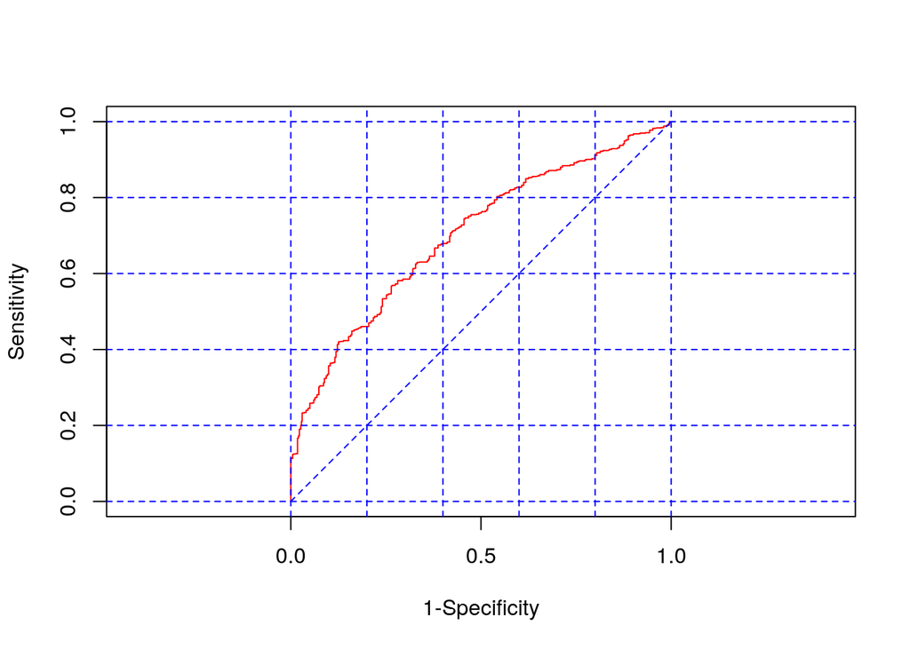

```r
roc$auc
```

```
## [1] 0.7009682
```

```r
glm4 = step(glm3)
```

```
## Start:  AIC=3270.46
## ACT ~ rs8109627 + rs8179181 + rs4803455 + rs1800469 + rs10495098 +
##     rs17047703 + rs17558745 + rs2799085 + rs2009112 + rs10482751 +
##     rs2027567 + rs10779329 + rs2796821 + rs2796822 + rs2798631 +
##     rs10863399 + rs4903359 + rs3917187 + rs2284792 + rs2268626
##
##              Df Deviance    AIC
## - rs10779329  2   3190.4 3268.4
## - rs2009112   2   3190.5 3268.5
## <none>            3188.5 3270.5
## - rs10482751  2   3193.5 3271.5
## - rs2027567   2   3194.1 3272.1
## - rs3917187   2   3194.2 3272.2
## - rs2796822   2   3195.2 3273.2
## - rs2798631   2   3195.2 3273.2
## - rs4803455   2   3197.1 3275.1
## - rs2796821   2   3197.8 3275.8
## - rs1800469   2   3199.3 3277.3
## - rs2284792   2   3199.5 3277.5
## - rs8179181   2   3200.4 3278.4
## - rs2268626   2   3201.4 3279.4
## - rs17558745  2   3202.8 3280.8
## - rs10495098  2   3204.2 3282.2
## - rs4903359   2   3205.8 3283.8
## - rs8109627   2   3212.3 3290.3
## - rs10863399  2   3213.3 3291.3
## - rs2799085   2   3222.1 3300.1
## - rs17047703  2   3228.7 3306.7
##
## Step:  AIC=3268.4
## ACT ~ rs8109627 + rs8179181 + rs4803455 + rs1800469 + rs10495098 +
##     rs17047703 + rs17558745 + rs2799085 + rs2009112 + rs10482751 +
##     rs2027567 + rs2796821 + rs2796822 + rs2798631 + rs10863399 +
##     rs4903359 + rs3917187 + rs2284792 + rs2268626
##
##              Df Deviance    AIC
## - rs2009112   2   3192.2 3266.2
## <none>            3190.4 3268.4
## - rs3917187   2   3196.2 3270.2
## - rs2027567   2   3196.5 3270.5
```

[output cut: 28 more lines]

```
## - rs10482751  2   3198.9 3268.9
## - rs4803455   2   3200.8 3270.8
## - rs2796822   2   3201.1 3271.1
## - rs2796821   2   3202.3 3272.3
## - rs2284792   2   3203.2 3273.2
## - rs1800469   2   3203.9 3273.9
## - rs8179181   2   3204.5 3274.5
## - rs2268626   2   3205.3 3275.3
## - rs17558745  2   3206.0 3276.0
## - rs10495098  2   3207.5 3277.5
## - rs4903359   2   3209.9 3279.9
## - rs8109627   2   3215.5 3285.5
## - rs10863399  2   3219.1 3289.1
## - rs17047703  2   3232.4 3302.4
## - rs2799085   2   3232.8 3302.8
```

```r
summary(glm4)
```

```
##
## Call:
## glm(formula = ACT ~ rs8109627 + rs8179181 + rs4803455 + rs1800469 +
##     rs10495098 + rs17047703 + rs17558745 + rs2799085 + rs10482751 +
##     rs2027567 + rs2796821 + rs2796822 + rs2798631 + rs10863399 +
##     rs4903359 + rs3917187 + rs2284792 + rs2268626, family = binomial,
##     data = temp)
##
## Deviance Residuals:
##     Min       1Q   Median       3Q      Max
## -1.6633  -0.9175  -0.6885   1.1365   2.4202
##
## Coefficients:
##                Estimate Std. Error z value Pr(>|z|)
## (Intercept)    -0.38355    0.17691  -2.168 0.030159 *
## rs8109627T/C    0.38658    0.09489   4.074 4.63e-05 ***
## rs8109627C/C   -0.37719    0.21425  -1.761 0.078321 .
## rs8179181G/A   -0.35324    0.10121  -3.490 0.000483 ***
## rs8179181A/A   -0.19789    0.16283  -1.215 0.224236
## rs4803455C/A   -0.29795    0.10751  -2.771 0.005581 **
## rs4803455A/A   -0.10232    0.14429  -0.709 0.478241
## rs1800469G/A   -0.10988    0.10401  -1.056 0.290753
## rs1800469A/A  -14.82042  312.09713  -0.047 0.962125
## rs10495098G/T  -0.27971    0.10758  -2.600 0.009319 **
## rs10495098T/T   0.14835    0.13535   1.096 0.273049
## rs17047703C/A   0.67751    0.11459   5.913 3.37e-09 ***
## rs17047703A/A   1.00131    0.29299   3.418 0.000632 ***
## rs17558745C/T   0.16547    0.11067   1.495 0.134883
## rs17558745T/T  -0.61654    0.21932  -2.811 0.004936 **
## rs2799085C/A   -0.19238    0.11171  -1.722 0.085047 .
## rs2799085A/A    0.71167    0.15838   4.493 7.01e-06 ***
## rs10482751C/T  -0.21379    0.12032  -1.777 0.075598 .
## rs10482751T/T  -0.47841    0.20106  -2.380 0.017336 *
## rs2027567A/G    0.26951    0.11896   2.266 0.023479 *
## rs2027567G/G    0.34469    0.21512   1.602 0.109085
## rs2796821C/T   -0.21997    0.11761  -1.870 0.061444 .
## rs2796821T/T    0.82663    0.36442   2.268 0.023307 *
## rs2796822A/G   -0.35796    0.12616  -2.837 0.004548 **
## rs2796822G/G   -0.36428    0.18377  -1.982 0.047455 *
## rs2798631A/G   -0.24261    0.12789  -1.897 0.057819 .
## rs2798631G/G    0.11532    0.16879   0.683 0.494473
## rs10863399A/C   0.51461    0.11943   4.309 1.64e-05 ***
## rs10863399C/C  -0.93442    0.38704  -2.414 0.015765 *
## rs4903359A/G   -0.24602    0.10965  -2.244 0.024851 *
## rs4903359G/G    0.69609    0.24697   2.819 0.004824 **
## rs3917187C/T    0.29881    0.12910   2.315 0.020633 *
## rs3917187T/T   -0.00800    0.24921  -0.032 0.974391
## rs2284792A/G   -0.01244    0.12555  -0.099 0.921058
## rs2284792G/G    0.81671    0.25758   3.171 0.001521 **
## rs2268626T/C    0.39850    0.11276   3.534 0.000409 ***
## rs2268626C/C    0.02485    0.26928   0.092 0.926463
## ---
## Signif. codes:  0 '***' 0.001 '**' 0.01 '*' 0.05 '.' 0.1 ' ' 1
##
## (Dispersion parameter for binomial family taken to be 1)
##
##     Null deviance: 3551.3  on 2664  degrees of freedom
## Residual deviance: 3192.2  on 2628  degrees of freedom
## AIC: 3266.2
##
## Number of Fisher Scoring iterations: 13
```

```r
print(logistic.display(glm4))
```

```
##
## Logistic regression predicting ACT : 1_OK vs 0_Not
##
##                      crude OR(95%CI)
## rs8109627: ref.=T/T
##    T/C               1.51 (1.28,1.78)
##    C/C               0.9 (0.62,1.29)
##
## rs8179181: ref.=G/G
##    G/A               0.8 (0.68,0.95)
##    A/A               0.91 (0.69,1.21)
##
## rs4803455: ref.=C/C
##    C/A               0.73 (0.6,0.88)
##    A/A               1.03 (0.83,1.27)
##
## rs1800469: ref.=G/G
##    G/A               0.82 (0.7,0.95)
##    A/A               0 (0,2.45467334473763e+155)
##
## rs10495098: ref.=G/G
##    G/T               0.92 (0.76,1.1)
##    T/T               1.6 (1.29,1.98)
##
## rs17047703: ref.=C/C
##    C/A               1.83 (1.54,2.16)
##    A/A               1.62 (1.1,2.4)
##
## rs17558745: ref.=C/C
##    C/T               1.51 (1.28,1.79)
##    T/T               0.91 (0.66,1.25)
##
## rs2799085: ref.=C/C
##    C/A               0.82 (0.69,0.98)
##    A/A               2.12 (1.67,2.68)
##
## rs10482751: ref.=C/C
##    C/T               0.82 (0.7,0.97)
##    T/T               1.19 (0.91,1.56)
##
```

[output cut: 170 more lines]

```
## rs3917187: ref.=C/C  0.051
##    C/T
##    T/T
##
## rs2284792: ref.=A/A  0.004
##    A/G
##    G/G
##
## rs2268626: ref.=T/T  0.001
##    T/C
##    C/C
##
## Log-likelihood = -1596.0945
## No. of observations = 2665
## AIC value = 3266.189
```

```r
roc = lroc(glm4)
```

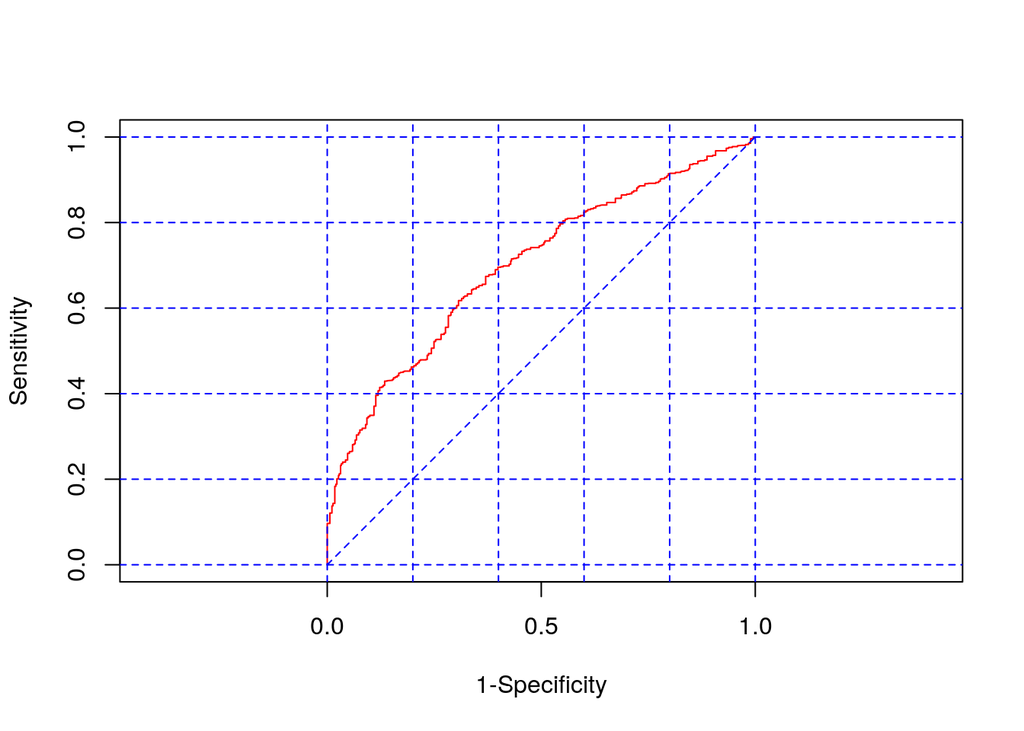

```r
roc$auc
```

```
## [1] 0.6991624
```

```r
train_control <- trainControl(method="none")
model = train(ACT ~ ., data = temp, trControl=train_control, method="glmStepAIC", family = "binomial")
```

```
## Start:  AIC=3270.46
## .outcome ~ `rs8109627T/C` + `rs8109627C/C` + `rs8179181G/A` +
##     `rs8179181A/A` + `rs4803455C/A` + `rs4803455A/A` + `rs1800469G/A` +
##     `rs1800469A/A` + `rs10495098G/T` + `rs10495098T/T` + `rs17047703C/A` +
##     `rs17047703A/A` + `rs17558745C/T` + `rs17558745T/T` + `rs2799085C/A` +
##     `rs2799085A/A` + `rs2009112C/T` + `rs2009112T/T` + `rs10482751C/T` +
##     `rs10482751T/T` + `rs2027567A/G` + `rs2027567G/G` + `rs10779329T/C` +
##     `rs10779329C/C` + `rs2796821C/T` + `rs2796821T/T` + `rs2796822A/G` +
##     `rs2796822G/G` + `rs2798631A/G` + `rs2798631G/G` + `rs10863399A/C` +
##     `rs10863399C/C` + `rs4903359A/G` + `rs4903359G/G` + `rs3917187C/T` +
##     `rs3917187T/T` + `rs2284792A/G` + `rs2284792G/G` + `rs2268626T/C` +
##     `rs2268626C/C`
##
##                   Df Deviance    AIC
## - `rs3917187T/T`   1   3188.5 3268.5
## - `rs2284792A/G`   1   3188.5 3268.5
## - `rs2268626C/C`   1   3188.5 3268.5
## - `rs4803455A/A`   1   3188.9 3268.9
## - `rs2009112T/T`   1   3189.0 3269.0
## - `rs10779329T/C`  1   3189.0 3269.0
## - `rs2798631G/G`   1   3189.3 3269.3
## - `rs1800469G/A`   1   3189.8 3269.8
## - `rs10495098T/T`  1   3190.0 3270.0
## - `rs8179181A/A`   1   3190.2 3270.2
## - `rs2027567G/G`   1   3190.2 3270.2
## - `rs10779329C/C`  1   3190.3 3270.3
## - `rs17558745C/T`  1   3190.4 3270.4
## <none>                 3188.5 3270.5
## - `rs2009112C/T`   1   3190.5 3270.5
## - `rs2796822G/G`   1   3190.7 3270.7
## - `rs10482751C/T`  1   3191.0 3271.0
## - `rs2798631A/G`   1   3191.3 3271.3
## - `rs2799085C/A`   1   3191.4 3271.4
## - `rs8109627C/C`   1   3191.8 3271.8
## - `rs2796821C/T`   1   3192.0 3272.0
## - `rs10482751T/T`  1   3192.8 3272.8
## - `rs2796821T/T`   1   3193.2 3273.2
## - `rs3917187C/T`   1   3193.6 3273.6
## - `rs2027567A/G`   1   3193.6 3273.6
## - `rs4903359A/G`   1   3193.9 3273.9
```

[output cut: 570 more lines]

```
## - `rs10482751T/T`  1   3203.4 3259.4
## - `rs17558745T/T`  1   3204.3 3260.3
## - `rs2796822A/G`   1   3204.9 3260.9
## - `rs4803455C/A`   1   3205.8 3261.8
## - `rs4903359G/G`   1   3206.8 3262.8
## - `rs1800469A/A`   1   3207.3 3263.3
## - `rs8179181G/A`   1   3209.5 3265.5
## - `rs10495098G/T`  1   3209.7 3265.7
## - `rs2268626T/C`   1   3211.5 3267.5
## - `rs17047703A/A`  1   3211.5 3267.5
## - `rs2284792G/G`   1   3213.2 3269.2
## - `rs2799085A/A`   1   3216.3 3272.3
## - `rs10863399A/C`  1   3216.4 3272.4
## - `rs8109627T/C`   1   3217.4 3273.4
## - `rs17047703C/A`  1   3235.9 3291.9
```

```r
logistic.display(model$finalModel)
```

```
##
##                           OR     lower95ci     upper95ci     Pr(>|Z|)
## `rs8109627T/C`  1.513604e+00  1.265992e+00  1.809644e+00 5.422852e-06
## `rs8109627C/C`  7.063824e-01  4.673146e-01  1.067752e+00 9.915273e-02
## `rs8179181G/A`  7.202971e-01  6.011040e-01  8.631250e-01 3.782734e-04
## `rs4803455C/A`  7.685867e-01  6.471997e-01  9.127409e-01 2.691024e-03
## `rs1800469A/A`  4.073782e-07 8.963199e-273 1.851538e+259 9.623984e-01
## `rs10495098G/T` 7.222855e-01  6.046273e-01  8.628396e-01 3.356170e-04
## `rs17047703C/A` 2.002854e+00  1.608963e+00  2.493173e+00 5.079378e-10
## `rs17047703A/A` 2.909964e+00  1.674542e+00  5.056839e+00 1.515714e-04
## `rs17558745C/T` 1.193866e+00  9.628469e-01  1.480315e+00 1.063296e-01
## `rs17558745T/T` 5.571841e-01  3.640768e-01  8.527160e-01 7.063818e-03
## `rs2799085C/A`  8.066326e-01  6.490119e-01  1.002533e+00 5.272650e-02
## `rs2799085A/A`  1.999269e+00  1.468183e+00  2.722465e+00 1.093877e-05
## `rs10482751C/T` 8.068370e-01  6.385579e-01  1.019463e+00 7.210557e-02
## `rs10482751T/T` 5.997671e-01  4.050511e-01  8.880869e-01 1.069275e-02
## `rs2027567A/G`  1.292823e+00  1.024885e+00  1.630808e+00 3.020440e-02
## `rs2027567G/G`  1.409357e+00  9.264902e-01  2.143883e+00 1.088850e-01
## `rs2796821C/T`  8.092834e-01  6.431793e-01  1.018285e+00 7.101641e-02
## `rs2796821T/T`  2.260453e+00  1.110027e+00  4.603176e+00 2.459923e-02
## `rs2796822A/G`  7.055823e-01  5.553684e-01  8.964254e-01 4.301498e-03
## `rs2796822G/G`  7.425594e-01  5.514206e-01  9.999525e-01 4.996342e-02
## `rs2798631A/G`  7.593595e-01  6.092828e-01  9.464028e-01 1.427370e-02
## `rs10863399A/C` 1.686839e+00  1.337164e+00  2.127955e+00 1.027281e-05
## `rs10863399C/C` 3.993965e-01  1.879373e-01  8.487806e-01 1.702173e-02
## `rs4903359A/G`  7.754525e-01  6.291213e-01  9.558198e-01 1.715071e-02
## `rs4903359G/G`  2.037491e+00  1.308426e+00  3.172796e+00 1.634885e-03
## `rs3917187C/T`  1.327101e+00  1.064564e+00  1.654382e+00 1.186052e-02
## `rs2284792G/G`  2.340133e+00  1.551572e+00  3.529466e+00 5.012419e-05
## `rs2268626T/C`  1.486477e+00  1.213506e+00  1.820850e+00 1.285052e-04
```

```r
confusionMatrix(predict(model, newdata = temp), reference = temp$ACT, positive = "1_OK")
```

```
## Confusion Matrix and Statistics
##
##           Reference
## Prediction 0_Not 1_OK
##      0_Not  1430  621
##      1_OK    210  404
##
##                Accuracy : 0.6882
##                  95% CI : (0.6702, 0.7057)
##     No Information Rate : 0.6154
##     P-Value [Acc > NIR] : 2.815e-15
##
##                   Kappa : 0.2877
##
##  Mcnemar's Test P-Value : < 2.2e-16
##
##             Sensitivity : 0.3941
##             Specificity : 0.8720
##          Pos Pred Value : 0.6580
##          Neg Pred Value : 0.6972
##              Prevalence : 0.3846
##          Detection Rate : 0.1516
##    Detection Prevalence : 0.2304
##       Balanced Accuracy : 0.6330
##
##        'Positive' Class : 1_OK
##
```

```r
temp = cbind(ACT, carriers)
temp$ACT = as.factor(ifelse(temp$ACT >= 20, "1_OK", "0_Not"))
temp = temp[complete.cases(temp),]
for(i in 1:ncol(temp)) { temp[,i] = as.factor(temp[,i])}
temp = DMwR::SMOTE(ACT ~ ., temp, perc.over = 400)

glm3 <- glm(ACT~.,
            family=binomial, data=temp)
summary(glm3)
```

```
##
## Call:
## glm(formula = ACT ~ ., family = binomial, data = temp)
##
## Deviance Residuals:
##     Min       1Q   Median       3Q      Max
## -1.4151  -0.9738  -0.8079   1.2293   2.0222
##
## Coefficients:
##                     Estimate Std. Error z value Pr(>|z|)
## (Intercept)         -0.02986    0.18869  -0.158  0.87425
## rs8109627_MAC1 Yes   0.36203    0.08590   4.214 2.50e-05 ***
## rs8179181_MAC1 Yes  -0.03052    0.08687  -0.351  0.72534
## rs4803455_MAC1 Yes  -0.16224    0.09703  -1.672  0.09450 .
## rs1800469_MAC1 Yes   0.04449    0.08712   0.511  0.60958
## rs10495098_MAC1 Yes -0.19721    0.09777  -2.017  0.04368 *
## rs17047703_MAC1 Yes  0.31223    0.11077   2.819  0.00482 **
## rs17558745_MAC1 Yes  0.24895    0.10424   2.388  0.01693 *
## rs2799085_MAC1 Yes  -0.27699    0.10181  -2.721  0.00652 **
## rs2009112_MAC1 Yes  -0.27293    0.09781  -2.790  0.00526 **
## rs10482751_MAC1 Yes  0.02319    0.10770   0.215  0.82954
## rs2027567_MAC1 Yes   0.11263    0.10482   1.075  0.28260
## rs10779329_MAC1 Yes -0.19436    0.09678  -2.008  0.04460 *
## rs2796821_MAC1 Yes   0.05053    0.10941   0.462  0.64418
## rs2796822_MAC1 Yes  -0.68242    0.11720  -5.823 5.78e-09 ***
## rs2798631_MAC1 Yes   0.06410    0.11140   0.575  0.56500
## rs10863399_MAC1 Yes  0.14023    0.11291   1.242  0.21424
## rs4903359_MAC1 Yes  -0.28998    0.10011  -2.896  0.00377 **
## rs3917187_MAC1 Yes   0.49186    0.11586   4.245 2.18e-05 ***
## rs2284792_MAC1 Yes  -0.09815    0.11484  -0.855  0.39275
## rs2268626_MAC1 Yes   0.20907    0.10452   2.000  0.04546 *
## ---
## Signif. codes:  0 '***' 0.001 '**' 0.01 '*' 0.05 '.' 0.1 ' ' 1
##
## (Dispersion parameter for binomial family taken to be 1)
##
##     Null deviance: 3551.3  on 2664  degrees of freedom
## Residual deviance: 3403.8  on 2644  degrees of freedom
## AIC: 3445.8
##
## Number of Fisher Scoring iterations: 4
```

```r
#print(logistic.display(glm3))
roc = lroc(glm3)
```

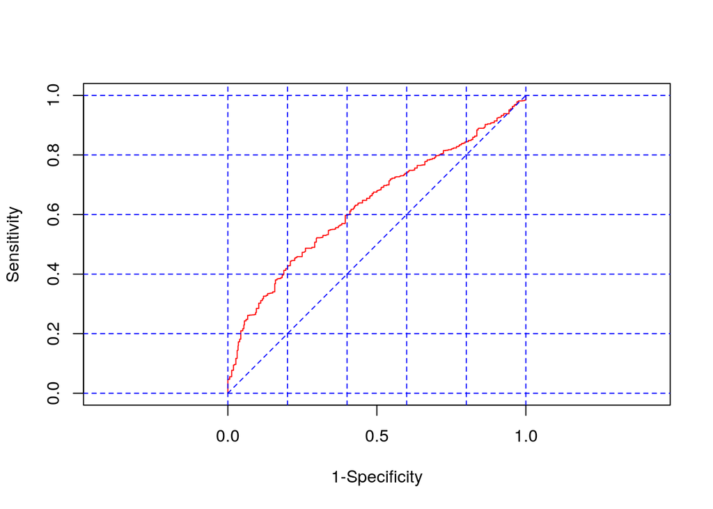

```r
roc$auc
```

```
## [1] 0.6335062
```

```r
glm4 = step(glm3)
```

```
## Start:  AIC=3445.79
## ACT ~ rs8109627_MAC + rs8179181_MAC + rs4803455_MAC + rs1800469_MAC +
##     rs10495098_MAC + rs17047703_MAC + rs17558745_MAC + rs2799085_MAC +
##     rs2009112_MAC + rs10482751_MAC + rs2027567_MAC + rs10779329_MAC +
##     rs2796821_MAC + rs2796822_MAC + rs2798631_MAC + rs10863399_MAC +
##     rs4903359_MAC + rs3917187_MAC + rs2284792_MAC + rs2268626_MAC
##
##                  Df Deviance    AIC
## - rs10482751_MAC  1   3403.8 3443.8
## - rs8179181_MAC   1   3403.9 3443.9
## - rs2796821_MAC   1   3404.0 3444.0
## - rs1800469_MAC   1   3404.0 3444.0
## - rs2798631_MAC   1   3404.1 3444.1
## - rs2284792_MAC   1   3404.5 3444.5
## - rs2027567_MAC   1   3404.9 3444.9
## - rs10863399_MAC  1   3405.3 3445.3
## <none>                3403.8 3445.8
## - rs4803455_MAC   1   3406.6 3446.6
## - rs2268626_MAC   1   3407.8 3447.8
## - rs10779329_MAC  1   3407.8 3447.8
## - rs10495098_MAC  1   3407.9 3447.9
## - rs17558745_MAC  1   3409.5 3449.5
## - rs2799085_MAC   1   3411.2 3451.2
## - rs2009112_MAC   1   3411.6 3451.6
## - rs17047703_MAC  1   3411.7 3451.7
## - rs4903359_MAC   1   3412.2 3452.2
## - rs8109627_MAC   1   3421.6 3461.6
## - rs3917187_MAC   1   3422.0 3462.0
## - rs2796822_MAC   1   3438.1 3478.1
##
## Step:  AIC=3443.83
## ACT ~ rs8109627_MAC + rs8179181_MAC + rs4803455_MAC + rs1800469_MAC +
##     rs10495098_MAC + rs17047703_MAC + rs17558745_MAC + rs2799085_MAC +
##     rs2009112_MAC + rs2027567_MAC + rs10779329_MAC + rs2796821_MAC +
##     rs2796822_MAC + rs2798631_MAC + rs10863399_MAC + rs4903359_MAC +
##     rs3917187_MAC + rs2284792_MAC + rs2268626_MAC
##
##                  Df Deviance    AIC
## - rs8179181_MAC   1   3404.0 3442.0
## - rs2796821_MAC   1   3404.0 3442.0
```

[output cut: 152 more lines]

```
##                  Df Deviance    AIC
## <none>                3407.2 3435.2
## - rs2268626_MAC   1   3410.5 3436.5
## - rs10779329_MAC  1   3410.7 3436.7
## - rs10863399_MAC  1   3410.8 3436.8
## - rs4803455_MAC   1   3411.4 3437.4
## - rs10495098_MAC  1   3411.7 3437.7
## - rs17558745_MAC  1   3412.7 3438.7
## - rs2799085_MAC   1   3412.9 3438.9
## - rs17047703_MAC  1   3415.2 3441.2
## - rs2009112_MAC   1   3416.3 3442.3
## - rs4903359_MAC   1   3417.2 3443.2
## - rs3917187_MAC   1   3425.2 3451.2
## - rs8109627_MAC   1   3426.2 3452.2
## - rs2796822_MAC   1   3446.5 3472.5
```

```r
summary(glm4)
```

```
##
## Call:
## glm(formula = ACT ~ rs8109627_MAC + rs4803455_MAC + rs10495098_MAC +
##     rs17047703_MAC + rs17558745_MAC + rs2799085_MAC + rs2009112_MAC +
##     rs10779329_MAC + rs2796822_MAC + rs10863399_MAC + rs4903359_MAC +
##     rs3917187_MAC + rs2268626_MAC, family = binomial, data = temp)
##
## Deviance Residuals:
##     Min       1Q   Median       3Q      Max
## -1.4470  -0.9756  -0.8013   1.2379   2.0474
##
## Coefficients:
##                     Estimate Std. Error z value Pr(>|z|)
## (Intercept)          0.06000    0.16316   0.368  0.71306
## rs8109627_MAC1 Yes   0.36584    0.08390   4.360 1.30e-05 ***
## rs4803455_MAC1 Yes  -0.18723    0.09100  -2.058  0.03964 *
## rs10495098_MAC1 Yes -0.20619    0.09683  -2.129  0.03323 *
## rs17047703_MAC1 Yes  0.31215    0.11033   2.829  0.00467 **
## rs17558745_MAC1 Yes  0.24309    0.10318   2.356  0.01847 *
## rs2799085_MAC1 Yes  -0.21669    0.09048  -2.395  0.01662 *
## rs2009112_MAC1 Yes  -0.29072    0.09628  -3.019  0.00253 **
## rs10779329_MAC1 Yes -0.17763    0.09448  -1.880  0.06010 .
## rs2796822_MAC1 Yes  -0.63713    0.10217  -6.236 4.49e-10 ***
## rs10863399_MAC1 Yes  0.18640    0.09822   1.898  0.05772 .
## rs4903359_MAC1 Yes  -0.30920    0.09831  -3.145  0.00166 **
## rs3917187_MAC1 Yes   0.44602    0.10529   4.236 2.27e-05 ***
## rs2268626_MAC1 Yes   0.18089    0.09895   1.828  0.06754 .
## ---
## Signif. codes:  0 '***' 0.001 '**' 0.01 '*' 0.05 '.' 0.1 ' ' 1
##
## (Dispersion parameter for binomial family taken to be 1)
##
##     Null deviance: 3551.3  on 2664  degrees of freedom
## Residual deviance: 3407.2  on 2651  degrees of freedom
## AIC: 3435.2
##
## Number of Fisher Scoring iterations: 4
```

```r
#print(logistic.display(glm4))
roc = lroc(glm4)
```

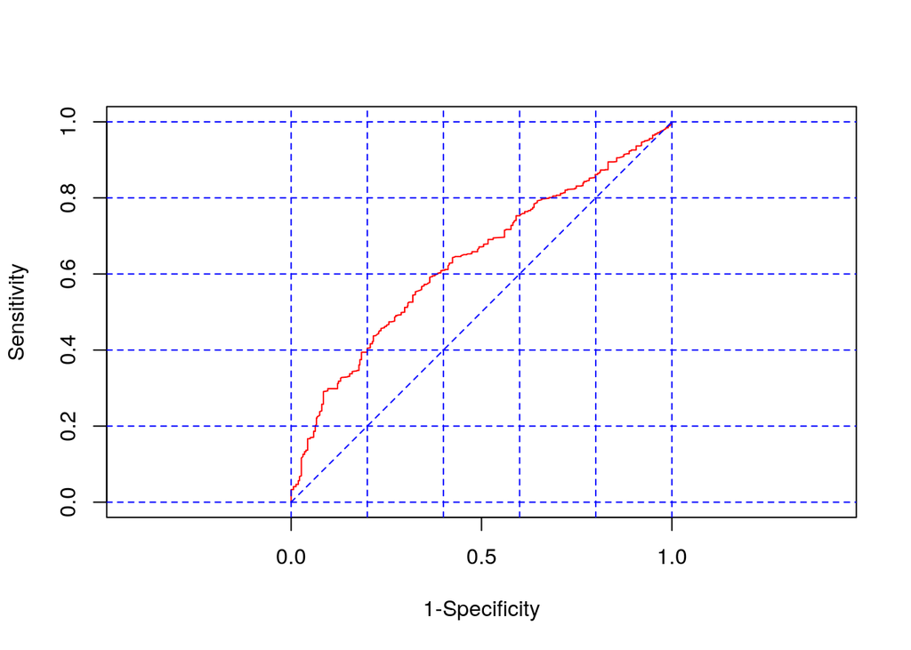

```r
roc$auc
```

```
## [1] 0.6351698
```

```r
train_control <- trainControl(method="none")
model = train(ACT ~ ., data = temp, trControl=train_control, method="glmStepAIC", family = "binomial")
```

```
## Start:  AIC=3445.79
## .outcome ~ `rs8109627_MAC1 Yes` + `rs8179181_MAC1 Yes` + `rs4803455_MAC1 Yes` +
##     `rs1800469_MAC1 Yes` + `rs10495098_MAC1 Yes` + `rs17047703_MAC1 Yes` +
##     `rs17558745_MAC1 Yes` + `rs2799085_MAC1 Yes` + `rs2009112_MAC1 Yes` +
##     `rs10482751_MAC1 Yes` + `rs2027567_MAC1 Yes` + `rs10779329_MAC1 Yes` +
##     `rs2796821_MAC1 Yes` + `rs2796822_MAC1 Yes` + `rs2798631_MAC1 Yes` +
##     `rs10863399_MAC1 Yes` + `rs4903359_MAC1 Yes` + `rs3917187_MAC1 Yes` +
##     `rs2284792_MAC1 Yes` + `rs2268626_MAC1 Yes`
##
##                         Df Deviance    AIC
## - `rs10482751_MAC1 Yes`  1   3403.8 3443.8
## - `rs8179181_MAC1 Yes`   1   3403.9 3443.9
## - `rs2796821_MAC1 Yes`   1   3404.0 3444.0
## - `rs1800469_MAC1 Yes`   1   3404.0 3444.0
## - `rs2798631_MAC1 Yes`   1   3404.1 3444.1
## - `rs2284792_MAC1 Yes`   1   3404.5 3444.5
## - `rs2027567_MAC1 Yes`   1   3404.9 3444.9
## - `rs10863399_MAC1 Yes`  1   3405.3 3445.3
## <none>                       3403.8 3445.8
## - `rs4803455_MAC1 Yes`   1   3406.6 3446.6
## - `rs2268626_MAC1 Yes`   1   3407.8 3447.8
## - `rs10779329_MAC1 Yes`  1   3407.8 3447.8
## - `rs10495098_MAC1 Yes`  1   3407.9 3447.9
## - `rs17558745_MAC1 Yes`  1   3409.5 3449.5
## - `rs2799085_MAC1 Yes`   1   3411.2 3451.2
## - `rs2009112_MAC1 Yes`   1   3411.6 3451.6
## - `rs17047703_MAC1 Yes`  1   3411.7 3451.7
## - `rs4903359_MAC1 Yes`   1   3412.2 3452.2
## - `rs8109627_MAC1 Yes`   1   3421.6 3461.6
## - `rs3917187_MAC1 Yes`   1   3422.0 3462.0
## - `rs2796822_MAC1 Yes`   1   3438.1 3478.1
##
## Step:  AIC=3443.83
## .outcome ~ `rs8109627_MAC1 Yes` + `rs8179181_MAC1 Yes` + `rs4803455_MAC1 Yes` +
##     `rs1800469_MAC1 Yes` + `rs10495098_MAC1 Yes` + `rs17047703_MAC1 Yes` +
##     `rs17558745_MAC1 Yes` + `rs2799085_MAC1 Yes` + `rs2009112_MAC1 Yes` +
##     `rs2027567_MAC1 Yes` + `rs10779329_MAC1 Yes` + `rs2796821_MAC1 Yes` +
##     `rs2796822_MAC1 Yes` + `rs2798631_MAC1 Yes` + `rs10863399_MAC1 Yes` +
##     `rs4903359_MAC1 Yes` + `rs3917187_MAC1 Yes` + `rs2284792_MAC1 Yes` +
##     `rs2268626_MAC1 Yes`
```

[output cut: 163 more lines]

```
##                         Df Deviance    AIC
## <none>                       3407.2 3435.2
## - `rs2268626_MAC1 Yes`   1   3410.5 3436.5
## - `rs10779329_MAC1 Yes`  1   3410.7 3436.7
## - `rs10863399_MAC1 Yes`  1   3410.8 3436.8
## - `rs4803455_MAC1 Yes`   1   3411.4 3437.4
## - `rs10495098_MAC1 Yes`  1   3411.7 3437.7
## - `rs17558745_MAC1 Yes`  1   3412.7 3438.7
## - `rs2799085_MAC1 Yes`   1   3412.9 3438.9
## - `rs17047703_MAC1 Yes`  1   3415.2 3441.2
## - `rs2009112_MAC1 Yes`   1   3416.3 3442.3
## - `rs4903359_MAC1 Yes`   1   3417.2 3443.2
## - `rs3917187_MAC1 Yes`   1   3425.2 3451.2
## - `rs8109627_MAC1 Yes`   1   3426.2 3452.2
## - `rs2796822_MAC1 Yes`   1   3446.5 3472.5
```

```r
logistic.display(model$finalModel)
```

```
##
##                              OR lower95ci upper95ci     Pr(>|Z|)
## `rs8109627_MAC1 Yes`  1.4417186 1.2231088 1.6994011 1.298223e-05
## `rs4803455_MAC1 Yes`  0.8292514 0.6937903 0.9911610 3.963532e-02
## `rs10495098_MAC1 Yes` 0.8136797 0.6730214 0.9837350 3.322828e-02
## `rs17047703_MAC1 Yes` 1.3663579 1.1006605 1.6961941 4.665174e-03
## `rs17558745_MAC1 Yes` 1.2751835 1.0417148 1.5609772 1.846971e-02
## `rs2799085_MAC1 Yes`  0.8051818 0.6743424 0.9614072 1.662195e-02
## `rs2009112_MAC1 Yes`  0.7477236 0.6191337 0.9030208 2.532450e-03
## `rs10779329_MAC1 Yes` 0.8372524 0.6957211 1.0075757 6.009673e-02
## `rs2796822_MAC1 Yes`  0.5288069 0.4328399 0.6460511 4.494247e-10
## `rs10863399_MAC1 Yes` 1.2049085 0.9939124 1.4606966 5.772301e-02
## `rs4903359_MAC1 Yes`  0.7340346 0.6053880 0.8900188 1.660274e-03
## `rs3917187_MAC1 Yes`  1.5620864 1.2708085 1.9201272 2.274953e-05
## `rs2268626_MAC1 Yes`  1.1982883 0.9870313 1.4547612 6.754206e-02
```

```r
confusionMatrix(predict(model, newdata = temp), reference = temp$ACT, positive = "1_OK")
```

```
## Confusion Matrix and Statistics
##
##           Reference
## Prediction 0_Not 1_OK
##      0_Not  1501  750
##      1_OK    139  275
##
##                Accuracy : 0.6664
##                  95% CI : (0.6482, 0.6843)
##     No Information Rate : 0.6154
##     P-Value [Acc > NIR] : 2.603e-08
##
##                   Kappa : 0.2066
##
##  Mcnemar's Test P-Value : < 2.2e-16
##
##             Sensitivity : 0.2683
##             Specificity : 0.9152
##          Pos Pred Value : 0.6643
##          Neg Pred Value : 0.6668
##              Prevalence : 0.3846
##          Detection Rate : 0.1032
##    Detection Prevalence : 0.1553
##       Balanced Accuracy : 0.5918
##
##        'Positive' Class : 1_OK
##
```

# 11 Meta

```r
# meta = ifelse(doeksportu$clinical_ill == "Healthy","Healthy",ifelse(doeksportu$astma1 == "Nieciężka","Mild Asthma","Severe Asthma"))
# backup = doeksportu
#
# doeksportu$FEV1 = clinical$FEV1...........wn
# doeksportu$FVC = clinical$FVC................wn
# doeksportu$FEV1doFVC = clinical$FEV1.FVC..............wn
# doeksportu$TestKontroli = clinical$Test.kontroli.astmy..ATC..wynik.surowy.w.pkt
# doeksportu$LiczbaZaost = ifelse(clinical$Występowanie.licznych..2.i.więcej.w.ciągu.roku..ciężkich.zaostrzeń.astmy.mimo.stosowana.wysokich.dawek.wGKS.plus.LABA.................nie...0...........tak...1. == 1, "1 Tak", "0 Nie")
# doeksportu$LiczbaPaczkolat = clinical$Liczba.paczkolat...Paczkolata...liczba.paczek.papierosów.dziennie.x.lata.palenia...0...nie.pali
#
#
# metadb = dplyr::select(doeksportu, -clinical_ill, -astma1, -astma2, -astma3, -astma4)
# write.csv(metadb, "metadb.csv")
# glm3 <- glm(meta~.,
#             family=binomial, data=metadb)
# print(logistic.display(glm3))
# lroc(glm3)
#
# glm4 = step(glm3)
# print(logistic.display(glm4))
# lroc(glm4)
#
# write.csv(metadb, "metadb.csv")
```

# 12 Testy

# 13 Footer

By Konrad Stawiski (konrad@konsta.com.pl).